# Solar Energy Adoption Analysis in Melbourne for ARENA

- **Prepared by:** Lai Kuen Tsang, Applied Data Analysis Skill Set Course at TAFE
- **Date:** 10th June, 2026
- **Confidentiality:** Internal (Assignment#4 - Final Project)

## Executive Summary

This analysis investigates the key factors influencing solar energy adoption across Melbourne and broader Victorian postcode areas using a combined postcode-year dataset covering 2014 to 2024. The study integrates multiple data sources, including solar market data, ABS dwelling structure Census data from 2011, 2016 and 2021, and ten years of Victorian Government house sales data. At the time of this analysis, 2026 Census dwelling-structure data was not yet available; therefore, the 2021 Census was used as the latest official Census benchmark. ABS dwelling structure data from 2011, 2016 and 2021 was interpolated across the ten-year period to estimate annual dwelling composition at postcode level.

The analysis found that dwelling structure and urban form are the strongest drivers of solar adoption. Detached house proportion has a strong positive relationship with solar adoption, while apartment and townhouse proportions show strong negative relationships. This suggests that physical suitability for rooftop solar, particularly individual roof ownership, available roof space and lower-density housing, is a major determinant of adoption.

Distance from Melbourne CBD is also strongly associated with solar adoption. Outer metropolitan suburbs generally show higher adoption than inner-city areas, likely due to higher detached dwelling proportions and lower apartment density. The correlation heatmaps, scatter plots, pairplots and GeoPandas maps consistently support this spatial pattern. However, when all postcodes are included, the distance relationship becomes weaker, suggesting that rural, regional, industrial and special-use postcodes behave differently from metropolitan residential markets.

House median price shows a significant negative relationship with solar adoption. This does not necessarily mean higher prices directly reduce adoption. The result is likely influenced by expensive inner-city areas where apartment concentration is high and rooftop solar access is structurally limited. Therefore, house price should be interpreted together with dwelling type, housing density and distance from CBD, rather than as a standalone driver.

The analysis also found that high property count is strongly associated with total solar installations, but not higher adoption rates. Larger suburbs naturally have more installations because they contain more dwellings, but they do not necessarily have higher adoption intensity. This means total suburb size alone should not be used as a targeting criterion. Adoption rate and adoption gap are more useful indicators for identifying underperforming areas.

The key recommendation is that ARENA and policy stakeholders should prioritise solar adoption programs based on dwelling structure, location type, postcode segment and adoption gap rather than raw property count or property price alone. Detached-house suburbs with low adoption may require financial or awareness-based incentives, while inner-city apartment-heavy areas require structural solutions such as shared solar, embedded networks, strata and body-corporate support, and community battery models.

## Introduction

### Objective

The objective of this project is to investigate the factors that influence solar energy adoption across Melbourne and broader postcode areas from 2014 to 2024. The analysis focuses on understanding how dwelling structure, house prices, distance from Melbourne CBD and property count contribute to variation in solar adoption rates.

The main business question is:

**What factors influence solar energy adoption in Melbourne, and how can these insights support more targeted solar policy and investment decisions?**

The project evaluates the following key themes:

- Whether detached-house suburbs have higher solar adoption.
- Whether apartment-heavy suburbs have lower solar adoption.
- Whether house prices are positively or negatively associated with solar adoption.
- Whether distance from Melbourne CBD is associated with solar adoption.
- Whether high property-count suburbs have higher adoption rates or simply higher total installations.
- Whether different postcode-level solar market segments can be identified using clustering analysis.

### Approach

The project combines multiple datasets at postcode-year level. Solar adoption data was joined with ABS dwelling structure data and Victorian house sales data. The final dataset was analysed using descriptive statistics, exploratory data analysis, hypothesis and significance testing, correlation analysis, regression-style interpretation, KMeans clustering and GeoPandas mapping.

Two main datasets were used:

- Metro dataset (df_metro)

> This dataset includes postcode records within 60km of Melbourne CBD and contains 258 postcodes. It was used for the main Melbourne metro adoption analysis.
- Full postcode dataset (df_mel_filled)

> This dataset includes all available postcodes and contains 353 postcodes. It was used for broader comparison, sensitivity testing and all-postcode distance/property-count analysis.

A third dataset was created for house-price testing:

- Metro price dataset (df_metro_price)

> This dataset contains 234 metro postcodes with available house median price data. It was used specifically for the house price hypothesis because some postcode-years had no sales data and therefore no valid house median price.

## Methodology

### Data Sources

The analysis combines the following data sources:

1. Solar adoption data from https://cer.gov.au/markets/reports-and-data/small-scale-installation-postcode-data

> Solar adoption was measured using solar installation count, solar capacity in kW, solar adoption rate and solar kW per property.
2. ABS dwelling structure Census data from: https://www.abs.gov.au/census/find-census-data/datapacks

> Dwelling structure data from the 2011, 2016 and 2021 Census was used to estimate postcode-level dwelling composition. The main dwelling structure variables were detached houses, apartments, townhouses and vacant properties. Because Census data is only available at five-year intervals, interpolation was used to estimate annual dwelling structure values across the 2014–2024 analysis period.
3. Victorian Government house sales data from: https://www.land.vic.gov.au/valuations/resources-and-reports/property-sales-statistics

> Ten years of house sales data was used to derive postcode-year house median price. Some postcode-years had no sales data, resulting in missing house price values. These missing values were not treated as zero. For house-price analysis, only metro postcodes with valid house price data were used.
4. Distance from Melbourne CBD from: https://www.matthewproctor.com/australian_postcodes#downloadlinks

> Each postcode was assigned a distance from Melbourne CBD in kilometres. This enabled analysis of spatial patterns across inner, middle and outer zones.

### Key Derived Metrics

- Solar Adoption Rate

> solar_adoption_rate = solar_unit / total_property_count
- Solar kW per property

> solar_kW_per_property = solar_kW / total_property_count
- Average system size

> avg_system_size_kW = solar_kW / solar_unit
- Log total property count

> Used to reduce skewness in property-count modelling.
- Log house median price

> Used to reduce skewness in house price modelling.

### Dataset Design

Three datasets were used for different parts of the analysis:

1. df_metro

> 258 postcodes | Purpose: Main metro analysis for Hypotheses H1, H2, H4 and H6
2. df_metro_price

> 234 postcodes | Purpose: House price analysis for Hypothesis H3
3. df_mel_filled

> 353 postcodes | Purpose: Full postcode analysis for Hypotheses H5 and H7

The metro dataset was restricted to postcodes within 60km of Melbourne CBD. This boundary was selected to focus on the metropolitan residential solar market and reduce distortion from rural, farming, industrial and special-use postcodes.

### Handling Missing House Price Data

House median price had missing values where there were no sales records for the same postcode-year. These missing values were not replaced with zero because zero would not represent a valid house price.

Instead, the house price hypothesis was tested using df_metro_price, which contains only metro postcodes with available house price data. This avoids introducing artificial price values while still allowing the relationship between house prices and solar adoption to be tested.

The missing house price issue was also considered in interpretation. Missing price data is more common in rural, low-sales and special-use postcodes, which is one reason the main house price analysis was limited to the metro price dataset.

## Analytical Tools and Techniques

The analysis was conducted using Python-based data science tools and statistical techniques.

### Tools

The main tools used were:

- Pandas for data cleaning, merging, aggregation and transformation.
- NumPy for numerical calculations and log transformations.
- SciPy for Pearson and Spearman correlation testing.
- Statsmodels for regression-style hypothesis testing and statistical summaries.
- Matplotlib and Seaborn for visualisation, including scatter plots, pairplots and heatmaps.
- Scikit-learn for KMeans clustering and feature standardisation.
- GeoPandas for postcode-level spatial data processing and mapping.
- Folium for interactive postcode maps with zoom, pan and tooltips.

### Techniques

The following analytical techniques were applied:

1. **Descriptive Overview**

> Summary statistics were produced for solar adoption, dwelling structure, property count, house price and distance from CBD.
2. **Exploratory Data Analysis**

> Correlation heatmaps, scatter plots and pairplots were used to understand relationships between solar adoption and potential explanatory variables.
3. **Hypothesis and Significance Testing**

> Pearson correlation, Spearman correlation and t-tests were used to test whether relationships between key variables and solar adoption were statistically significant.
4. **Distance-zone Analysis**

> Postcodes were grouped into inner, middle and outer zones to compare how relationships differ by distance from Melbourne CBD.
5. **KMeans Clustering Analysis**

> KMeans clustering was used to identify postcode-level solar market segments. Features were standardised before clustering because KMeans is distance-based and variables have different scales.
6. **GeoPandas Mapping**

> Postcode-level maps were used to visualise spatial patterns in solar adoption, adoption growth, dwelling structure and KMeans clusters.

## Data Collation and Preparation

```python
import pandas as pd
import numpy as np
```

#### Solar Dataset

```python
#Read solar unit file as df_solar_unit
df_solar_unit = pd.read_csv(r'/Users/polly/Downloads/Assignment 4/data/sgu-solar-installations-2011-to-present-and-totals.csv')

#remove unwanted columns
df_solar_unit = df_solar_unit.drop(columns=['Historic Total Installation Quantity (2001 - 2010)','Total Installation Quantity'])

#remove space
df_solar_unit.columns = df_solar_unit.columns.str.strip()

#rename the primary key
df_solar_unit.rename(columns={'Small Unit Installation Postcode':'postcode'}, inplace = True)

#set postcode as string and standardlize it
df_solar_unit['postcode'] = df_solar_unit['postcode'].astype('string')
df_solar_unit['postcode'] = df_solar_unit['postcode'].str.zfill(4)

#unpivot the table
df_solar_unit = pd.melt(df_solar_unit,id_vars='postcode',var_name ='date',value_name='solar_unit')

# Remove " - Installation Quantity"
df_solar_unit['date'] = df_solar_unit['date'].str.strip().str.replace('- Installation Quantity','',regex = False)

#remove space and empty data
df_solar_unit['date'] = df_solar_unit['date'].astype(str).str.strip()

#remove empty date data
df_solar_unit = df_solar_unit[df_solar_unit['date'] != '']

#set Datetime format
df_solar_unit['date'] = pd.to_datetime(df_solar_unit['date'],format = '%b %Y')

#only keep melbourne postcode
df_solar_unit = df_solar_unit[pd.to_numeric(df_solar_unit['postcode'], errors='coerce').between(3000, 3999)].reset_index(drop=True)

#Read solar capacity file as df_solar_kw
df_solar_kw = pd.read_csv(r'/Users/polly/Downloads/Assignment 4/data/sgu-solar-capacity-2011-to-present-and-totals.csv')

#remove unwanted columns
df_solar_kw = df_solar_kw.drop(columns=['Historic Total Rated Power Output In kW (2001 - 2010)','Total Rated Power Output In kW'])

#remove space
df_solar_kw.columns = df_solar_kw.columns.str.strip()

#rename the primary key
df_solar_kw.rename(columns={'Small Unit Postcode':'postcode'}, inplace = True)

#set postcode as string and standardlize it
df_solar_kw['postcode'] = df_solar_kw['postcode'].astype('string')
df_solar_kw['postcode'] = df_solar_kw['postcode'].str.zfill(4)

#unpivot the table
df_solar_kw = pd.melt(df_solar_kw,id_vars='postcode',var_name ='date',value_name='solar_kW')

# Remove " - Rated Power Output In kW"
df_solar_kw['date'] = df_solar_kw['date'].str.strip().str.replace(' - Rated Power Output In kW','',regex = False)

#remove space and empty data
df_solar_kw['date'] = df_solar_kw['date'].astype(str).str.strip()

#remove empty date data
df_solar_kw = df_solar_kw[df_solar_kw['date'] != '']

#set Datetime format
df_solar_kw['date'] = pd.to_datetime(df_solar_kw['date'],format = '%b %Y')

#convert capacity_kw datatype to float
df_solar_kw['solar_kW'] = (df_solar_kw['solar_kW'].astype(str).str.replace(',', '').str.strip())
df_solar_kw['solar_kW'] = pd.to_numeric(df_solar_kw['solar_kW'], errors='coerce')

df_solar_kw['solar_kW'] = df_solar_kw['solar_kW'].round(2)

#only keep melbourne postcode
df_solar_kw = df_solar_kw[pd.to_numeric(df_solar_kw['postcode'], errors='coerce').between(3000, 3999)].reset_index(drop=True)

# merge solar unit & capacity kW
df_solar = df_solar_kw.merge(
    df_solar_unit[['postcode', 'date', 'solar_unit']],
    on=['postcode', 'date'],
    how='left'
)
# Convert date to year
df_solar['year'] = df_solar['date'].dt.year

#Aggregate to yearly level
df_solar_yearly = (
    df_solar
    .groupby(['postcode', 'year'], as_index=False)
    .agg({
        'solar_kW': 'sum',
        'solar_unit': 'sum'
    })
)

#make sure aligh with all dataset year range from 2014-2024
df_solar_yearly = df_solar_yearly[df_solar_yearly['year'].between(2014, 2024)]
```

#### Dwell Structure Dataset

```python
#Read Census Dwell Structure dataset from 2011
df_dwell_2011 = pd.read_csv(r'/Users/polly/Downloads/Assignment 4/data/2011Census_B31_VIC_POA_short.csv')

#clean columns
df_dwell_2011.columns = df_dwell_2011.columns.str.strip()

# keep useful columns
df_dwell_2011 = df_dwell_2011[['region_id','OPDs_Separate_house_Dwellings','OPDs_Flt_unit_apart_Tot_Dwgs','OPDs_SD_r_t_h_th_Tot_Dwgs','Unoccupied_PDs_Dwgs','Total_PDs_Dwellings']]

#rename the dataset
df_dwell_2011.rename(
    columns = {'region_id': 'postcode',
            'OPDs_Separate_house_Dwellings': 'detached_property',
            'OPDs_SD_r_t_h_th_Tot_Dwgs': 'townhouse',
            'OPDs_Flt_unit_apart_Tot_Dwgs':'apartment',
            'Unoccupied_PDs_Dwgs':'vacant_property',
            'Total_PDs_Dwellings': 'total_property_count'
            }, inplace = True
)
#clean the postcode as 4 digits
df_dwell_2011['postcode'] = df_dwell_2011['postcode'].str.replace('POA','',regex = False).astype('string')

#add year 2011 to the column
df_dwell_2011['year'] = 2011

#Read Census Dwell Structure dataset from 2016
df_dwell_2016 = pd.read_csv(r'/Users/polly/Downloads/Assignment 4/data/2016Census_G32_VIC_POA.csv')

#clean columns
df_dwell_2016.columns = df_dwell_2016.columns.str.strip()

# keep useful columns
df_dwell_2016 = df_dwell_2016[['POA_CODE_2016','OPDs_Separate_house_Dwellings','OPDs_Flt_apart_Tot_Dwgs','OPDs_SD_r_t_h_th_Tot_Dwgs','Unoccupied_PDs_Dwgs','Total_PDs_Dwellings']]

#rename the dataset
df_dwell_2016.rename(
    columns = {'POA_CODE_2016': 'postcode',
            'OPDs_Separate_house_Dwellings': 'detached_property',
            'OPDs_SD_r_t_h_th_Tot_Dwgs': 'townhouse',
            'OPDs_Flt_apart_Tot_Dwgs':'apartment',
            'Unoccupied_PDs_Dwgs':'vacant_property',
            'Total_PDs_Dwellings': 'total_property_count'
            }, inplace = True
)

#clean the postcode as 4 digits
df_dwell_2016['postcode'] = df_dwell_2016['postcode'].str.replace('POA','',regex = False).astype('string')

#add year 2016 to the column
df_dwell_2016['year'] = 2016

#Read Census Dwell Structure dataset from 2021
df_dwell_2021 = pd.read_csv(r'/Users/polly/Downloads/Assignment 4/data/2021Census_G36_VIC_POA_dwelling structure.csv')

#clean columns
df_dwell_2021.columns = df_dwell_2021.columns.str.strip()

# keep useful columns
df_dwell_2021 = df_dwell_2021[['POA_CODE_2021','OPDs_Separate_house_Dwellings','OPDs_Flt_apart_Tot_Dwgs','OPDs_SD_r_t_h_th_Tot_Dwgs','Unoccupied_PDs_Dwgs','Total_PDs_Dwellings']]

#rename the dataset
df_dwell_2021.rename(
    columns = {'POA_CODE_2021': 'postcode',
            'OPDs_Separate_house_Dwellings': 'detached_property',
            'OPDs_SD_r_t_h_th_Tot_Dwgs': 'townhouse',
            'OPDs_Flt_apart_Tot_Dwgs':'apartment',
            'Unoccupied_PDs_Dwgs':'vacant_property',
            'Total_PDs_Dwellings': 'total_property_count'
            }, inplace = True
)

#clean the postcode as 4 digits
df_dwell_2021['postcode'] = df_dwell_2021['postcode'].str.replace('POA','',regex = False).astype('string')

#add year 2021 to the column
df_dwell_2021['year'] = 2021

#join 2011, 2016 & 2021 Dwelling dataset
df_dwell = pd.concat([df_dwell_2011,df_dwell_2016,df_dwell_2021], ignore_index=True)

# create a full dwell 2011-2024 dataset
years = range(2011, 2025)

full_index = pd.MultiIndex.from_product(
    [df_dwell['postcode'].unique(), years],
    names=['postcode', 'year']
)
df_dwell_full = df_dwell.set_index(['postcode', 'year']).reindex(full_index).reset_index()

# replace 0 with NaN for total_property_count
df_dwell_full = df_dwell_full.sort_values(['postcode', 'year'])

df_dwell_full['total_property_count'] = (
    df_dwell_full['total_property_count']
    .replace(0, np.nan)
)

#fill the NaN value use interpolation within each postcode group
cols = [
    'detached_property',
    'apartment',
    'townhouse',
    'vacant_property',
    'total_property_count'
]

df_dwell_full[cols] = (
    df_dwell_full.groupby('postcode')[cols]
    .transform(lambda s: s.interpolate())

)

#fill the edge gaps
df_dwell_full[cols] = (
    df_dwell_full.groupby('postcode')[cols]
    .transform(lambda s: s.ffill().bfill())
)
# calculate and add col the precentage of each type property of total
df_dwell_full["detached_pct"] = (df_dwell_full["detached_property"] / df_dwell_full["total_property_count"])
df_dwell_full["apartment_pct"] = (df_dwell_full["apartment"] / df_dwell_full["total_property_count"])
df_dwell_full["townhouse_pct"] = (df_dwell_full["townhouse"] / df_dwell_full["total_property_count"])
df_dwell_full["vacant_pct"] = (df_dwell_full["vacant_property"] / df_dwell_full["total_property_count"])

#convert back to dtype int64
df_dwell_full[['detached_property','apartment','townhouse','vacant_property']] = df_dwell_full[['detached_property','apartment','townhouse','vacant_property']].astype('int')

#make sure aligh with all dataset year range from 2014-2024
df_dwell_full = df_dwell_full[df_dwell_full['year'].between(2014, 2024)]

#make sure no duplicated combine key
df_dwell_full.duplicated(['postcode','year']).sum()
df_dwell_full.reset_index(drop=True)

# locate the reason for detached_pc.max
df_dwell_full.loc[
    df_dwell_full['detached_pct'] == df_dwell_full['detached_pct'].max(),
    [
        'postcode',
        'year',
        'detached_property',
        'apartment',
        'townhouse',
        'vacant_property',
        'total_property_count',
        'detached_pct'
    ]
]
# check invalid rows for total_property_count
invalid_rows = df_dwell_full[
    df_dwell_full['detached_property'] > df_dwell_full['total_property_count']
]
invalid_rows

#remove invalid rows
df_dwell_full= df_dwell_full.drop(invalid_rows.index)
```

#### Distance from CBD Dataset

```python
df_pc_full = pd.read_csv(r'/Users/polly/Downloads/Assignment 4/data/australian_postcodes.csv')
#clean columns
df_pc_full['state'] = df_pc_full['state'].astype('string').str.strip()
df_pc_full['locality'] = df_pc_full['locality'].astype('string').str.strip()
#rename suburb
df_pc_full.rename(columns={'locality':'suburb'}, inplace = True)
from math import radians, sin, cos, sqrt, atan2

# Load postcode reference
df_pc_full = df_pc_full[df_pc_full['state'] == 'VIC'].copy()
df_pc_full = df_pc_full[df_pc_full['postcode'].between(3000, 3999)]

# Melbourne CBD coordinates
CBD_LAT, CBD_LON = -37.8136, 144.9631

def haversine_km(lat, lon):
    R = 6371
    dlat = radians(CBD_LAT - lat)
    dlon = radians(CBD_LON - lon)
    a = sin(dlat/2)**2 + cos(radians(lat)) * cos(radians(CBD_LAT)) * sin(dlon/2)**2
    return R * 2 * atan2(sqrt(a), sqrt(1 - a))

df_pc_full['distance_cbd_km'] = df_pc_full.apply(
    lambda r: haversine_km(r['lat'], r['long']), axis=1
)

# Add zone bins
df_pc_full['distance_zone'] = pd.cut(
    df_pc_full['distance_cbd_km'],
    bins=[0, 10, 25, 100],
    labels=['inner (0-10km)', 'middle (10-25km)', 'outer (25km+)']
)

# Keep only what you need
df_distance_to_cbd = df_pc_full[['postcode', 'suburb', 'distance_cbd_km', 'distance_zone']].reset_index(drop=True)

#df_distance_to_cbd.reset_index(drop=True)

print(df_distance_to_cbd.shape)
print(df_distance_to_cbd.head())

#set postcode as string
df_distance_to_cbd['postcode']= df_distance_to_cbd['postcode'].astype('string')
```

```
(3512, 4)
   postcode          suburb  distance_cbd_km   distance_zone
0      3000       MELBOURNE         1.714146  inner (0-10km)
1      3001       MELBOURNE         1.714146  inner (0-10km)
2      3002  EAST MELBOURNE         1.714146  inner (0-10km)
3      3003  WEST MELBOURNE         1.224818  inner (0-10km)
4      3004       MELBOURNE         1.714146  inner (0-10km)
```

```python
df_pc_full = pd.read_csv(r'/Users/polly/Downloads/Assignment 4/data/australian_postcodes.csv')

# Clean columns
df_pc_full['state'] = df_pc_full['state'].astype('string').str.strip()
df_pc_full['locality'] = df_pc_full['locality'].astype('string').str.strip()

# Rename suburb
df_pc_full.rename(columns={'locality': 'suburb'}, inplace=True)

from math import radians, sin, cos, sqrt, atan2

# Load postcode reference - Victoria only
df_pc_full = df_pc_full[
    (df_pc_full['state'] == 'VIC') &
    (df_pc_full['postcode'].between(3000, 3999))
].copy()

# Melbourne CBD coordinates
CBD_LAT, CBD_LON = -37.8136, 144.9631

def haversine_km(lat, lon):
    R = 6371
    dlat = radians(CBD_LAT - lat)
    dlon = radians(CBD_LON - lon)
    a = (
        sin(dlat / 2)**2
        + cos(radians(lat))
        * cos(radians(CBD_LAT))
        * sin(dlon / 2)**2
    )
    return R * 2 * atan2(sqrt(a), sqrt(1 - a))

# Calculate distance from Melbourne CBD
df_pc_full['distance_cbd_km'] = df_pc_full.apply(
    lambda r: haversine_km(r['lat'], r['long']),
    axis=1
)

# ---------------------------------------------------------
# STEP 1: Aggregate to ONE row per postcode
# ---------------------------------------------------------

df_distance_clean = (
    df_pc_full
    .groupby('postcode', as_index=False)
    .agg(
        suburb=('suburb', 'first'),
        distance_cbd_km=('distance_cbd_km', 'mean')
    )
)

# Check that each postcode is now unique
print(
    "Duplicate postcodes:",
    df_distance_clean['postcode'].duplicated().sum()
)

# ---------------------------------------------------------
# STEP 2: Create distance bands AFTER aggregation
# ---------------------------------------------------------

df_distance_clean['distance_zone'] = pd.cut(
    df_distance_clean['distance_cbd_km'],
    bins=[0, 10, 25, 100],
    labels=[
        'inner (0-10km)',
        'middle (10-25km)',
        'outer (25km+)'
    ],
    include_lowest=True
)

# Keep only required columns
df_distance_to_cbd = df_distance_clean[
    ['postcode', 'suburb', 'distance_cbd_km', 'distance_zone']
].reset_index(drop=True)

# Set postcode as string
df_distance_to_cbd['postcode'] = (
    df_distance_to_cbd['postcode'].astype('string')
)

# Final checks
print("Shape:", df_distance_to_cbd.shape)
print(df_distance_to_cbd.head())
print("Unique postcodes:", df_distance_to_cbd['postcode'].nunique())
print(
    "Duplicate postcodes:",
    df_distance_to_cbd['postcode'].duplicated().sum()
)
```

```
Duplicate postcodes: 0
Shape: (722, 4)
  postcode          suburb  distance_cbd_km   distance_zone
0     3000       MELBOURNE         1.714146  inner (0-10km)
1     3001       MELBOURNE         1.714146  inner (0-10km)
2     3002  EAST MELBOURNE         1.714146  inner (0-10km)
3     3003  WEST MELBOURNE         1.224818  inner (0-10km)
4     3004       MELBOURNE         2.665122  inner (0-10km)
Unique postcodes: 722
Duplicate postcodes: 0
```

#### House Price by Postcode Dataset

```python
import numpy as np
df_raw = pd.read_excel(r'/Users/polly/Downloads/Assignment 4/data/houses-by-suburb-2014-2024.xlsx',
    sheet_name=0,
    header=None
)

# Exact column positions (found by inspecting raw file structure)
col_map = {
    0:  'suburb',
    5:  2014,
    8:  2015,
    11: 2016,
    14: 2017,
    18: 2018,
    21: 2019,
    24: 2020,
    27: 2021,
    30: 2022,
    33: 2023,
    37: 2024,
}

# Extract only the columns we need
df_house_med_price = df_raw[list(col_map.keys())].copy()
df_house_med_price.columns = list(col_map.values())

# Drop header rows and empty rows
df_house_med_price = df_house_med_price[df_house_med_price['suburb'].notna()]
df_house_med_price = df_house_med_price[~df_house_med_price['suburb'].isin(['Locality'])]
df_house_med_price['suburb'] = df_house_med_price['suburb'].astype(str).str.strip().str.upper()

# Clean price values — remove ^ flag and convert to numeric
price_years = [2014, 2015, 2016, 2017, 2018, 2019, 2020, 2021, 2022, 2023, 2024]
for yr in price_years:
    df_house_med_price[yr] = (
        df_house_med_price[yr].astype(str)
        .str.replace('^', '', regex=False)
        .str.strip()
        .replace(['-', 'nan', 'None', ''], np.nan)
    )
    df_house_med_price[yr] = pd.to_numeric(df_house_med_price[yr], errors='coerce')

# Add summary columns useful for analysis
df_house_med_price['house_median_price_avg']    = df_house_med_price[price_years].mean(axis=1)
df_house_med_price['house_median_price_latest'] = df_house_med_price[2024].fillna(df_house_med_price[2023])  # use 2023 if 2024 missing

print("Wide format:", df_house_med_price.shape)
print(df_house_med_price.head(3).to_string())

# combine key(suburb × year): use this for time-series dataset
df_house_med_price_long = df_house_med_price[['suburb'] + price_years].melt(
    id_vars='suburb',
    value_vars=price_years,
    var_name='year',
    value_name='house_median_price'
)
df_house_med_price_long ['year'] = df_house_med_price_long['year'].astype(int)
df_house_med_price_long = df_house_med_price_long .dropna(subset=['house_median_price'])

#print("\nLong format:", df_house_med_price_long.shape)
#print(df_house_med_price_long.head(5))

#Read postcode to merge the house price
df_pc = df_pc_full[['postcode','suburb']].astype('string').reset_index(drop=True)

#merge df_price and df_pc use right method
df_house_med_price_pc = (df_pc.merge(df_house_med_price_long[['suburb','year','house_median_price']],on = 'suburb', how ='right'))

# Change to postcdoe-year combine key instead of suburbs-year's
df_house_price_pc = (df_house_med_price_pc.groupby(['postcode', 'year'], as_index=False).agg({'house_median_price': 'median'}))

#make sure no duplicated combine key
df_house_med_price_pc.duplicated(['postcode','year']).sum()
```

```
Wide format: (777, 14)
       suburb       2014       2015       2016       2017       2018       2019       2020       2021       2022       2023       2024  house_median_price_avg  house_median_price_latest
4  ABBOTSFORD   862500.0   925000.0  1187500.0  1280000.0  1192500.0  1050000.0  1200000.0  1365000.0  1346000.0  1257500.0  1232500.0            1.172591e+06                  1232500.0
5  ABERFELDIE  1045000.0  1207500.0  1300000.0  1471000.0  1498500.0  1390000.0  1520000.0  1858000.0  1915000.0  1631000.0  1950000.0            1.526000e+06                  1950000.0
6     AINTREE        NaN   595000.0   600000.0   571000.0   557500.0   575000.0   616000.0   645000.0   740000.0   735000.0   730000.0            6.364500e+05                   730000.0
```

```
np.int64(3184)
```

#### Apartment Price by Postcode Dataset

```python
# read the file
df_raw = pd.read_excel(r'/Users/polly/Downloads/Assignment 4/data/units-by-suburb-2014-2024.xlsx',
    sheet_name=0,
    header=None
)

# Exact column positions for units file
col_map = {
    0:  'suburb',
    2:  2014,
    3:  2015,
    4:  2016,
    5:  2017,
    7:  2018,
    8:  2019,
    10: 2020,
    12: 2021,
    13: 2022,
    14: 2023,
    16: 2024,
}

# Extract only the columns we need
df_apart_med_price = df_raw[list(col_map.keys())].copy()
df_apart_med_price.columns = list(col_map.values())

#Drop header rows and empty rows
df_apart_med_price = df_apart_med_price[df_apart_med_price['suburb'].notna()]
df_apart_med_price = df_apart_med_price[
    ~df_apart_med_price['suburb'].isin(['Locality'])
]
df_apart_med_price['suburb'] = (
    df_apart_med_price['suburb'].astype(str).str.strip().str.upper()
)

# Clean price values — remove ^ flag and convert to numeric
price_years = [2014, 2015, 2016, 2017, 2018, 2019, 2020, 2021, 2022, 2023, 2024]

for yr in price_years:
    df_apart_med_price[yr] = (
        df_apart_med_price[yr].astype(str)
        .str.replace('^', '', regex=False)
        .str.strip()
        .replace(['-', 'nan', 'None', ''], np.nan)
    )
    df_apart_med_price[yr] = pd.to_numeric(
        df_apart_med_price[yr], errors='coerce'
    )

#Summary columns
df_apart_med_price['apart_median_price_avg'] = (
    df_apart_med_price[price_years].mean(axis=1)
)
df_apart_med_price['apart_median_price_latest'] = (
    df_apart_med_price[2024].fillna(df_apart_med_price[2023])
)

print("Wide format:", df_apart_med_price.shape)
print(df_apart_med_price.head(3).to_string())

#Long format (suburb × year) for time-series dataset
df_apart_med_price_long = df_apart_med_price[['suburb'] + price_years].melt(
    id_vars='suburb',
    value_vars=price_years,
    var_name='year',
    value_name='apart_median_price'
)
df_apart_med_price_long['year'] = df_apart_med_price_long['year'].astype(int)
df_apart_med_price_long = df_apart_med_price_long.dropna(
    subset=['apart_median_price']
)

#print("\nLong format:", df_apart_med_price_long.shape)
#print(df_apart_med_price_long.head(5))

#merge df_price and df_pc use right method
df_apart_med_price_pc = (df_pc.merge(df_apart_med_price_long[['suburb','year','apart_median_price']],on = 'suburb', how ='right'))

# Change to postcdoe-year combine key instead of suburbs-year's
df_apart_price_pc = (df_apart_med_price_pc.groupby(['postcode', 'year'], as_index=False).agg({'apart_median_price': 'median'}))

#Check again if any duplicates
df_apart_price_pc.duplicated(['postcode','year']).sum()
```

```
Wide format: (450, 14)
         suburb      2014      2015      2016      2017      2018      2019      2020      2021      2022      2023      2024  apart_median_price_avg  apart_median_price_latest
2    ABBOTSFORD  575000.0  530000.0  600000.0  598500.0  563500.0  571500.0  601500.0  612000.0  562500.0  530000.0  512500.0           568818.181818                   512500.0
3    ABERFELDIE  490000.0  555000.0  510000.0  820000.0  760000.0  950000.0  547500.0  655000.0  885000.0  750000.0  634000.0           686954.545455                   634000.0
4  AIRPORT WEST  460000.0  470000.0  535000.0  591500.0  601000.0  608000.0  621000.0  619000.0  652000.0  650000.0  683000.0           590045.454545                   683000.0
```

```
np.int64(0)
```

#### Merge all datasets

```python
# Merge 1 -  solar & dwell use left join
df_solar_dwell = (df_solar_yearly.merge(df_dwell_full[['postcode','year','detached_property','apartment','townhouse','vacant_property','total_property_count','detached_pct','apartment_pct','townhouse_pct','vacant_pct']],
                                       on = ['postcode','year'],
                                       how = 'left', validate='one_to_one')
                                      )

#Add adoption metrics after merge
df_solar_dwell['solar_adoption_rate'] = df_solar_dwell['solar_unit']/ df_solar_dwell['total_property_count']
df_solar_dwell['solar_kW_per_property'] = df_solar_dwell['solar_kW']/ df_solar_dwell['total_property_count']

# only keep record of solar data rate less than or equal to 1
df_solar_dwell = df_solar_dwell[df_solar_dwell["solar_adoption_rate"] <= 1]
#df_solar_dwell = df_solar_dwell[df_solar_dwell["solar_kW_per_property"] <= 1]

# join solar_dwell dataset with house & aparment price dataset

df_solar_dwell_price = (df_solar_dwell
    .merge(df_house_price_pc[['postcode','year','house_median_price']],on = ['postcode','year'], how = 'left', validate='one_to_one')
    .merge(df_apart_price_pc[['postcode','year','apart_median_price']],on = ['postcode','year'], how = 'left', validate='one_to_one')
                       )

#Merge 2 - join solar_dwell dataset with house & aparment price dataset to be the master dataset

df_solar_dwell_price = (df_solar_dwell
    .merge(df_house_price_pc[['postcode','year','house_median_price']],on = ['postcode','year'], how = 'left', validate='one_to_one')
    .merge(df_apart_price_pc[['postcode','year','apart_median_price']],on = ['postcode','year'], how = 'left', validate='one_to_one')
                       )

#Merge 3 - join Solar_Dwell_House_Price with Distance_to_CBD to become master dataset
df_mel_final = df_solar_dwell_price.merge(df_distance_to_cbd[['postcode','distance_cbd_km','distance_zone']], on ='postcode', how='left',validate='many_to_one')
```

#### All Postcode Dataset(df_mel_filled)

```python
#Identify postcodes that are completely empty for house prices
postcode_all_missing = df_mel_final.groupby('postcode')['house_median_price'].transform(lambda x: x.isna().all())

#Create a copy of the entire dataframe
df_mel_filled = df_mel_final.copy()

#Calculate interpolation across the WHOLE dataframe first

fully_interpolated = df_mel_filled.groupby('postcode')['house_median_price'].transform(
    lambda x: x.interpolate(method='linear', limit_direction='both')
)
#Only copy the values over for the postcodes that are NOT completely empty
df_mel_filled.loc[~postcode_all_missing, 'house_median_price'] = fully_interpolated

#Verify the empty value
empty_before = (
    df_mel_final
    .groupby('postcode')['house_median_price']
    .apply(lambda x: x.isna().all())
)

empty_after = (
    df_mel_filled
    .groupby('postcode')['house_median_price']
    .apply(lambda x: x.isna().all())
)

print("Completely empty postcodes BEFORE:", empty_before.sum())
print("Completely empty postcodes AFTER:", empty_after.sum())

print(
    "Empty postcodes preserved:",
    empty_before.sum() == empty_after.sum()
)

# add "avg system size kw" to the dataset
df_mel_filled["avg_system_size_kW"] = np.where(
    df_mel_filled["solar_unit"] > 0,
    df_mel_filled["solar_kW"] / df_mel_filled["solar_unit"],
    np.nan
)
```

```
Completely empty postcodes BEFORE: 233
Completely empty postcodes AFTER: 233
Empty postcodes preserved: True
```

#### Metro Area Dataset (df_metro)

```python
# Extract metro area <=60km from dataset as df_metro
df_metro = df_mel_filled[
    (df_mel_filled["distance_cbd_km"] <= 60) &
    (df_mel_filled["total_property_count"] >= 50)
].copy()
```

#### Metro Area with House Price Dataset (df_metro_price)

```python
# Only keep metro area with price as df_metro_price
df_metro_price = df_metro.dropna(
    subset=["house_median_price"]
).copy()

df_metro_price["log_house_price"] = np.log(df_metro_price["house_median_price"])

df_metro_price["log_total_property_count"] = np.log1p(
    df_metro_price["total_property_count"]
)

df_metro_price["log_solar_unit"] = np.log1p(
    df_metro_price["solar_unit"]
)
```

#### Export data files to dashboard

```python
#df_metro.to_csv("df_metro.csv")
#df_metro.to_excel("df_metro.xlsx")
```

```python
#df_metro_price.to_csv("df_metro_price.csv")
#df_metro_price.to_excel("df_metro_price.xlsx")
```

```python
#df_mel_filled.to_csv("df_mel_filled.csv")
#df_mel_filled.to_excel("df_mel_filled.xlsx")
```

## Analysis and Findings

### Section 1 - Descriptive Overview

```python
import matplotlib.pyplot as plt
import seaborn as sns
import matplotlib.patches as mpatches
import matplotlib.lines as mlines
from scipy.stats import pearsonr, spearmanr
import statsmodels.api as sm
```

#### Solar Adoption Trend Over Time Analysis:

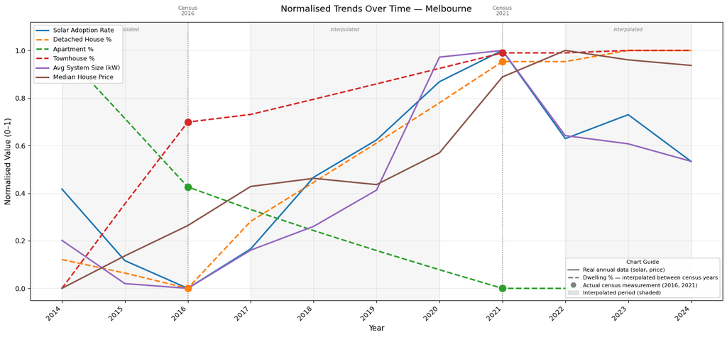

```python
from sklearn.preprocessing import MinMaxScaler

# Data prep
trend_cols = [
    'solar_adoption_rate',
    'detached_pct',
    'apartment_pct',
    'townhouse_pct',
    'solar_kW_per_property',
    'house_median_price',
]

yearly = df_mel_filled.groupby('year')[trend_cols].mean()

scaler = MinMaxScaler()
yearly_norm = pd.DataFrame(
    scaler.fit_transform(yearly),
    columns=trend_cols,
    index=yearly.index
)

all_years = yearly_norm.index.tolist()

# Settings
CENSUS_YEARS = [2016, 2021]

# Periods where dwelling data is interpolated (not real census measurement)
INTERPOLATED_SPANS = [(2014, 2016), (2017, 2020), (2022, 2024)]

DWELLING_COLS = ['detached_pct', 'apartment_pct', 'townhouse_pct']
REAL_COLS     = ['solar_adoption_rate', 'solar_kW_per_property', 'house_median_price']

colors = {
    'solar_adoption_rate':   '#1f77b4',
    'detached_pct':          '#ff7f0e',
    'apartment_pct':         '#2ca02c',
    'townhouse_pct':         '#d62728',
    'solar_kW_per_property': '#9467bd',
    'house_median_price':          '#8c564b',
}

labels = {
    'solar_adoption_rate':   'Solar Adoption Rate',
    'detached_pct':          'Detached House %',
    'apartment_pct':         'Apartment %',
    'townhouse_pct':         'Townhouse %',
    'solar_kW_per_property': 'Avg System Size (kW)',
    'house_median_price':          'Median House Price',
}

# Plot
fig, ax = plt.subplots(figsize=(15, 7))

# Draw lines
for col in trend_cols:
    color  = colors[col]
    values = yearly_norm[col]

    if col in REAL_COLS:
        # Solid line — real annual data
        ax.plot(all_years, values,
                color=color, linewidth=2.2,
                linestyle='-', label=labels[col], zorder=3)
    else:
        # Dashed line — interpolated between census years
        ax.plot(all_years, values,
                color=color, linewidth=2.2,
                linestyle='--', label=labels[col], zorder=3)

        # Dots at actual census years
        for cy in CENSUS_YEARS:
            if cy in yearly_norm.index:
                ax.scatter(cy, values[cy],
                           color=color, s=100, zorder=6, marker='o')

# Shaded interpolated periods
for start, end in INTERPOLATED_SPANS:
    ax.axvspan(start, end, alpha=0.07, color='grey', zorder=1)
    ax.text((start + end) / 2, 0.98,
            'interpolated', ha='center', va='top',
            fontsize=7, color='grey', style='italic',
            transform=ax.get_xaxis_transform())

# Census year vertical markers
for cy in CENSUS_YEARS:
    ax.axvline(x=cy, color='black', linestyle=':',
               alpha=0.4, linewidth=1.2, zorder=4)
    ax.text(cy, 1.02, f'Census\n{cy}',
            ha='center', va='bottom', fontsize=8, color='black', alpha=0.6,
            transform=ax.get_xaxis_transform())

# X axis every year
ax.set_xticks(all_years)
ax.set_xticklabels([str(y) for y in all_years], rotation=45, ha='right')

# Labels
ax.set_title(
    'Normalised Trends Over Time — Melbourne',
    fontsize=13, pad=15
)
ax.set_xlabel('Year', fontsize=11)
ax.set_ylabel('Normalised Value (0–1)', fontsize=11)
ax.set_ylim(-0.05, 1.12)
ax.grid(True, alpha=0.25)

# Two legends
# Legend 1 — variable names (top left)
leg1 = ax.legend(loc='upper left', fontsize=9, framealpha=0.9)
ax.add_artist(leg1)

# Legend 2 — line style guide (bottom right)
solid_line  = mlines.Line2D([], [], color='grey', linewidth=2,
                             linestyle='-',
                             label='Real annual data (solar, price)')
dashed_line = mlines.Line2D([], [], color='grey', linewidth=2,
                             linestyle='--',
                             label='Dwelling % — interpolated between census years')
census_dot  = mlines.Line2D([], [], color='grey', linewidth=0,
                             marker='o', markersize=7,
                             label='Actual census measurement (2016, 2021)')
grey_patch  = mpatches.Patch(color='grey', alpha=0.2,
                              label='Interpolated period (shaded)')

ax.legend(
    handles=[solid_line, dashed_line, census_dot, grey_patch],
    loc='lower right', fontsize=8, framealpha=0.9,
    title='Chart Guide', title_fontsize=8
)

plt.tight_layout()
#plt.savefig('normalized_trends_improved.png', dpi=150, bbox_inches='tight')
plt.show()
```

#### Insights:

1. SOLAR ADOPTION RATE (blue)
   - Low adoption 2014–2017 — early adoption phase
   - Sharp rise 2018–2021 — strongest expansion period
   - Dip 2022 — adoption falls after the 2021 peak, likely reflects rebate waitlist backlog and installation capacity, labour availability, supply chain disruptions that are likely affected by COVID-19 pandemic
   - Partial recovery 2023, followed by another decline in 2024
   - Overall: adoption expanded strongly but became more volatile after 2021
2. DETACHED HOUSE % (orange)
   - Low in 2014–2016, then rises steadily to 2021
   - Flattens after 2021, because no 2026 census to interpolate toward
   - Higher detached-house share provides greater rooftop solar potential
   - Important structural factor for solar adoption, but not the only driver
3. APARTMENT % (green)
   - High in 2014 reflects inner-city postcode dominance in early dataset, declines substantially from 2014 to 2021
   - Higher apartment share can constrain rooftop solar due to limited individual roof access and strata/shared-roof arrangements
   - Lower apartment share may therefore support greater rooftop solar potential
4. TOWNHOUSE % (red)
   - Gradual rise from 2014 to 2021
   - Reflects increasing medium-density development
   - Solar-eligible, but smaller/shared roof configurations may limit system size compared with detached houses
5. AVG SYSTEM SIZE (kW) (purple)
   - Gradual increase 2017–2019
   - Sharp rise 2020–2021 — average system size reaches its peak but declines steadily from 2022–2024
   - Recent solar adoption is increasingly associated with smaller average systems rather than continued system-size growth
   - Trend may reflect changing installation patterns, costs and household characteristics
6. MEDIAN HOUSE PRICE (brown)
   - Gradual increase 2014–2019
   - Strong rise 2020–2022 — coincides with the Melbourne property boom and falls slowly from 2023–2024
   - Higher property values may improve household equity/financing capacity for solar
   - The parallel movement with solar adoption suggests a potential relationship, but statistical analysis is required to confirm it

**Conclusion:** Solar adoption expanded rapidly from 2017–2021, alongside larger average system sizes and rising house prices. After 2021, adoption and system size became more volatile, while the estimated housing composition remained relatively stable through 2024. Overall, the findings suggest that solar adoption is influenced by a combination of housing structure, economic conditions and solar-market factors rather than a single driver. As housing-type data after the latest Census observations were interpolated, these trends should be interpreted as estimates rather than direct observations.

#### Ditribution of Solar Adoption Rates (All Postcodes)

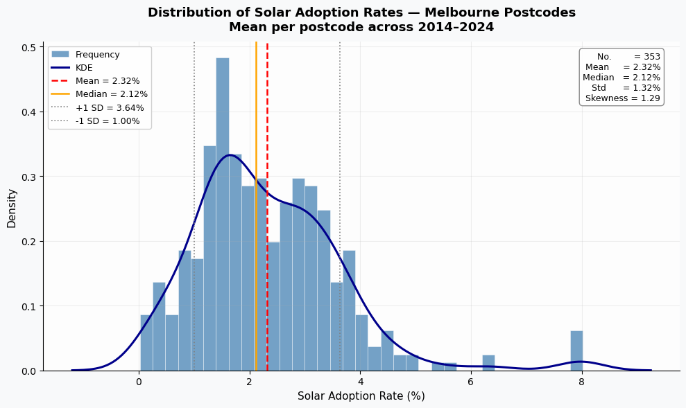

```
Mean:     2.32%
Median:   2.12%
Std:      1.32%
Skewness: 1.29
No.:        353 postcodes
```

```python
df_cross = df_mel_filled.groupby('postcode').agg(
    solar_adoption_rate = ('solar_adoption_rate', 'mean'),
    distance_zone       = ('distance_zone',       'first'),
).reset_index().dropna()

df_cross['postcode'] = pd.to_numeric(df_cross['postcode'], errors='coerce')
df_cross = df_cross[df_cross['postcode'].between(3000, 3999)].copy()
df_cross['solar_adoption_rate'] = df_cross['solar_adoption_rate'].clip(
    upper=df_cross['solar_adoption_rate'].quantile(0.99))

df_cross['solar_adoption_rate'] = df_cross['solar_adoption_rate'] * 100
data       = df_cross['solar_adoption_rate'].dropna()
mean_val   = data.mean()
median_val = data.median()
std_val    = data.std()
skew_val   = data.skew()

# Plot
fig, ax = plt.subplots(figsize=(10, 6))
fig.patch.set_facecolor('#f8f9fa')
ax.set_facecolor('#fdfdfd')

ax.hist(data, bins=35,
        color='steelblue', edgecolor='white',
        linewidth=0.4, alpha=0.75,
        density=True, label='Frequency')

sns.kdeplot(data, ax=ax,
            color='darkblue', linewidth=2.2,
            label='KDE')

ax.axvline(mean_val,
           color='red', linestyle='--',
           linewidth=1.8,
           label=f'Mean = {mean_val:.2f}%')
ax.axvline(median_val,
           color='orange', linestyle='-',
           linewidth=1.8,
           label=f'Median = {median_val:.2f}%')
ax.axvline(mean_val + std_val,
           color='grey', linestyle=':',
           linewidth=1.2,
           label=f'+1 SD = {mean_val+std_val:.2f}%')
ax.axvline(mean_val - std_val,
           color='grey', linestyle=':',
           linewidth=1.2,
           label=f'-1 SD = {mean_val-std_val:.2f}%')

ax.set_title(
    'Distribution of Solar Adoption Rates — Melbourne Postcodes\n'
    'Mean per postcode across 2014–2024',
    fontsize=13, fontweight='bold', pad=12
)
ax.set_xlabel('Solar Adoption Rate (%)', fontsize=11)
ax.set_ylabel('Density',                 fontsize=11)
ax.legend(fontsize=9, framealpha=0.9)

ax.annotate(
    f'No.        = {len(data)}\n'
    f'Mean     = {mean_val:.2f}%\n'
    f'Median   = {median_val:.2f}%\n'
    f'Std      = {std_val:.2f}%\n'
    f'Skewness = {skew_val:.2f}',
    xy=(0.97, 0.97), xycoords='axes fraction',
    ha='right', va='top', fontsize=9,
    bbox=dict(boxstyle='round,pad=0.4',
              facecolor='white',
              edgecolor='grey', alpha=0.9)
)

ax.grid(True, alpha=0.2)
ax.spines[['top', 'right']].set_visible(False)

plt.tight_layout()

plt.show()

print(f"\nMean:     {mean_val:.2f}%")
print(f"Median:   {median_val:.2f}%")
print(f"Std:      {std_val:.2f}%")
print(f"Skewness: {skew_val:.2f}")
print(f"No.:        {len(data)} postcodes")
```

#### Top 10 Postcodes by Latest Adoption Rate

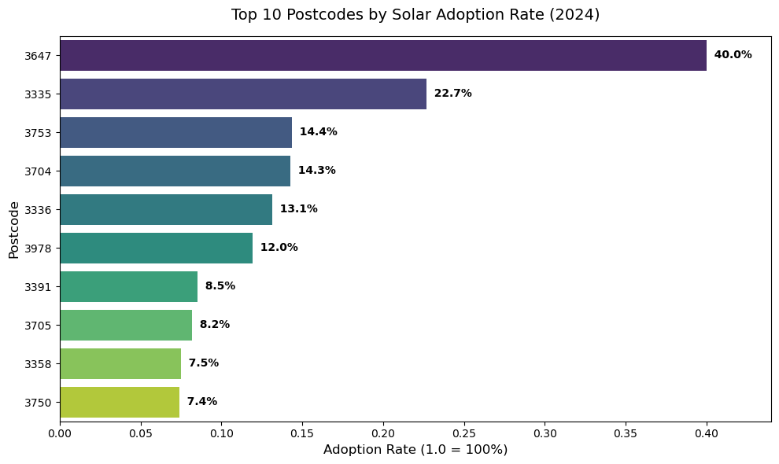

```python
# Filter for the latest year
latest_year = df_mel_filled['year'].max()
df_latest = df_mel_filled[df_mel_filled['year'] == latest_year].copy()

# Convert postcode to string for categorical display
df_latest['postcode'] = df_latest['postcode'].astype(int).astype(str)

# Get the top 10 unique postcodes by adoption rate
top10 = (
    df_latest.groupby('postcode')['solar_adoption_rate']
    .max()
    .reset_index()
    .sort_values('solar_adoption_rate', ascending=False)
    .head(10)
)

# Plotting
plt.figure(figsize=(10, 6))

# Capture the plot axis 'ax' so we can manipulate the bars
ax = sns.barplot(
    data=top10,
    x='solar_adoption_rate',
    y='postcode',
    palette='viridis'

)

# ALTERNATIVE FIXED: Iterate through the visual patches directly
pct_labels = [f'{val * 100:.1f}%' for val in top10['solar_adoption_rate']]

# Get all the horizontal bars drawn on the screen
bars = [p for p in ax.patches if p.get_width() > 0]

for bar, label in zip(bars, pct_labels):
    # Get the position coordinates of each individual bar
    width = bar.get_width()
    y = bar.get_y() + bar.get_height() / 2

    # Write the text label explicitly at the tip of the bar
    ax.text(
        width, y,
        f'  {label}',  # Spacing padding
        va='center',
        ha='left',
        fontsize=10,
        fontweight='bold'
    )
# Aesthetics and Labels
plt.title(f'Top 10 Postcodes by Solar Adoption Rate ({latest_year})', fontsize=14, pad=15)
plt.xlabel('Adoption Rate (1.0 = 100%)', fontsize=12)
plt.ylabel('Postcode', fontsize=12)

# Slightly expand the X-axis maximum limit so the text labels don't get cut off
plt.xlim(0, top10['solar_adoption_rate'].max() * 1.1)

plt.tight_layout()
plt.show()
```

**Insights:**

The latest-year ranking shows that postcode 3647 has the highest solar adoption rate, followed by 3335, 3753, 3704 and 3336. However, some high-ranking postcodes may have small property counts, so their adoption rates should be interpreted carefully.

Postcodes such as 3335, 3336, 3978 and 3750 are more meaningful for policy interpretation because they are likely to represent larger residential areas with stronger adoption patterns. These postcodes suggest that outer or growth-area suburbs may have higher solar uptake, likely due to more detached housing and greater rooftop availability.

Overall, the result highlights areas with strong current solar adoption, but the ranking should be reviewed together with total property count to separate genuine high-adoption markets from small-postcode outliers.

#### Top 10 Postcode by Mean Solar Adoption Rate (2014-2024)

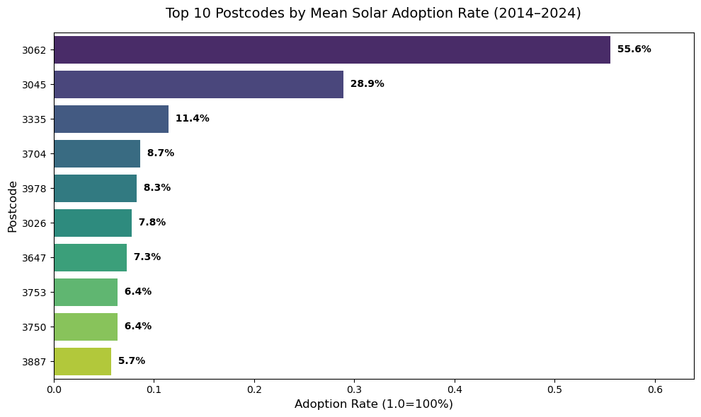

```python
# Filter for 2014–2024
df_period = df_mel_filled[
    (df_mel_filled["year"].between(2014, 2024)) &
    (df_mel_filled["solar_adoption_rate"].between(0, 1))
].copy()

# Convert postcode to string for categorical display
df_period["postcode"] = df_period["postcode"].astype(str).str.zfill(4)


# Get top 10 unique postcodes by mean adoption rate across 2014–2024
top10 = (
    df_period
    .groupby("postcode")
    .agg(
        mean_solar_adoption_rate=("solar_adoption_rate", "mean"),
        median_solar_adoption_rate=("solar_adoption_rate", "median"),
        years_available=("year", "nunique"),
        mean_total_property_count=("total_property_count", "mean")
    )
    .reset_index()
    .sort_values("mean_solar_adoption_rate", ascending=False)
    .head(10)
)

# Plotting
plt.figure(figsize=(10, 6))

ax = sns.barplot(
    data=top10,
    x="mean_solar_adoption_rate",
    y="postcode",
    palette="viridis",
    order=top10["postcode"]
)

# Percentage labels
pct_labels = [f"{val * 100:.1f}%" for val in top10["mean_solar_adoption_rate"]]

bars = [p for p in ax.patches if p.get_width() > 0]

for bar, label in zip(bars, pct_labels):
    width = bar.get_width()
    y = bar.get_y() + bar.get_height() / 2

    ax.text(
        width,
        y,
        f"  {label}",
        va="center",
        ha="left",
        fontsize=10,
        fontweight="bold"
    )

# Aesthetics and labels
plt.title("Top 10 Postcodes by Mean Solar Adoption Rate (2014–2024)", fontsize=14, pad=15)
plt.xlabel("Adoption Rate (1.0=100%)", fontsize=12)
plt.ylabel("Postcode", fontsize=12)

plt.xlim(0, top10["mean_solar_adoption_rate"].max() * 1.15)

plt.tight_layout()
plt.show()
```

**Insight:**

While several postcodes rank highly in mean solar adoption rate between 2014 and 2024, not all high-ranking results carry the same level of significance. Some of the top-ranked postcodes represent specialised or small-population areas, which can inflate adoption percentages. For example, 3045 corresponds to Melbourne Airport and surrounding industrial land, while 3062 covers Somerton, a largely industrial and logistics area. Postcode 3704 includes rural communities around Lake Hume, and 3647 covers the small regional locality of Wahgunyah near the Murray River.

A more reliable pattern emerges in postcodes such as 3335 (Rockbank), 3978 (Clyde and Clyde North), 3026 (Laverton North and Derrimut), 3753 (Beveridge) and 3750 (Kalkallo), where higher adoption rates are supported by larger property bases and consistent observations across the 11-year period. Many of these are growth-area suburbs with substantial detached housing stock and ample rooftop space, making them well suited to solar installations.

This suggests that solar adoption rankings should be interpreted alongside property counts and local context. High adoption rates in larger residential postcodes provide a more meaningful indication of long-term solar uptake trends and may offer better guidance for policy and planning decisions.

### Section 2 - Exploratory Analysis

#### Correlation Heatmap

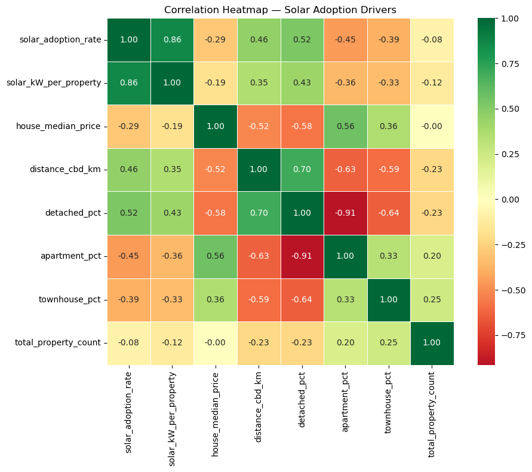

```
solar_adoption_rate      1.000000
solar_kW_per_property    0.863232
detached_pct             0.524043
distance_cbd_km          0.461065
total_property_count    -0.081457
house_median_price      -0.293368
townhouse_pct           -0.389301
apartment_pct           -0.454071
Name: solar_adoption_rate, dtype: float64
```

```python
#shows strength of relationships:
corr_cols = [
    'solar_adoption_rate',
    'solar_kW_per_property',
    'house_median_price',
    'distance_cbd_km',
    'detached_pct',
    'apartment_pct',
    'townhouse_pct',
    'total_property_count',
]

corr_matrix = df_metro[corr_cols].corr()

plt.figure(figsize=(10, 8))
sns.heatmap(corr_matrix,
            annot=True,           # show numbers
            fmt='.2f',            # 2 decimal places
            cmap='RdYlGn',        # red=negative, green=positive
            center=0,
            square=True,
            linewidths=0.5)
plt.title('Correlation Heatmap — Solar Adoption Drivers')
plt.tight_layout()
plt.show()
print(corr_matrix['solar_adoption_rate'].sort_values(ascending=False))
```

**Conclusion:**

The correlation heatmap shows that solar adoption is mainly associated with dwelling structure and urban location. Solar adoption rate has a strong positive relationship with solar kW per property, while detached dwelling proportion and distance from Melbourne CBD also show positive relationships. In contrast, apartment and townhouse proportions are negatively related to solar adoption, suggesting that higher-density housing areas face structural barriers to rooftop solar. House median price also shows a negative relationship, likely because higher-priced inner areas often contain more apartments. Total property count has very weak negative relationship, the number of properties alone has little association with adoption.

#### Scatter Plot

```
Feature                    Pearson r    p-value   Spearman ρ      Sig   Strength
--------------------------------------------------------------------------------
Detached House %              +0.728     0.0000       +0.840        ✅     Strong
Apartment %                   -0.639     0.0000       -0.803        ✅     Strong
Townhouse %                   -0.544     0.0000       -0.647        ✅     Strong
Vacant Property %             -0.411     0.0000       -0.667        ✅   Moderate
Avg System Size (kW)          +0.852     0.0000       +0.971        ✅     Strong
House Median Price ($)        -0.529     0.0000       -0.718        ✅     Strong
Apartment Median Price($)     -0.439     0.0000       -0.459        ✅   Moderate
Distance from CBD (km)        +0.642     0.0000       +0.803        ✅     Strong
```

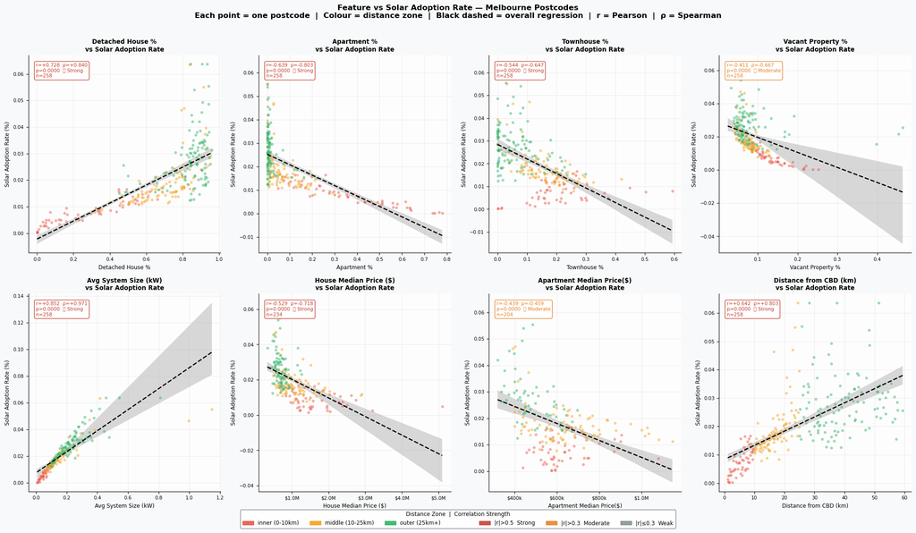

```python
# Aggregate to postcode level
df_cross = df_metro.groupby('postcode').agg(
    solar_adoption_rate  = ('solar_adoption_rate',  'mean'),
    solar_kW_per_property= ('solar_kW_per_property','mean'),
    detached_pct         = ('detached_pct',          'mean'),
    apartment_pct        = ('apartment_pct',         'mean'),
    townhouse_pct        = ('townhouse_pct',         'mean'),
    vacant_pct           = ('vacant_pct',            'mean'),
    house_median_price   = ('house_median_price',    'median'),
    apart_median_price   = ('apart_median_price',    'median'),
    distance_cbd_km      = ('distance_cbd_km',       'first'),
    distance_zone        = ('distance_zone',         'first'),
).reset_index()

df_cross['postcode'] = pd.to_numeric(df_cross['postcode'], errors='coerce')
df_cross = df_cross[
    df_cross['postcode'].between(3000, 3999) &
    df_cross['distance_cbd_km'].between(0, 70)
].copy()

# Clip top 1% adoption rate
cap = df_cross['solar_adoption_rate'].quantile(0.99)
df_cross['solar_adoption_rate'] = df_cross['solar_adoption_rate'].clip(upper=cap)

# Features to plot
features = {
    'detached_pct':          'Detached House %',
    'apartment_pct':         'Apartment %',
    'townhouse_pct':         'Townhouse %',
    'vacant_pct':            'Vacant Property %',
    'solar_kW_per_property': 'Avg System Size (kW)',
    'house_median_price':    'House Median Price ($)',
    'apart_median_price':    'Apartment Median Price($)',
    'distance_cbd_km':       'Distance from CBD (km)',
}

zone_palette = {
    'inner (0-10km)':   '#e74c3c',
    'middle (10-25km)': '#f39c12',
    'outer (25km+)':    '#27ae60',
}

# Figure: 2×4 grid
fig, axes = plt.subplots(2, 4, figsize=(20, 11))
fig.patch.set_facecolor('#f8f9fa')
axes = axes.flatten()

print(f"{'Feature':<25} {'Pearson r':>10} {'p-value':>10} "
      f"{'Spearman ρ':>12} {'Sig':>8} {'Strength':>10}")
print("-" * 80)

for idx, (col, label) in enumerate(features.items()):
    ax = axes[idx]
    ax.set_facecolor('#fdfdfd')

    # Drop nulls for this feature
    df_plot = df_cross[['solar_adoption_rate', col,
                         'distance_zone']].dropna()

    if len(df_plot) < 5:
        ax.text(0.5, 0.5, 'Insufficient data',
                ha='center', va='center',
                transform=ax.transAxes, fontsize=10, color='grey')
        ax.set_title(label, fontsize=10, fontweight='bold')
        continue

    # Scatter coloured by zone
    for zone, color in zone_palette.items():
        sub = df_plot[df_plot['distance_zone'] == zone]
        ax.scatter(sub[col], sub['solar_adoption_rate'],
                   color=color, alpha=0.45, s=20,
                   edgecolors='white', linewidth=0.2,
                   zorder=2)

    #Overall regression line
    sns.regplot(data=df_plot,
                x=col, y='solar_adoption_rate',
                scatter=False,
                line_kws={'color': 'black', 'linewidth': 1.8,
                          'linestyle': '--'},
                ci=95, ax=ax)

    # Stats
    r_p, p_p = pearsonr( df_plot[col], df_plot['solar_adoption_rate'])
    r_s, p_s = spearmanr(df_plot[col], df_plot['solar_adoption_rate'])

    strength = ('Strong'   if abs(r_p) > 0.5 else
                'Moderate' if abs(r_p) > 0.3 else 'Weak')
    sig      = '✅' if p_p < 0.05 else '❌'
    r_color  = ('#c0392b' if abs(r_p) > 0.5 else
                '#e67e22' if abs(r_p) > 0.3 else '#7f8c8d')

    # Print to console
    print(f"{label:<25} {r_p:>+10.3f} {p_p:>10.4f} "
          f"{r_s:>+12.3f} {sig:>8} {strength:>10}")

    # ── Annotation box ────────────────────────────────────────────────
    ax.annotate(
        f'r={r_p:+.3f}  ρ={r_s:+.3f}\np={p_p:.4f}  {sig} {strength}\nn={len(df_plot)}',
        xy=(0.04, 0.96), xycoords='axes fraction',
        va='top', ha='left', fontsize=7.5, color=r_color,
        bbox=dict(boxstyle='round,pad=0.35', facecolor='white',
                  edgecolor=r_color, alpha=0.9)
    )

    # ── Format price axis ─────────────────────────────────────────────
    if 'price' in col:
        ax.xaxis.set_major_formatter(
            plt.FuncFormatter(lambda x, _: f'${x/1e6:.1f}M'
                              if x >= 1e6 else f'${x/1e3:.0f}k')
        )

    ax.set_xlabel(label, fontsize=8.5)
    ax.set_ylabel('Solar Adoption Rate (%)', fontsize=8.5)
    ax.set_title(f'{label}\nvs Solar Adoption Rate',
                 fontsize=9.5, fontweight='bold', pad=6)
    ax.tick_params(labelsize=7.5)
    ax.grid(True, alpha=0.2)
    ax.spines[['top', 'right']].set_visible(False)

# ── Shared zone legend ────────────────────────────────────────────────────
zone_patches = [
    mpatches.Patch(color=c, label=z, alpha=0.85)
    for z, c in zone_palette.items()
]
strength_patches = [
    mpatches.Patch(color='#c0392b', label='|r|>0.5  Strong',   alpha=0.85),
    mpatches.Patch(color='#e67e22', label='|r|>0.3  Moderate', alpha=0.85),
    mpatches.Patch(color='#7f8c8d', label='|r|≤0.3  Weak',     alpha=0.85),
]
divider = [mpatches.Patch(color='white', label=' ')]

fig.legend(
    handles=zone_patches + divider + strength_patches,
    loc='lower center', ncol=7,
    fontsize=8.5, framealpha=0.92,
    bbox_to_anchor=(0.5, -0.03),
    title='Distance Zone  |  Correlation Strength',
    title_fontsize=8.5, edgecolor='grey'
)

# ── Overall title ─────────────────────────────────────────────────────────
fig.suptitle(
    'Feature vs Solar Adoption Rate — Melbourne Postcodes\n'
    'Each point = one postcode  |  Colour = distance zone  |  '
    'Black dashed = overall regression  |  r = Pearson  |  ρ = Spearman',
    fontsize=12, fontweight='bold', y=1.01
)

plt.tight_layout()
#plt.savefig('scatter_all_features_vs_adoption.png',
            #dpi=150, bbox_inches='tight')
plt.show()
#print('\nSaved: scatter_all_features_vs_adoption.png')
```

**Conclusion:**

The scatter plots indicate that solar adoption is closely linked to housing type. Areas with a higher proportion of detached houses tend to have higher solar adoption rates, while areas with more apartments, townhouses, and vacant properties generally show lower adoption.

Overall, dwelling type and rooftop suitability appear to be more important drivers of solar adoption than property prices alone.

#### Pairplot

Pairplot analysis was used to explore relationships between solar adoption rate and key explanatory variables. To improve readability, the variables were divided into two groups.

Group 1 — Dwelling Structure and Solar Adoption uses the df_metro dataset and examines solar adoption alongside detached house proportion, apartment proportion, townhouse proportion and distance from Melbourne CBD.

Group 2 — Economic Factors and Solar Adoption uses the df_metro_price dataset and focuses on house median price, average system size and distance from Melbourne CBD. This dataset was used because house price data is only available for a subset of postcodes.

A triangle pairplot format was used instead of the full square version because it removes duplicated relationships shown in the upper and lower triangles. This provides a cleaner visualisation while retaining all unique variable relationships and distributions.

- **Group 1 — Dwelling Structure & Solar Adoption (df_metro)**

```
Postcodes: 258
```

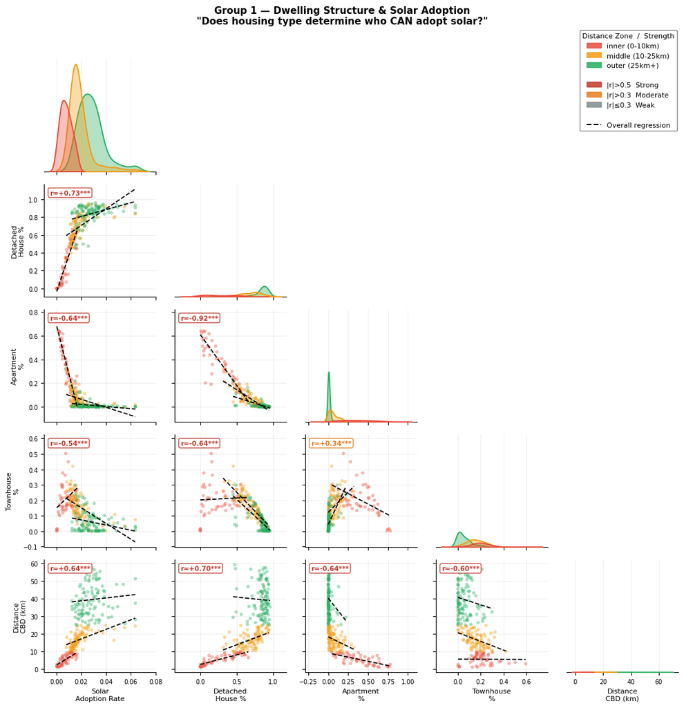

```
=== GROUP 1 CORRELATIONS WITH SOLAR ADOPTION RATE ===
Feature                     r            p    Sig   Strength
------------------------------------------------------------
detached_pct           +0.728    6.123e-44    ***     Strong
apartment_pct          -0.639    5.084e-31    ***     Strong
townhouse_pct          -0.544    3.069e-21    ***     Strong
distance_cbd_km        +0.642    2.505e-31    ***     Strong
```

```python
df_cross = df_metro.groupby('postcode').agg(
    solar_adoption_rate = ('solar_adoption_rate', 'mean'),
    detached_pct        = ('detached_pct',         'mean'),
    apartment_pct       = ('apartment_pct',        'mean'),
    townhouse_pct       = ('townhouse_pct',        'mean'),
    distance_cbd_km     = ('distance_cbd_km',      'first'),
    distance_zone       = ('distance_zone',        'first'),
).reset_index().dropna(subset=['solar_adoption_rate'])

df_cross['postcode'] = pd.to_numeric(df_cross['postcode'], errors='coerce')
df_cross = df_cross[
    df_cross['postcode'].between(3000, 3999) &
    df_cross['distance_cbd_km'].between(0, 70)
].copy()

df_cross['solar_adoption_rate'] = df_cross['solar_adoption_rate'].clip(
    upper=df_cross['solar_adoption_rate'].quantile(0.99))

print(f"Postcodes: {len(df_cross)}")

# Settings
group1_cols = [
    'solar_adoption_rate',
    'detached_pct',
    'apartment_pct',
    'townhouse_pct',
    'distance_cbd_km',
]

axis_labels = {
    'solar_adoption_rate': 'Solar\nAdoption Rate',
    'detached_pct':        'Detached\nHouse %',
    'apartment_pct':       'Apartment\n%',
    'townhouse_pct':       'Townhouse\n%',
    'distance_cbd_km':     'Distance\nCBD (km)',
}

zone_palette = {
    'inner (0-10km)':   '#e74c3c',
    'middle (10-25km)': '#f39c12',
    'outer (25km+)':    '#27ae60',
}

# Build PairGrid
df_plot = df_cross[group1_cols + ['distance_zone']].dropna()

g = sns.PairGrid(
    df_plot,
    vars=group1_cols,
    hue='distance_zone',
    palette=zone_palette,
    corner=True,
    height=2.2,
    aspect=1.0,
)

g.map_lower(sns.scatterplot,
            alpha=0.40, s=15,
            linewidth=0, zorder=2)

g.map_lower(sns.regplot,
            scatter=False,
            line_kws={'color': 'black',
                      'linewidth': 1.3,
                      'linestyle': '--'},
            ci=None)

g.map_diag(sns.kdeplot,
           fill=True, alpha=0.35,
           linewidths=1.4,
           warn_singular=False)

# Annotate r values
n = len(group1_cols)
for i in range(n):
    for j in range(n):
        if j >= i:
            continue
        ax = g.axes[i, j]
        if ax is None:
            continue
        common = df_plot[[group1_cols[j],
                           group1_cols[i]]].dropna()
        if len(common) < 5:
            continue
        r, p = pearsonr(common[group1_cols[j]],
                        common[group1_cols[i]])
        stars = ('***' if p < 0.001 else
                 '**'  if p < 0.01  else
                 '*'   if p < 0.05  else 'ns')
        r_color = ('#c0392b' if abs(r) > 0.5 else
                   '#e67e22' if abs(r) > 0.3 else
                   '#7f8c8d')
        ax.annotate(
            f'r={r:+.2f}{stars}',
            xy=(0.05, 0.95),
            xycoords='axes fraction',
            fontsize=7.5, fontweight='bold',
            color=r_color, va='top',
            bbox=dict(boxstyle='round,pad=0.25',
                      facecolor='white',
                      edgecolor=r_color, alpha=0.88)
        )

# Axis labels
for i in range(n):
    for j in range(n):
        ax = g.axes[i, j]
        if ax is None:
            continue
        ax.set_ylabel(
            axis_labels.get(group1_cols[i], group1_cols[i])
            if j == 0 and i > 0 else '',
            fontsize=8)
        ax.set_xlabel(
            axis_labels.get(group1_cols[j], group1_cols[j])
            if i == n - 1 else '',
            fontsize=8)
        ax.tick_params(labelsize=7)
        ax.grid(True, alpha=0.2)

# Legend
zone_patches = [
    mpatches.Patch(color=c, label=z, alpha=0.85)
    for z, c in zone_palette.items()
]
strength_patches = [
    mpatches.Patch(color='#c0392b', alpha=0.85, label='|r|>0.5  Strong'),
    mpatches.Patch(color='#e67e22', alpha=0.85, label='|r|>0.3  Moderate'),
    mpatches.Patch(color='#7f8c8d', alpha=0.85, label='|r|≤0.3  Weak'),
]
reg_line = mlines.Line2D([], [], color='black', linewidth=1.5,
                          linestyle='--', label='Overall regression')
divider  = [mpatches.Patch(color='white', label=' ')]

g.figure.legend(
    handles=zone_patches + divider + strength_patches + divider + [reg_line],
    loc='upper right',
    bbox_to_anchor=(0.99, 0.99),
    fontsize=8, framealpha=0.92,
    title='Distance Zone  /  Strength',
    title_fontsize=8, edgecolor='grey'
)

g.figure.suptitle(
    'Group 1 — Dwelling Structure & Solar Adoption\n'
    '"Does housing type determine who CAN adopt solar?"',
    fontsize=11, fontweight='bold', y=1.02
)

plt.tight_layout()
plt.show()


# Summary
print("\n=== GROUP 1 CORRELATIONS WITH SOLAR ADOPTION RATE ===")
print(f"{'Feature':<20} {'r':>8} {'p':>12} {'Sig':>6} {'Strength':>10}")
print("-" * 60)
for col in group1_cols[1:]:
    common = df_cross[['solar_adoption_rate', col]].dropna()
    r, p   = pearsonr(common['solar_adoption_rate'], common[col])
    sig    = ('***' if p < 0.001 else '**' if p < 0.01 else
              '*'   if p < 0.05  else 'ns')
    st     = ('Strong'   if abs(r) > 0.5 else
              'Moderate' if abs(r) > 0.3 else 'Weak')
    print(f"{col:<20} {r:>+8.3f} {p:>12.3e} {sig:>6} {st:>10}")
```

**Conclusion:**

The pairplot and correlation results show that solar adoption is strongly linked to dwelling type and location. Detached house proportion has the strongest positive relationship with solar adoption rate, while apartment and townhouse proportions are negatively related, indicating lower adoption in higher-density areas. Distance from Melbourne CBD is also positively associated with solar adoption, suggesting that outer suburban areas with more detached housing are better suited to rooftop solar. Overall, dwelling structure and urban form appear to be key factors influencing solar adoption.

- **Group 2 — Economic Factors & Solar Adoption (df_metro_price)**

```
Postcodes: 234
```

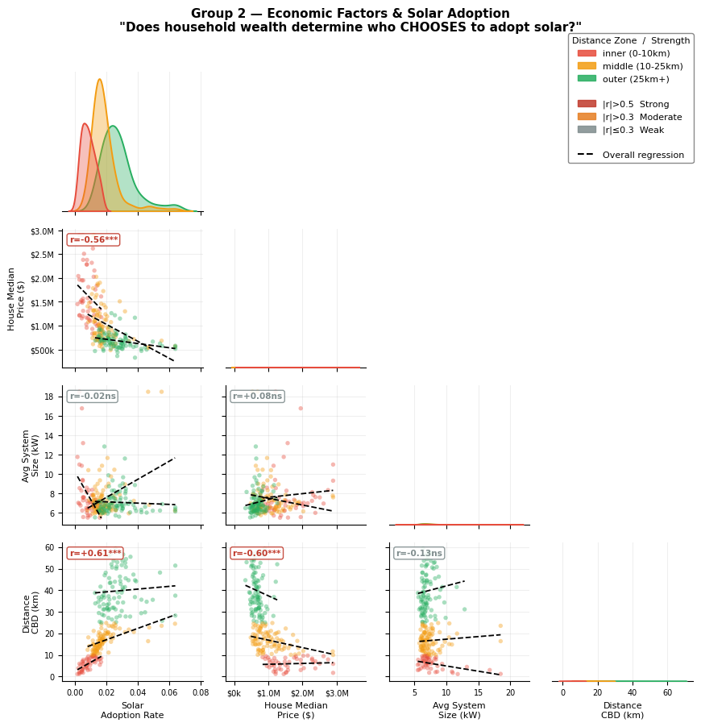

```
=== GROUP 2 CORRELATIONS WITH SOLAR ADOPTION RATE ===
Feature                       r            p    Sig   Strength
--------------------------------------------------------------
house_median_price       -0.557    1.923e-20    ***     Strong
avg_system_size_kW       -0.017    8.012e-01     ns       Weak
distance_cbd_km          +0.615    1.071e-25    ***     Strong
```

```python
df_cross = df_metro_price.groupby('postcode').agg(
    solar_adoption_rate = ('solar_adoption_rate', 'mean'),
    house_median_price  = ('house_median_price',  'median'),
    avg_system_size_kW  = ('avg_system_size_kW',  'mean'),
    distance_cbd_km     = ('distance_cbd_km',     'first'),
    distance_zone       = ('distance_zone',       'first'),
).reset_index().dropna(subset=['solar_adoption_rate'])

df_cross['postcode'] = pd.to_numeric(df_cross['postcode'], errors='coerce')
df_cross = df_cross[
    df_cross['postcode'].between(3000, 3999) &
    df_cross['distance_cbd_km'].between(0, 70)
].copy()

# Clip outliers
for col in ['solar_adoption_rate',
            'house_median_price',
            'avg_system_size_kW']:
    if col in df_cross.columns:
        df_cross[col] = df_cross[col].clip(
            upper=df_cross[col].quantile(0.99))

print(f"Postcodes: {len(df_cross)}")

# Settings
group2_cols = [
    'solar_adoption_rate',
    'house_median_price',
    'avg_system_size_kW',
    'distance_cbd_km',
]

axis_labels = {
    'solar_adoption_rate': 'Solar\nAdoption Rate',
    'house_median_price':  'House Median\nPrice ($)',
    'avg_system_size_kW':  'Avg System\nSize (kW)',
    'distance_cbd_km':     'Distance\nCBD (km)',
}

zone_palette = {
    'inner (0-10km)':   '#e74c3c',
    'middle (10-25km)': '#f39c12',
    'outer (25km+)':    '#27ae60',
}

# Build PairGrid
df_plot = df_cross[group2_cols + ['distance_zone']].dropna()

g = sns.PairGrid(
    df_plot,
    vars=group2_cols,
    hue='distance_zone',
    palette=zone_palette,
    corner=True,
    height=2.2,
    aspect=1.0,
)

g.map_lower(sns.scatterplot,
            alpha=0.40, s=15,
            linewidth=0, zorder=2)

g.map_lower(sns.regplot,
            scatter=False,
            line_kws={'color': 'black',
                      'linewidth': 1.3,
                      'linestyle': '--'},
            ci=None)

g.map_diag(sns.kdeplot,
           fill=True, alpha=0.35,
           linewidths=1.4,
           warn_singular=False)

# Annotate r values
n = len(group2_cols)
for i in range(n):
    for j in range(n):
        if j >= i:
            continue
        ax = g.axes[i, j]
        if ax is None:
            continue
        common = df_plot[[group2_cols[j],
                           group2_cols[i]]].dropna()
        if len(common) < 5:
            continue
        r, p = pearsonr(common[group2_cols[j]],
                        common[group2_cols[i]])
        stars = ('***' if p < 0.001 else
                 '**'  if p < 0.01  else
                 '*'   if p < 0.05  else 'ns')
        r_color = ('#c0392b' if abs(r) > 0.5 else
                   '#e67e22' if abs(r) > 0.3 else
                   '#7f8c8d')
        ax.annotate(
            f'r={r:+.2f}{stars}',
            xy=(0.05, 0.95),
            xycoords='axes fraction',
            fontsize=7.5, fontweight='bold',
            color=r_color, va='top',
            bbox=dict(boxstyle='round,pad=0.25',
                      facecolor='white',
                      edgecolor=r_color, alpha=0.88)
        )

# Axis labels
for i in range(n):
    for j in range(n):
        ax = g.axes[i, j]
        if ax is None:
            continue
        ax.set_ylabel(
            axis_labels.get(group2_cols[i], group2_cols[i])
            if j == 0 and i > 0 else '',
            fontsize=8)
        ax.set_xlabel(
            axis_labels.get(group2_cols[j], group2_cols[j])
            if i == n - 1 else '',
            fontsize=8)
        # Format price axis
        if 'price' in group2_cols[j]:
            ax.xaxis.set_major_formatter(plt.FuncFormatter(
                lambda x, _: f'${x/1e6:.1f}M'
                if x >= 1e6 else f'${x/1e3:.0f}k'))
        if 'price' in group2_cols[i]:
            ax.yaxis.set_major_formatter(plt.FuncFormatter(
                lambda x, _: f'${x/1e6:.1f}M'
                if x >= 1e6 else f'${x/1e3:.0f}k'))
        ax.tick_params(labelsize=7)
        ax.grid(True, alpha=0.2)

# Legend
zone_patches = [
    mpatches.Patch(color=c, label=z, alpha=0.85)
    for z, c in zone_palette.items()
]
strength_patches = [
    mpatches.Patch(color='#c0392b', alpha=0.85, label='|r|>0.5  Strong'),
    mpatches.Patch(color='#e67e22', alpha=0.85, label='|r|>0.3  Moderate'),
    mpatches.Patch(color='#7f8c8d', alpha=0.85, label='|r|≤0.3  Weak'),
]
reg_line = mlines.Line2D([], [], color='black', linewidth=1.5,
                          linestyle='--', label='Overall regression')
divider  = [mpatches.Patch(color='white', label=' ')]

g.figure.legend(
    handles=zone_patches + divider + strength_patches + divider + [reg_line],
    loc='upper right',
    bbox_to_anchor=(0.99, 0.99),
    fontsize=8, framealpha=0.92,
    title='Distance Zone  /  Strength',
    title_fontsize=8, edgecolor='grey'
)

g.figure.suptitle(
    'Group 2 — Economic Factors & Solar Adoption\n'
    '"Does household wealth determine who CHOOSES to adopt solar?"',
    fontsize=11, fontweight='bold', y=1.02
)

plt.tight_layout()
plt.show()


# Summary
print("\n=== GROUP 2 CORRELATIONS WITH SOLAR ADOPTION RATE ===")
print(f"{'Feature':<22} {'r':>8} {'p':>12} {'Sig':>6} {'Strength':>10}")
print("-" * 62)
for col in group2_cols[1:]:
    common = df_cross[['solar_adoption_rate', col]].dropna()
    if len(common) < 5:
        print(f"{col:<22} insufficient data")
        continue
    r, p   = pearsonr(common['solar_adoption_rate'], common[col])
    sig    = ('***' if p < 0.001 else '**' if p < 0.01 else
              '*'   if p < 0.05  else 'ns')
    st     = ('Strong'   if abs(r) > 0.5 else
              'Moderate' if abs(r) > 0.3 else 'Weak')
    print(f"{col:<22} {r:>+8.3f} {p:>12.3e} {sig:>6} {st:>10}")
```

**Conclusion:**

Overall, the results suggest that solar adoption is influenced more by urban form and dwelling structure than by system size.

### Section 3 - Hypothesis and Significance Testing

#### T-Test, Pearson & Spearman

This section examines whether factors such as dwelling structure, house prices, distance from Melbourne CBD and property count are significantly related to solar adoption rates. Pearson correlation, Spearman correlation and T-tests were used to assess these relationships.

Pearson correlation measures linear relationships, while Spearman correlation evaluates ranked relationships and is less affected by outliers. T-tests were used to compare differences between groups.

Results were evaluated using p-values and correlation strength. Significant results suggest that the observed relationships are unlikely to occur by chance and help determine whether each null hypothesis should be rejected or retained.

- H1: There Is No Significant Relationship Between Detached House Proportion and Solar Adoption Rate
- H2: There Is No Significant Relationship Between Apartment Proportion With Solar Adoption Rate
- H3: There Is No Significant Relationship Between Detached House Prices and Solar Adoption Rate
- H4: There Is No Significant Relationship Between Distance from Melbourne CBD and Solar Adoption Rate (Metro Area)
- H5: There Is No Significant Relationship Between Distance from Melbourne CBD and Solar Adoption Rate (All postcodes)
- H6: There Is No Significant Relationship Between High Property Count and Solar Adoption Rate (Metro Area)
- H7: There Is No Significant Relationship Between High Property Count and Solar Adoption Rate (All postcodes)

#### H1 - Null Hypothesis: There Is No Significant Relationship Between Detached House Proportion and Solar Adoption Rate

```
inner (0-10km)         r=+0.904  p=0.0000
middle (10-25km)       r=+0.610  p=0.0000
outer (25km+)          r=+0.305  p=0.0012
=======================================================
H1 HYPOTHESIS TEST SUMMARY
=======================================================
Pearson  r = +0.669  p = 0.00000  Significant
Spearman ρ = +0.840  p = 0.00000  Significant
T-test   t = 12.698  p = 0.00000  Significant
Strength:  Strong
Postcodes: 258

Conclusion:
H1 - Null Hypothesis IS REJECTED to 'There Is No Significant Relationship Between Detached House Proportion and Solar Adoption Rates.'
Policy: target incentives at detached-house suburbs with currently LOW adoption (financial barrier likely)
```

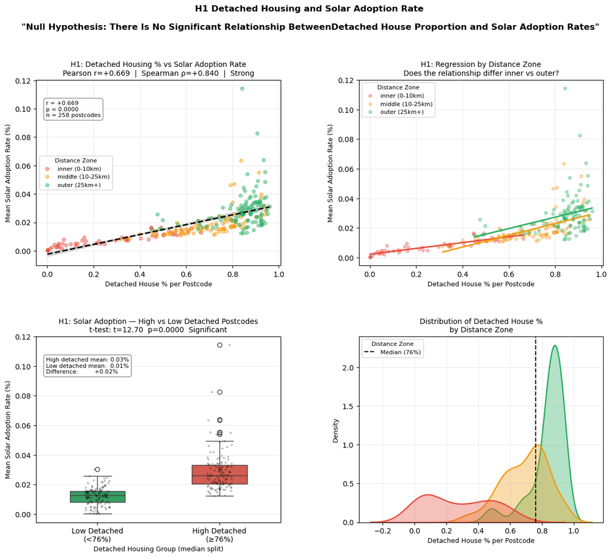

```python
import matplotlib.gridspec as gridspec
from scipy.stats import pearsonr, spearmanr, ttest_ind

# Use postcode-level cross-sectional data
df_cross = df_metro.groupby('postcode').agg(
    solar_adoption_rate  = ('solar_adoption_rate', 'mean'),
    detached_pct         = ('detached_pct',         'mean'),
    distance_zone        = ('distance_zone',        'first'),
).reset_index().dropna()

df_cross['postcode'] = pd.to_numeric(df_cross['postcode'], errors='coerce')
df_cross = df_cross[df_cross['postcode'].between(3000, 3999)].copy()

# Statistical tests
r_pearson,  p_pearson  = pearsonr( df_cross['detached_pct'],
                                   df_cross['solar_adoption_rate'])
r_spearman, p_spearman = spearmanr(df_cross['detached_pct'],
                                   df_cross['solar_adoption_rate'])

# Split into high / low detached groups (median split)
median_detached = df_cross['detached_pct'].median()
high_det = df_cross[df_cross['detached_pct'] >= median_detached]['solar_adoption_rate']
low_det  = df_cross[df_cross['detached_pct'] <  median_detached]['solar_adoption_rate']
t_stat, p_ttest = ttest_ind(high_det, low_det)

# Strength label
def strength(r):
    if abs(r) > 0.5: return 'Strong'
    if abs(r) > 0.3: return 'Moderate'
    return 'Weak'

# Layout: 2×2 grid
fig = plt.figure(figsize=(14, 11))
gs  = gridspec.GridSpec(2, 2, hspace=0.38, wspace=0.32)

zone_palette = {
    'inner (0-10km)':   '#e74c3c',
    'middle (10-25km)': '#f39c12',
    'outer (25km+)':    '#27ae60',
}

# Plot 1 (top-left): Scatter + regression coloured by zone
ax1 = fig.add_subplot(gs[0, 0])

for zone, color in zone_palette.items():
    sub = df_cross[df_cross['distance_zone'] == zone]
    ax1.scatter(sub['detached_pct'], sub['solar_adoption_rate'],
                color=color, alpha=0.45, s=22, label=zone, zorder=2)

# Overall regression line
sns.regplot(data=df_cross,
            x='detached_pct', y='solar_adoption_rate',
            scatter=False,
            line_kws={'color': 'black', 'linewidth': 2, 'linestyle': '--'},
            ci=95, ax=ax1)

ax1.set_title('H1: Detached Housing % vs Solar Adoption Rate\n'
              f'Pearson r={r_pearson:+.3f}  |  '
              f'Spearman ρ={r_spearman:+.3f}  |  {strength(r_pearson)}',
              fontsize=10)
ax1.set_xlabel('Detached House % per Postcode', fontsize=9)
ax1.set_ylabel('Mean Solar Adoption Rate (%)', fontsize=9)
ax1.legend(title='Distance Zone', fontsize=8, title_fontsize=8)
ax1.annotate(
    f'r = {r_pearson:+.3f}\np = {p_pearson:.4f}\nn = {len(df_cross)} postcodes',
    xy=(0.04, 0.80), xycoords='axes fraction', fontsize=8,
    bbox=dict(boxstyle='round,pad=0.4', facecolor='white',
              edgecolor='grey', alpha=0.9)
)
ax1.grid(True, alpha=0.25)

# Plot 2 (top-right): Regression per zone
ax2 = fig.add_subplot(gs[0, 1])

for zone, color in zone_palette.items():
    sub = df_cross[df_cross['distance_zone'] == zone].dropna()
    if len(sub) < 5:
        continue
    sns.regplot(data=sub,
                x='detached_pct', y='solar_adoption_rate',
                scatter_kws={'alpha': 0.35, 's': 18, 'color': color},
                line_kws={'color': color, 'linewidth': 2},
                ci=None, label=zone, ax=ax2)
    r_z, p_z = pearsonr(sub['detached_pct'], sub['solar_adoption_rate'])
    print(f"{zone:<22} r={r_z:+.3f}  p={p_z:.4f}")

ax2.set_title('H1: Regression by Distance Zone\n'
              'Does the relationship differ inner vs outer?',
              fontsize=10)
ax2.set_xlabel('Detached House % per Postcode', fontsize=9)
ax2.set_ylabel('Mean Solar Adoption Rate (%)', fontsize=9)
ax2.legend(title='Distance Zone', fontsize=8, title_fontsize=8)
ax2.grid(True, alpha=0.25)

# Plot 3 (bottom-left): Boxplot high vs low detached
ax3 = fig.add_subplot(gs[1, 0])

df_cross['detached_group'] = np.where(
    df_cross['detached_pct'] >= median_detached,
    f'High Detached\n(≥{median_detached:.0%})',
    f'Low Detached\n(<{median_detached:.0%})'
)

sns.boxplot(data=df_cross,
            x='detached_group', y='solar_adoption_rate',
            palette=['#27ae60', '#e74c3c'],
            order=[f'Low Detached\n(<{median_detached:.0%})',
                   f'High Detached\n(≥{median_detached:.0%})'],
            width=0.45, ax=ax3)
sns.stripplot(data=df_cross,
              x='detached_group', y='solar_adoption_rate',
              order=[f'Low Detached\n(<{median_detached:.0%})',
                     f'High Detached\n(≥{median_detached:.0%})'],
              color='black', alpha=0.25, size=3, ax=ax3)

ax3.set_title('H1: Solar Adoption — High vs Low Detached Postcodes\n'
              f't-test: t={t_stat:.2f}  p={p_ttest:.4f}  '
              f'{"Significant" if p_ttest < 0.05 else "Not significant"}',
              fontsize=10)
ax3.set_xlabel('Detached Housing Group (median split)', fontsize=9)
ax3.set_ylabel('Mean Solar Adoption Rate (%)', fontsize=9)
ax3.annotate(
    f'High detached mean: {high_det.mean():.2f}%\n'
    f'Low detached mean:  {low_det.mean():.2f}%\n'
    f'Difference:         {high_det.mean()-low_det.mean():+.2f}%',
    xy=(0.04, 0.80), xycoords='axes fraction', fontsize=8,
    bbox=dict(boxstyle='round,pad=0.4', facecolor='white',
              edgecolor='grey', alpha=0.9)
)
ax3.grid(True, alpha=0.25, axis='y')

# Plot 4 (bottom-right): KDE distribution
ax4 = fig.add_subplot(gs[1, 1])

sns.kdeplot(data=df_cross, x='detached_pct',
            hue='distance_zone', palette=zone_palette,
            fill=True, alpha=0.35, linewidth=1.8, ax=ax4)

ax4.axvline(median_detached, color='black', linestyle='--',
            linewidth=1.5, label=f'Median ({median_detached:.0%})')
ax4.set_title('Distribution of Detached House %\nby Distance Zone',
              fontsize=10)
ax4.set_xlabel('Detached House % per Postcode', fontsize=9)
ax4.set_ylabel('Density', fontsize=9)
ax4.legend(title='Distance Zone', fontsize=8, title_fontsize=8)
ax4.grid(True, alpha=0.25)

# Overall title
fig.suptitle(
    'H1 Detached Housing and Solar Adoption Rate \n'
      '\n'
    '"Null Hypothesis: There Is No Significant Relationship Between'
    'Detached House Proportion and Solar Adoption Rates"',
    fontsize=12, fontweight='bold', y=1.01
)

#plt.savefig('h1_detached_hypothesis.png', dpi=150, bbox_inches='tight')
plt.show

print("=" * 55)
print("H1 HYPOTHESIS TEST SUMMARY")
print("=" * 55)
print(f"Pearson  r = {r_pearson:+.3f}  p = {p_pearson:.5f}  "
      f"{'Significant' if p_pearson < 0.05 else 'Not significant'}")
print(f"Spearman ρ = {r_spearman:+.3f}  p = {p_spearman:.5f}  "
      f"{'Significant' if p_spearman < 0.05 else 'Not significant'}")
print(f"T-test   t = {t_stat:.3f}  p = {p_ttest:.5f}  "
      f"{'Significant' if p_ttest < 0.05 else 'Not significant'}")
print(f"Strength:  {strength(r_pearson)}")
print(f"Postcodes: {len(df_cross)}")
print(f"\nConclusion:")
if p_pearson < 0.05 and r_pearson > 0:
    print("H1 - Null Hypothesis IS REJECTED to 'There Is No Significant Relationship Between Detached House Proportion and Solar Adoption Rates.'")
    print("Policy: target incentives at detached-house suburbs with currently LOW adoption (financial barrier likely)")

else:
    print("H1 - Null Hypothesis IS ACCEPTED to 'There Is No Significant Relationship Between")
    print("Detached House Proportion and Solar Adoption Rates.'")
```

**Conclusion:**

> The null hypothesis is rejected. Detached house proportion has a strong positive relationship with solar adoption rate. This indicates that suburbs with a higher share of detached houses are more likely to have higher solar adoption.

**Policy implication:**

> Target incentives at detached-house suburbs with currently low adoption, as these areas may have strong physical suitability but possible financial, awareness or behavioural barriers.

#### H2 - Null Hypothesis: There Is No Significant Relationship Between Apartment Proportion With Solar Adoption Rate

```
inner (0-10km)         r=-0.921  p=0.0000
middle (10-25km)       r=-0.461  p=0.0000
outer (25km+)          r=-0.244  p=0.0100
=======================================================
H2 HYPOTHESIS TEST SUMMARY
=======================================================
Pearson  r = -0.586  p = 0.00000  Significant
Spearman ρ = -0.803  p = 0.00000  Significant
T-test   t = -11.382 p = 0.00000  Significant
Strength:  Strong
Postcodes: 258

Conclusion:
H2 - Null Hypothesis IS REJECTED to 'There Is No Significant Relationship Between Apartment Housing Proportion and Solar Adoption Rates.'
Apartment proportion has a strong negative relationship with solar adoption rate.
```

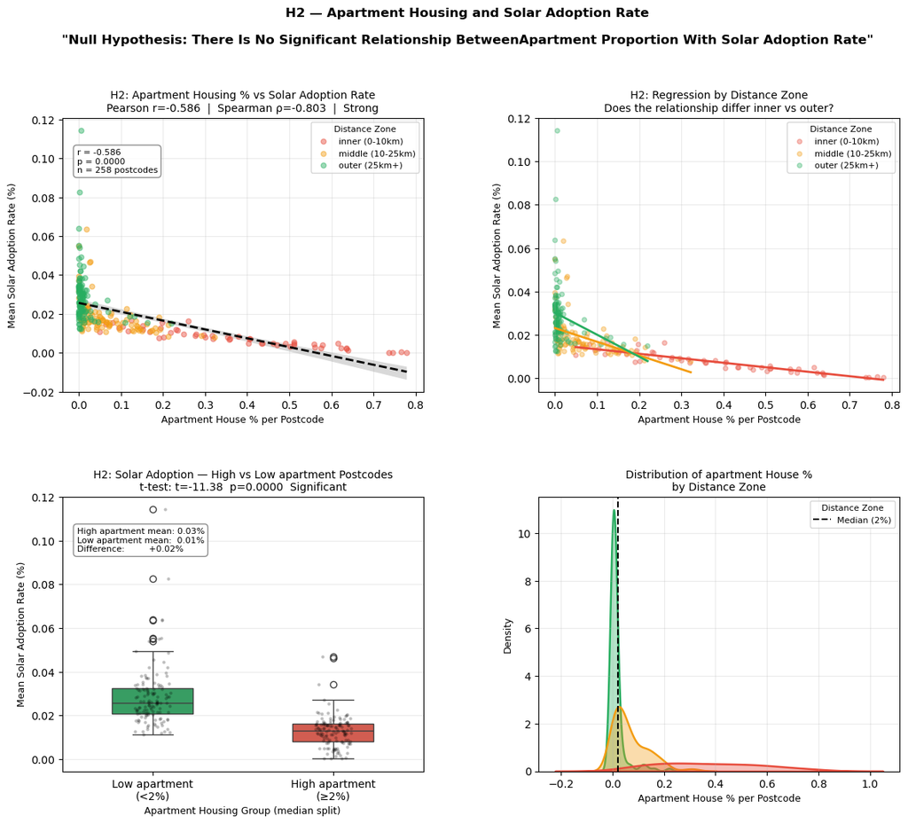

```python
# Use postcode-level cross-sectional data
df_cross = df_metro.groupby('postcode').agg(
    solar_adoption_rate  = ('solar_adoption_rate', 'mean'),
    apartment_pct        = ('apartment_pct',       'mean'),
    distance_zone        = ('distance_zone',       'first'),
).reset_index().dropna()

df_cross['postcode'] = pd.to_numeric(df_cross['postcode'], errors='coerce')
df_cross = df_cross[df_cross['postcode'].between(3000, 3999)].copy()

# Statistical tests
r_pearson,  p_pearson  = pearsonr( df_cross['apartment_pct'],
                                   df_cross['solar_adoption_rate'])
r_spearman, p_spearman = spearmanr(df_cross['apartment_pct'],
                                   df_cross['solar_adoption_rate'])

# Split into high / low apartment groups (median split)
median_apartment = df_cross['apartment_pct'].median()
high_apt = df_cross[df_cross['apartment_pct'] >= median_apartment]['solar_adoption_rate']
low_apt  = df_cross[df_cross['apartment_pct'] <  median_apartment]['solar_adoption_rate']
t_stat, p_ttest = ttest_ind(high_apt, low_apt)

# Strength label
def strength(r):
    if abs(r) > 0.5: return 'Strong'
    if abs(r) > 0.3: return 'Moderate'
    return 'Weak'

# Layout: 2×2 grid
fig = plt.figure(figsize=(14, 11))
gs  = gridspec.GridSpec(2, 2, hspace=0.38, wspace=0.32)

zone_palette = {
    'inner (0-10km)':   '#e74c3c',
    'middle (10-25km)': '#f39c12',
    'outer (25km+)':    '#27ae60',
}

# Plot 1 (top-left): Scatter + regression coloured by zone
ax1 = fig.add_subplot(gs[0, 0])

for zone, color in zone_palette.items():
    sub = df_cross[df_cross['distance_zone'] == zone]
    ax1.scatter(sub['apartment_pct'], sub['solar_adoption_rate'],
                color=color, alpha=0.45, s=22, label=zone, zorder=2)

# Overall regression line
sns.regplot(data=df_cross,
            x='apartment_pct', y='solar_adoption_rate',
            scatter=False,
            line_kws={'color': 'black', 'linewidth': 2, 'linestyle': '--'},
            ci=95, ax=ax1)

ax1.set_title('H2: Apartment Housing % vs Solar Adoption Rate\n'
              f'Pearson r={r_pearson:+.3f}  |  '
              f'Spearman ρ={r_spearman:+.3f}  |  {strength(r_pearson)}',
              fontsize=10)
ax1.set_xlabel('Apartment House % per Postcode', fontsize=9)
ax1.set_ylabel('Mean Solar Adoption Rate (%)', fontsize=9)
ax1.legend(title='Distance Zone', fontsize=8, title_fontsize=8)
ax1.annotate(
    f'r = {r_pearson:+.3f}\np = {p_pearson:.4f}\nn = {len(df_cross)} postcodes',
    xy=(0.04, 0.80), xycoords='axes fraction', fontsize=8,
    bbox=dict(boxstyle='round,pad=0.4', facecolor='white',
              edgecolor='grey', alpha=0.9)
)
ax1.grid(True, alpha=0.25)

# Plot 2 (top-right): Regression per zone
ax2 = fig.add_subplot(gs[0, 1])

for zone, color in zone_palette.items():
    sub = df_cross[df_cross['distance_zone'] == zone].dropna()
    if len(sub) < 5:
        continue
    sns.regplot(data=sub,
                x='apartment_pct', y='solar_adoption_rate',
                scatter_kws={'alpha': 0.35, 's': 18, 'color': color},
                line_kws={'color': color, 'linewidth': 2},
                ci=None, label=zone, ax=ax2)
    r_z, p_z = pearsonr(sub['apartment_pct'], sub['solar_adoption_rate'])
    print(f"{zone:<22} r={r_z:+.3f}  p={p_z:.4f}")

ax2.set_title('H2: Regression by Distance Zone\n'
              'Does the relationship differ inner vs outer?',
              fontsize=10)
ax2.set_xlabel('Apartment House % per Postcode', fontsize=9)
ax2.set_ylabel('Mean Solar Adoption Rate (%)', fontsize=9)
ax2.legend(title='Distance Zone', fontsize=8, title_fontsize=8)
ax2.grid(True, alpha=0.25)

# Plot 3 (bottom-left): Boxplot high vs low apartment
ax3 = fig.add_subplot(gs[1, 0])

df_cross['apartment_group'] = np.where(
    df_cross['apartment_pct'] >= median_apartment,
    f'High apartment\n(≥{median_apartment:.0%})',
    f'Low apartment\n(<{median_apartment:.0%})'
)

sns.boxplot(data=df_cross,
            x='apartment_group', y='solar_adoption_rate',
            palette=['#27ae60', '#e74c3c'],
            order=[f'Low apartment\n(<{median_apartment:.0%})',
                   f'High apartment\n(≥{median_apartment:.0%})'],
            width=0.45, ax=ax3)
sns.stripplot(data=df_cross,
              x='apartment_group', y='solar_adoption_rate',
              order=[f'Low apartment\n(<{median_apartment:.0%})',
                     f'High apartment\n(≥{median_apartment:.0%})'],
              color='black', alpha=0.25, size=3, ax=ax3)

ax3.set_title('H2: Solar Adoption — High vs Low apartment Postcodes\n'
              f't-test: t={t_stat:.2f}  p={p_ttest:.4f}  '
              f'{"Significant" if p_ttest < 0.05 else "Not significant"}',
              fontsize=10)
ax3.set_xlabel('Apartment Housing Group (median split)', fontsize=9)
ax3.set_ylabel('Mean Solar Adoption Rate (%)', fontsize=9)
ax3.annotate(
    f'High apartment mean: {high_det.mean():.2f}%\n'
    f'Low apartment mean:  {low_det.mean():.2f}%\n'
    f'Difference:         {high_det.mean()-low_det.mean():+.2f}%',
    xy=(0.04, 0.80), xycoords='axes fraction', fontsize=8,
    bbox=dict(boxstyle='round,pad=0.4', facecolor='white',
              edgecolor='grey', alpha=0.9)
)
ax3.grid(True, alpha=0.25, axis='y')

# Plot 4 (bottom-right): KDE distribution
ax4 = fig.add_subplot(gs[1, 1])

sns.kdeplot(data=df_cross, x='apartment_pct',
            hue='distance_zone', palette=zone_palette,
            fill=True, alpha=0.35, linewidth=1.8, ax=ax4)

ax4.axvline(median_apartment, color='black', linestyle='--',
            linewidth=1.5, label=f'Median ({median_apartment:.0%})')
ax4.set_title('Distribution of apartment House %\nby Distance Zone',
              fontsize=10)
ax4.set_xlabel('Apartment House % per Postcode', fontsize=9)
ax4.set_ylabel('Density', fontsize=9)
ax4.legend(title='Distance Zone', fontsize=8, title_fontsize=8)
ax4.grid(True, alpha=0.25)

# Overall title
fig.suptitle(
    'H2 — Apartment Housing and Solar Adoption Rate\n'
    '\n'
    '"Null Hypothesis: There Is No Significant Relationship Between'
    'Apartment Proportion With Solar Adoption Rate"',
    fontsize=12, fontweight='bold', y=1.01
)

#plt.savefig('h1_apartment_hypothesis.png', dpi=150, bbox_inches='tight')
plt.show

print("=" * 55)
print("H2 HYPOTHESIS TEST SUMMARY")
print("=" * 55)
print(f"Pearson  r = {r_pearson:+.3f}  p = {p_pearson:.5f}  "
      f"{'Significant' if p_pearson < 0.05 else 'Not significant'}")
print(f"Spearman ρ = {r_spearman:+.3f}  p = {p_spearman:.5f}  "
      f"{'Significant' if p_spearman < 0.05 else 'Not significant'}")
print(f"T-test   t = {t_stat:.3f} p = {p_ttest:.5f}  "
      f"{'Significant' if p_ttest < 0.05 else 'Not significant'}")
print(f"Strength:  {strength(r_pearson)}")
print(f"Postcodes: {len(df_cross)}")
print(f"\nConclusion:")
if p_pearson < 0.05 and r_pearson > 0:
    print("H2 - Null Hypothesis IS REJECTED to 'There Is No Significant Relationship Between Apartment Housing Proportion and Solar Adoption Rates.'")
    print("Policy: target incentives at detached-house suburbs")
    print("with currently LOW adoption (financial barrier likely)")
elif p_pearson < 0.05 and r_pearson < 0:
    print("H2 - Null Hypothesis IS REJECTED to 'There Is No Significant Relationship Between Apartment Housing Proportion and Solar Adoption Rates.'")
    print("Apartment proportion has a strong negative relationship with solar adoption rate.")
else:
    print("H2 - Null Hypothesis IS ACCEPTED to 'There Is No Significant Relationship Between Apartment Housing Proportion and Solar Adoption Rates.'")
```

**Conclusion:**

> The null hypothesis is rejected. Apartment proportion has a strong negative relationship with solar adoption rate. This suggests that apartment-heavy areas face structural barriers to rooftop solar adoption.

**Policy implication:**

> Inner-city and apartment-heavy areas require different policy solutions from detached-house suburbs. Suitable interventions may include shared solar, community batteries, embedded networks, body-corporate support and renter-inclusive solar models.

#### H3 - Null Hypothesis: There Is No Significant Relationship Between Detached House Prices and Solar Adoption Rate

```
Postcodes: 234
Correlation by distance zone:
  inner (0-10km)          r=-0.246  p=8.540e-02  n=50
  middle (10-25km)        r=-0.358  p=4.522e-04  n=92
  outer (25km+)           r=-0.291  p=4.907e-03  n=92
```

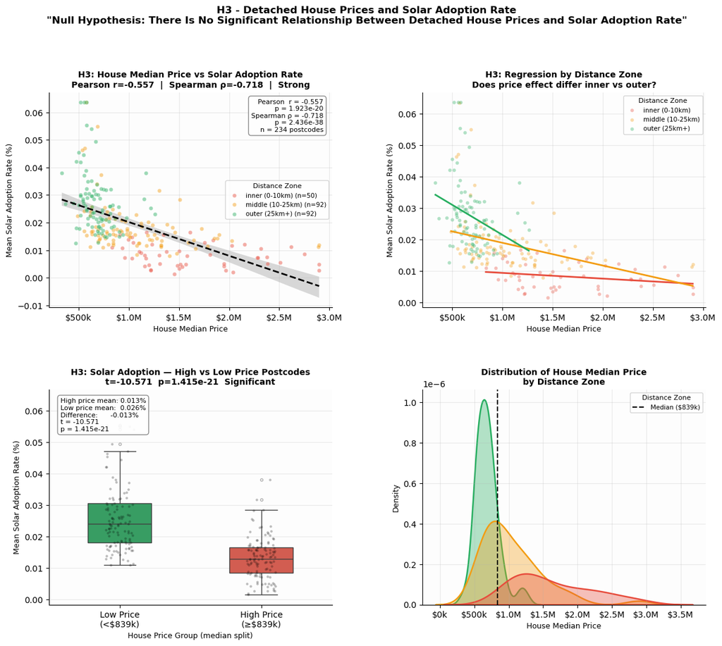

```
=======================================================
H3 HYPOTHESIS TEST SUMMARY
=======================================================
Pearson  r = -0.557  p = 1.923e-20  Significant
Spearman ρ = -0.718  p = 2.436e-38  Significant
T-test   t = -10.571 p = 1.415e-21  Significant
Strength:  Strong
Postcodes: 234

Conclusion:
   H3 - Null Hypothesis IS REJECTED but relationship is NEGATIVE
   Higher prices = lower adoption
   Likely driven by inner-city apartment concentration
   Investigate price vs apartment_pct correlation
```

```python
# Aggregate to postcode level
df_cross = df_metro_price.groupby('postcode').agg(
    solar_adoption_rate = ('solar_adoption_rate', 'mean'),
    house_median_price  = ('house_median_price',  'median'),
    distance_zone       = ('distance_zone',       'first'),
).reset_index().dropna()

df_cross['postcode'] = pd.to_numeric(df_cross['postcode'], errors='coerce')
df_cross = df_cross[df_cross['postcode'].between(3000, 3999)].copy()

# Clip outliers
df_cross['solar_adoption_rate'] = df_cross['solar_adoption_rate'].clip(
    upper=df_cross['solar_adoption_rate'].quantile(0.99))
df_cross['house_median_price']  = df_cross['house_median_price'].clip(
    upper=df_cross['house_median_price'].quantile(0.99))

print(f"Postcodes: {len(df_cross)}")

# Statistical tests
r_pearson,  p_pearson  = pearsonr( df_cross['house_median_price'],
                                    df_cross['solar_adoption_rate'])
r_spearman, p_spearman = spearmanr(df_cross['house_median_price'],
                                    df_cross['solar_adoption_rate'])

median_price = df_cross['house_median_price'].median()
high_price   = df_cross[df_cross['house_median_price'] >= median_price]['solar_adoption_rate']
low_price    = df_cross[df_cross['house_median_price'] <  median_price]['solar_adoption_rate']
t_stat, p_ttest = ttest_ind(high_price, low_price)

def strength(r):
    if abs(r) > 0.5: return 'Strong'
    if abs(r) > 0.3: return 'Moderate'
    return 'Weak'

df_cross['price_group'] = np.where(
    df_cross['house_median_price'] >= median_price,
    f'High Price\n(≥${median_price/1e3:.0f}k)',
    f'Low Price\n(<${median_price/1e3:.0f}k)'
)
order = [
    f'Low Price\n(<${median_price/1e3:.0f}k)',
    f'High Price\n(≥${median_price/1e3:.0f}k)',
]

#  Layout
fig = plt.figure(figsize=(14, 11))
gs  = gridspec.GridSpec(2, 2, hspace=0.38, wspace=0.32)

zone_palette = {
    'inner (0-10km)':   '#e74c3c',
    'middle (10-25km)': '#f39c12',
    'outer (25km+)':    '#27ae60',
}

# Plot 1: Scatter + overall regression
ax1 = fig.add_subplot(gs[0, 0])

for zone, color in zone_palette.items():
    sub = df_cross[df_cross['distance_zone'] == zone]
    ax1.scatter(sub['house_median_price'],
                sub['solar_adoption_rate'],
                color=color, alpha=0.45, s=22,
                label=f'{zone} (n={len(sub)})',
                zorder=2, edgecolors='white', linewidth=0.3)

sns.regplot(data=df_cross,
            x='house_median_price', y='solar_adoption_rate',
            scatter=False,
            line_kws={'color': 'black', 'linewidth': 2,
                      'linestyle': '--'},
            ci=95, ax=ax1)

ax1.xaxis.set_major_formatter(plt.FuncFormatter(
    lambda x, _: f'${x/1e6:.1f}M' if x >= 1e6 else f'${x/1e3:.0f}k'))
ax1.set_title(
    f'H3: House Median Price vs Solar Adoption Rate\n'
    f'Pearson r={r_pearson:+.3f}  |  '
    f'Spearman ρ={r_spearman:+.3f}  |  {strength(r_pearson)}',
    fontsize=10, fontweight='bold'
)
ax1.set_xlabel('House Median Price', fontsize=9)
ax1.set_ylabel('Mean Solar Adoption Rate (%)', fontsize=9)
ax1.legend(title='Distance Zone', fontsize=7.5, title_fontsize=8)
ax1.annotate(
    f'Pearson  r = {r_pearson:+.3f}\n'
    f'p = {p_pearson:.3e}\n'
    f'Spearman ρ = {r_spearman:+.3f}\n'
    f'p = {p_spearman:.3e}\n'
    f'n = {len(df_cross)} postcodes',
    xy=(0.97, 0.97), xycoords='axes fraction',
    ha='right', va='top', fontsize=8,
    bbox=dict(boxstyle='round,pad=0.4', facecolor='white',
              edgecolor='grey', alpha=0.9)
)
ax1.grid(True, alpha=0.25)
ax1.set_facecolor('#fdfdfd')
ax1.spines[['top', 'right']].set_visible(False)

# Plot 2: Regression per zone
ax2 = fig.add_subplot(gs[0, 1])

print("Correlation by distance zone:")
for zone, color in zone_palette.items():
    sub = df_cross[df_cross['distance_zone'] == zone].dropna()
    if len(sub) < 5:
        continue
    sns.regplot(data=sub,
                x='house_median_price', y='solar_adoption_rate',
                scatter_kws={'alpha': 0.35, 's': 18,
                             'color': color,
                             'edgecolors': 'white',
                             'linewidths': 0.3},
                line_kws={'color': color, 'linewidth': 2},
                ci=None, label=zone, ax=ax2)
    r_z, p_z = pearsonr(sub['house_median_price'],
                         sub['solar_adoption_rate'])
    print(f"  {zone:<22}  r={r_z:+.3f}  p={p_z:.3e}  n={len(sub)}")

ax2.xaxis.set_major_formatter(plt.FuncFormatter(
    lambda x, _: f'${x/1e6:.1f}M' if x >= 1e6 else f'${x/1e3:.0f}k'))
ax2.set_title(
    'H3: Regression by Distance Zone\n'
    'Does price effect differ inner vs outer?',
    fontsize=10, fontweight='bold'
)
ax2.set_xlabel('House Median Price', fontsize=9)
ax2.set_ylabel('Mean Solar Adoption Rate (%)', fontsize=9)
ax2.legend(title='Distance Zone', fontsize=7.5, title_fontsize=8)
ax2.grid(True, alpha=0.25)
ax2.set_facecolor('#fdfdfd')
ax2.spines[['top', 'right']].set_visible(False)

# Plot 3: Boxplot high vs low price
ax3 = fig.add_subplot(gs[1, 0])

# ← use 'price_group' (string label col), NOT 'house_median_price' (numeric)
sns.boxplot(data=df_cross,
            x='price_group',
            y='solar_adoption_rate',
            order=order,
            palette=['#27ae60', '#e74c3c'],
            width=0.45, ax=ax3,
            flierprops=dict(marker='o', markersize=3, alpha=0.4))

sns.stripplot(data=df_cross,
              x='price_group',
              y='solar_adoption_rate',
              order=order,
              color='black', alpha=0.25,
              size=3, ax=ax3, jitter=True)

ax3.set_title(
    f'H3: Solar Adoption — High vs Low Price Postcodes\n'
    f't={t_stat:.3f}  p={p_ttest:.3e}  '
    f'{"Significant" if p_ttest < 0.05 else "NOT significant"}',
    fontsize=10, fontweight='bold'
)
ax3.set_xlabel('House Price Group (median split)', fontsize=9)
ax3.set_ylabel('Mean Solar Adoption Rate (%)',     fontsize=9)
ax3.annotate(
    f'High price mean: {high_price.mean():.3f}%\n'
    f'Low price mean:  {low_price.mean():.3f}%\n'
    f'Difference:      {high_price.mean()-low_price.mean():+.3f}%\n'
    f't = {t_stat:.3f}\n'
    f'p = {p_ttest:.3e}',
    xy=(0.04, 0.96), xycoords='axes fraction',
    va='top', fontsize=8,
    bbox=dict(boxstyle='round,pad=0.4', facecolor='white',
              edgecolor='grey', alpha=0.9)
)
ax3.grid(True, alpha=0.25, axis='y')
ax3.set_facecolor('#fdfdfd')
ax3.spines[['top', 'right']].set_visible(False)

# Plot 4: KDE distribution
ax4 = fig.add_subplot(gs[1, 1])

# ← fix: linewidths not linewidth
sns.kdeplot(data=df_cross,
            x='house_median_price',
            hue='distance_zone',
            palette=zone_palette,
            fill=True, alpha=0.35,
            linewidths=1.8, ax=ax4,
            warn_singular=False)

ax4.axvline(median_price, color='black', linestyle='--',
            linewidth=1.5,
            label=f'Median (${median_price/1e3:.0f}k)')
ax4.xaxis.set_major_formatter(plt.FuncFormatter(
    lambda x, _: f'${x/1e6:.1f}M' if x >= 1e6 else f'${x/1e3:.0f}k'))
ax4.set_title(
    'Distribution of House Median Price\nby Distance Zone',
    fontsize=10, fontweight='bold'
)
ax4.set_xlabel('House Median Price', fontsize=9)
ax4.set_ylabel('Density',            fontsize=9)
ax4.legend(title='Distance Zone', fontsize=7.5, title_fontsize=8)
ax4.grid(True, alpha=0.25)
ax4.set_facecolor('#fdfdfd')
ax4.spines[['top', 'right']].set_visible(False)

# Overall title
fig.suptitle(
'H3 - Detached House Prices and Solar Adoption Rate\n'
'"Null Hypothesis: There Is No Significant Relationship Between Detached House Prices and Solar Adoption Rate"',
    fontsize=12, fontweight='bold', y=1.01
)

plt.tight_layout()
plt.show()

# Summary
print("\n" + "=" * 55)
print("H3 HYPOTHESIS TEST SUMMARY")
print("=" * 55)
print(f"Pearson  r = {r_pearson:+.3f}  p = {p_pearson:.3e}  "
      f"{'Significant' if p_pearson < 0.05 else 'NOT significant'}")
print(f"Spearman ρ = {r_spearman:+.3f}  p = {p_spearman:.3e}  "
      f"{'Significant' if p_spearman < 0.05 else 'NOT Not significant'}")
print(f"T-test   t = {t_stat:.3f} p = {p_ttest:.3e}  "
      f"{'Significant' if p_ttest < 0.05 else 'NOT significant'}")
print(f"Strength:  {strength(r_pearson)}")
print(f"Postcodes: {len(df_cross)}")
print(f"\nConclusion:")
if p_pearson < 0.05 and r_pearson > 0:
    print("   H3 - Null Hypothesis IS REJECTED — house price positively and")
    print("   significantly predicts solar adoption rate.")
elif p_pearson < 0.05 and r_pearson < 0:
    print("   H3 - Null Hypothesis IS REJECTED but relationship is NEGATIVE")
    print("   Higher prices = lower adoption")
    print("   Likely driven by inner-city apartment concentration")
    print("   Investigate price vs apartment_pct correlation")
else:
    print(" H3 - Null Hypothesis IS ACCEPTED")
```

**Conclusion:**

> The null hypothesis is rejected, but the relationship is negative. Higher house median price is associated with lower solar adoption rate.

> It is likely influenced by the concentration of high-price, inner-city postcodes that also have higher apartment density and lower rooftop solar suitability. Therefore, the result does not necessarily mean that higher household wealth reduces solar adoption. Instead, it may reflect the spatial and structural relationship between house prices, dwelling type and distance from CBD.

**Policy implication:**

> Further investigation should test the relationship between house price, apartment proportion and solar adoption together. Price alone should not be used as the main targeting variable.

#### H4 - Null Hypothesis: There Is No Significant Relationship Between Distance from Melbourne CBD and Solar Adoption Rate (Metro Area)

```
Postcodes: 258
Correlation by distance zone:
  inner (0-10km)          r=+0.728  p=4.589e-10  n=54
  middle (10-25km)        r=+0.605  p=1.106e-10  n=94
  outer (25km+)           r=+0.091  p=3.445e-01  n=110
```

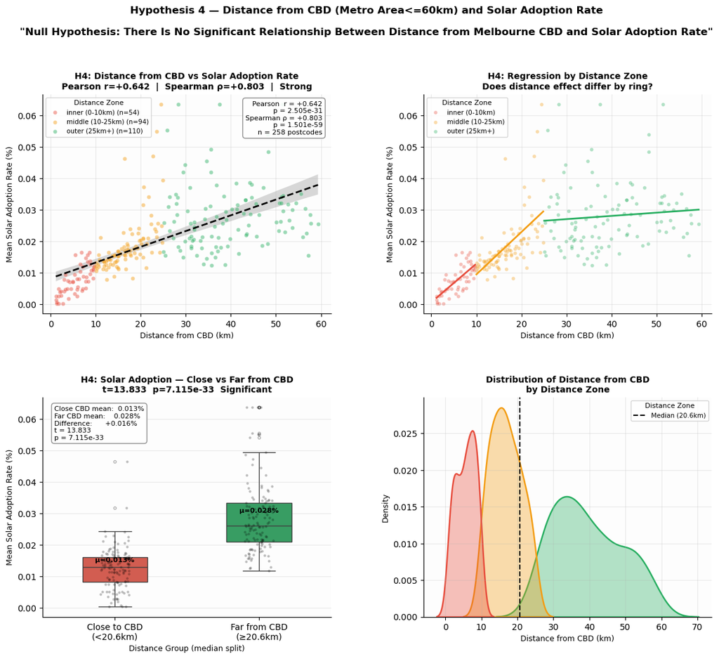

```
=======================================================
H4 HYPOTHESIS TEST SUMMARY
=======================================================
Pearson  r = +0.642  p = 2.505e-31  Significant
Spearman ρ = +0.803  p = 1.501e-59  Significant
T-test   t = 13.833  p = 7.115e-33  Significant
Strength:  Strong
Postcodes: 258

Conclusion:
  H4 - Null Hypothesis is REJECTED to 'There Is No Significant Relationship Between
  Distance from Melbourne CBD (Metro Area) and Solar Adoption Rate'.
  Outer suburbs adopt more solar than inner city.
  Policy: inner city needs structural solutions
  (shared solar); outer ring needs capacity support.
```

```python
# Extract the solar adoption rate and distance CBD km
df_cross = df_metro.groupby('postcode').agg(
    solar_adoption_rate = ('solar_adoption_rate', 'mean'),
    distance_cbd_km     = ('distance_cbd_km',     'first'),
    distance_zone       = ('distance_zone',       'first'),
).reset_index().dropna()

df_cross['postcode'] = pd.to_numeric(df_cross['postcode'], errors='coerce')
df_cross = df_cross[
    df_cross['postcode'].between(3000, 3999) &
    df_cross['distance_cbd_km'].between(0, 300)
].copy()

df_cross['solar_adoption_rate'] = df_cross['solar_adoption_rate'].clip(
    upper=df_cross['solar_adoption_rate'].quantile(0.99))

print(f"Postcodes: {len(df_cross)}")

# Statistical tests
r_pearson,  p_pearson  = pearsonr( df_cross['distance_cbd_km'],
                                    df_cross['solar_adoption_rate'])
r_spearman, p_spearman = spearmanr(df_cross['distance_cbd_km'],
                                    df_cross['solar_adoption_rate'])

median_dist  = df_cross['distance_cbd_km'].median()
high_dist    = df_cross[df_cross['distance_cbd_km'] >= median_dist]['solar_adoption_rate']
low_dist     = df_cross[df_cross['distance_cbd_km'] <  median_dist]['solar_adoption_rate']
t_stat, p_ttest = ttest_ind(high_dist, low_dist)

def strength(r):
    if abs(r) > 0.5: return 'Strong'
    if abs(r) > 0.3: return 'Moderate'
    return 'Weak'

# Create group label as separate column
df_cross['dist_group'] = np.where(
    df_cross['distance_cbd_km'] >= median_dist,
    f'Far from CBD\n(≥{median_dist:.1f}km)',
    f'Close to CBD\n(<{median_dist:.1f}km)'
)
order = [
    f'Close to CBD\n(<{median_dist:.1f}km)',
    f'Far from CBD\n(≥{median_dist:.1f}km)',
]

#  Layout
fig = plt.figure(figsize=(14, 11))
gs  = gridspec.GridSpec(2, 2, hspace=0.38, wspace=0.32)

zone_palette = {
    'inner (0-10km)':   '#e74c3c',
    'middle (10-25km)': '#f39c12',
    'outer (25km+)':    '#27ae60',
}

#  Plot 1: Scatter + overall regression
ax1 = fig.add_subplot(gs[0, 0])

for zone, color in zone_palette.items():
    sub = df_cross[df_cross['distance_zone'] == zone]
    ax1.scatter(sub['distance_cbd_km'],
                sub['solar_adoption_rate'],
                color=color, alpha=0.45, s=22,
                label=f'{zone} (n={len(sub)})',
                zorder=2, edgecolors='white', linewidth=0.3)

sns.regplot(data=df_cross,
            x='distance_cbd_km', y='solar_adoption_rate',
            scatter=False,
            line_kws={'color': 'black', 'linewidth': 2,
                      'linestyle': '--'},
            ci=95, ax=ax1)

ax1.set_title(
    f'H4: Distance from CBD vs Solar Adoption Rate\n'
    f'Pearson r={r_pearson:+.3f}  |  '
    f'Spearman ρ={r_spearman:+.3f}  |  {strength(r_pearson)}',
    fontsize=10, fontweight='bold'
)
ax1.set_xlabel('Distance from CBD (km)', fontsize=9)
ax1.set_ylabel('Mean Solar Adoption Rate (%)', fontsize=9)
ax1.legend(title='Distance Zone', fontsize=7.5, title_fontsize=8)
ax1.annotate(
    f'Pearson  r = {r_pearson:+.3f}\n'
    f'p = {p_pearson:.3e}\n'
    f'Spearman ρ = {r_spearman:+.3f}\n'
    f'p = {p_spearman:.3e}\n'
    f'n = {len(df_cross)} postcodes',
    xy=(0.97, 0.97), xycoords='axes fraction',
    ha='right', va='top', fontsize=8,
    bbox=dict(boxstyle='round,pad=0.4', facecolor='white',
              edgecolor='grey', alpha=0.9)
)
ax1.grid(True, alpha=0.25)
ax1.set_facecolor('#fdfdfd')
ax1.spines[['top', 'right']].set_visible(False)

# Plot 2: Regression per zone
ax2 = fig.add_subplot(gs[0, 1])

print("Correlation by distance zone:")
for zone, color in zone_palette.items():
    sub = df_cross[df_cross['distance_zone'] == zone].dropna()
    if len(sub) < 5:
        continue
    sns.regplot(data=sub,
                x='distance_cbd_km', y='solar_adoption_rate',
                scatter_kws={'alpha': 0.35, 's': 18,
                             'color': color,
                             'edgecolors': 'white',
                             'linewidths': 0.3},
                line_kws={'color': color, 'linewidth': 2},
                ci=None, label=zone, ax=ax2)
    r_z, p_z = pearsonr(sub['distance_cbd_km'],
                         sub['solar_adoption_rate'])
    print(f"  {zone:<22}  r={r_z:+.3f}  p={p_z:.3e}  n={len(sub)}")

ax2.set_title(
    'H4: Regression by Distance Zone\n'
    'Does distance effect differ by ring?',
    fontsize=10, fontweight='bold'
)
ax2.set_xlabel('Distance from CBD (km)', fontsize=9)
ax2.set_ylabel('Mean Solar Adoption Rate (%)', fontsize=9)
ax2.legend(title='Distance Zone', fontsize=7.5, title_fontsize=8)
ax2.grid(True, alpha=0.25)
ax2.set_facecolor('#fdfdfd')
ax2.spines[['top', 'right']].set_visible(False)

# Plot 3: Boxplot close vs far
ax3 = fig.add_subplot(gs[1, 0])

sns.boxplot(data=df_cross,
            x='dist_group',
            y='solar_adoption_rate',
            order=order,
            palette=['#e74c3c', '#27ae60'],
            width=0.45, ax=ax3,
            flierprops=dict(marker='o', markersize=3, alpha=0.4))

sns.stripplot(data=df_cross,
              x='dist_group',
              y='solar_adoption_rate',
              order=order,
              color='black', alpha=0.25,
              size=3, ax=ax3, jitter=True)

# Zone mean labels
for i, grp in enumerate(order):
    mean_val = df_cross[df_cross['dist_group'] == grp]['solar_adoption_rate'].mean()
    ax3.text(i, mean_val + 0.002,
             f'μ={mean_val:.3f}%',
             ha='center', fontsize=8,
             fontweight='bold', color='black')

ax3.set_title(
    f'H4: Solar Adoption — Close vs Far from CBD\n'
    f't={t_stat:.3f}  p={p_ttest:.3e}  '
    f'{"Significant" if p_ttest < 0.05 else "NOT significant"}',
    fontsize=10, fontweight='bold'
)
ax3.set_xlabel('Distance Group (median split)', fontsize=9)
ax3.set_ylabel('Mean Solar Adoption Rate (%)',   fontsize=9)
ax3.annotate(
    f'Close CBD mean:  {low_dist.mean():.3f}%\n'
    f'Far CBD mean:    {high_dist.mean():.3f}%\n'
    f'Difference:      {high_dist.mean()-low_dist.mean():+.3f}%\n'
    f't = {t_stat:.3f}\n'
    f'p = {p_ttest:.3e}',
    xy=(0.04, 0.96), xycoords='axes fraction',
    va='top', fontsize=8,
    bbox=dict(boxstyle='round,pad=0.4', facecolor='white',
              edgecolor='grey', alpha=0.9)
)
ax3.grid(True, alpha=0.25, axis='y')
ax3.set_facecolor('#fdfdfd')
ax3.spines[['top', 'right']].set_visible(False)

# Plot 4: KDE distribution by zone
ax4 = fig.add_subplot(gs[1, 1])

sns.kdeplot(data=df_cross,
            x='distance_cbd_km',
            hue='distance_zone',
            palette=zone_palette,
            fill=True, alpha=0.35,
            linewidths=1.8, ax=ax4,
            warn_singular=False)

ax4.axvline(median_dist, color='black', linestyle='--',
            linewidth=1.5,
            label=f'Median ({median_dist:.1f}km)')
ax4.set_title(
    'Distribution of Distance from CBD\nby Distance Zone',
    fontsize=10, fontweight='bold'
)
ax4.set_xlabel('Distance from CBD (km)', fontsize=9)
ax4.set_ylabel('Density',                fontsize=9)
ax4.legend(title='Distance Zone', fontsize=7.5, title_fontsize=8)
ax4.grid(True, alpha=0.25)
ax4.set_facecolor('#fdfdfd')
ax4.spines[['top', 'right']].set_visible(False)

# Overall title
fig.suptitle(
    'Hypothesis 4 — Distance from CBD (Metro Area<=60km) and Solar Adoption Rate\n'
    '\n'
    '"Null Hypothesis: There Is No Significant Relationship Between Distance from Melbourne CBD and Solar Adoption Rate"',
    fontsize=12, fontweight='bold', y=1.01
)

plt.tight_layout()

plt.show()

# Summary
print("\n" + "=" * 55)
print("H4 HYPOTHESIS TEST SUMMARY")
print("=" * 55)
print(f"Pearson  r = {r_pearson:+.3f}  p = {p_pearson:.3e}  "
      f"{'Significant' if p_pearson < 0.05 else 'Not significant'}")
print(f"Spearman ρ = {r_spearman:+.3f}  p = {p_spearman:.3e}  "
      f"{'Significant' if p_spearman < 0.05 else 'Not significant'}")
print(f"T-test   t = {t_stat:.3f}  p = {p_ttest:.3e}  "
      f"{'Significant' if p_ttest < 0.05 else 'Not significant'}")
print(f"Strength:  {strength(r_pearson)}")
print(f"Postcodes: {len(df_cross)}")
print(f"\nConclusion:")
if p_pearson < 0.05 and r_pearson > 0:
    print("  H4 - Null Hypothesis is REJECTED to 'There Is No Significant Relationship Between")
    print("  Distance from Melbourne CBD (Metro Area) and Solar Adoption Rate'.")
    print("  Outer suburbs adopt more solar than inner city.")
    print("  Policy: inner city needs structural solutions")
    print("  (shared solar); outer ring needs capacity support.")
elif p_pearson < 0.05 and r_pearson < 0:
    print("  H4 - Null Hypothesis is REJECTED to 'There Is No Significant Relationship Between")
    print("  Distance from Melbourne CBD (Metro Area) and Solar Adoption Rate'.")
    print("  but relationship is NEGATIVE.")
    print("  Closer to CBD = higher adoption — unexpected.")
    print("  Check if inner suburbs have unusual high adoption.")
else:
    print("  H4 - Null Hypothesis is ACCPETED to 'There Is No Significant Relationship Between")
    print("  Distance from Melbourne CBD (Metro Area) and Solar Adoption Rate'.")
```

**Conclusion:**

> The null hypothesis is rejected. Distance from Melbourne CBD has a significant positive relationship with solar adoption rate in the metro area. Outer suburbs generally adopt more solar than inner-city areas. However, the outer-zone correlation is weaker, suggesting that the relationship is strongest when comparing inner and middle metropolitan areas. Once areas are already outside the dense inner city, other factors such as dwelling structure, household profile and local market conditions may become more important.

**Policy implication:**

> Inner-city areas need structural solar solutions, while outer-ring areas may benefit from grid capacity support, battery incentives and targeted uptake programs.

#### H5 - Null Hypothesis: There Is No Significant Relationship Between Distance from Melbourne CBD and Solar Adoption Rate (All postcodes)

```
Postcodes: 353
Correlation by distance zone:
  inner (0-10km)          r=+0.728  p=4.589e-10  n=54
  middle (10-25km)        r=+0.499  p=2.277e-07  n=96
  outer (25km+)           r=+0.116  p=9.852e-02  n=203
```

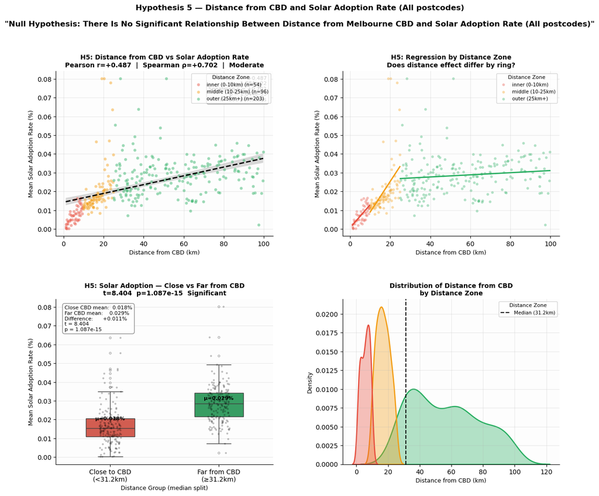

```
=======================================================
H5 HYPOTHESIS TEST SUMMARY
=======================================================
Pearson  r = +0.487  p = 1.884e-22  Significant
Spearman ρ = +0.702  p = 1.044e-53  Significant
T-test   t = 8.404   p = 1.087e-15  Significant
Strength:  Moderate
Postcodes: 353

Conclusion:
   H5 - Null Hypothesis is REJECTED to 'There Is No Significant Relationship Between Distance from Melbourne CBD and Solar Adoption Rate'.
   Outer suburbs adopt more solar than inner city.
   Policy: inner city needs structural solutions
   (shared solar); outer ring needs capacity support.
```

```python
# Extract the solar adoption rate and distance CBD km
df_cross = df_mel_filled.groupby('postcode').agg(
    solar_adoption_rate = ('solar_adoption_rate', 'mean'),
    distance_cbd_km     = ('distance_cbd_km',     'first'),
    distance_zone       = ('distance_zone',       'first'),
).reset_index().dropna()

df_cross['postcode'] = pd.to_numeric(df_cross['postcode'], errors='coerce')
df_cross = df_cross[
    df_cross['postcode'].between(3000, 3999) &
    df_cross['distance_cbd_km'].between(0, 300)
].copy()

df_cross['solar_adoption_rate'] = df_cross['solar_adoption_rate'].clip(
    upper=df_cross['solar_adoption_rate'].quantile(0.99))

print(f"Postcodes: {len(df_cross)}")

# Statistical tests
r_pearson,  p_pearson  = pearsonr( df_cross['distance_cbd_km'],
                                    df_cross['solar_adoption_rate'])
r_spearman, p_spearman = spearmanr(df_cross['distance_cbd_km'],
                                    df_cross['solar_adoption_rate'])

median_dist  = df_cross['distance_cbd_km'].median()
high_dist    = df_cross[df_cross['distance_cbd_km'] >= median_dist]['solar_adoption_rate']
low_dist     = df_cross[df_cross['distance_cbd_km'] <  median_dist]['solar_adoption_rate']
t_stat, p_ttest = ttest_ind(high_dist, low_dist)

def strength(r):
    if abs(r) > 0.5: return 'Strong'
    if abs(r) > 0.3: return 'Moderate'
    return 'Weak'

# Create group label as separate column
df_cross['dist_group'] = np.where(
    df_cross['distance_cbd_km'] >= median_dist,
    f'Far from CBD\n(≥{median_dist:.1f}km)',
    f'Close to CBD\n(<{median_dist:.1f}km)'
)
order = [
    f'Close to CBD\n(<{median_dist:.1f}km)',
    f'Far from CBD\n(≥{median_dist:.1f}km)',
]

#  Layout
fig = plt.figure(figsize=(14, 11))
gs  = gridspec.GridSpec(2, 2, hspace=0.38, wspace=0.32)

zone_palette = {
    'inner (0-10km)':   '#e74c3c',
    'middle (10-25km)': '#f39c12',
    'outer (25km+)':    '#27ae60',
}

#  Plot 1: Scatter + overall regression
ax1 = fig.add_subplot(gs[0, 0])

for zone, color in zone_palette.items():
    sub = df_cross[df_cross['distance_zone'] == zone]
    ax1.scatter(sub['distance_cbd_km'],
                sub['solar_adoption_rate'],
                color=color, alpha=0.45, s=22,
                label=f'{zone} (n={len(sub)})',
                zorder=2, edgecolors='white', linewidth=0.3)

sns.regplot(data=df_cross,
            x='distance_cbd_km', y='solar_adoption_rate',
            scatter=False,
            line_kws={'color': 'black', 'linewidth': 2,
                      'linestyle': '--'},
            ci=95, ax=ax1)

ax1.set_title(
    f'H5: Distance from CBD vs Solar Adoption Rate\n'
    f'Pearson r={r_pearson:+.3f}  |  '
    f'Spearman ρ={r_spearman:+.3f}  |  {strength(r_pearson)}',
    fontsize=10, fontweight='bold'
)
ax1.set_xlabel('Distance from CBD (km)', fontsize=9)
ax1.set_ylabel('Mean Solar Adoption Rate (%)', fontsize=9)
ax1.legend(title='Distance Zone', fontsize=7.5, title_fontsize=8)
ax1.annotate(
    f'Pearson  r = {r_pearson:+.3f}\n'
    f'p = {p_pearson:.3e}\n'
    f'Spearman ρ = {r_spearman:+.3f}\n'
    f'p = {p_spearman:.3e}\n'
    f'n = {len(df_cross)} postcodes',
    xy=(0.97, 0.97), xycoords='axes fraction',
    ha='right', va='top', fontsize=8,
    bbox=dict(boxstyle='round,pad=0.4', facecolor='white',
              edgecolor='grey', alpha=0.9)
)
ax1.grid(True, alpha=0.25)
ax1.set_facecolor('#fdfdfd')
ax1.spines[['top', 'right']].set_visible(False)

# Plot 2: Regression per zone
ax2 = fig.add_subplot(gs[0, 1])

print("Correlation by distance zone:")
for zone, color in zone_palette.items():
    sub = df_cross[df_cross['distance_zone'] == zone].dropna()
    if len(sub) < 5:
        continue
    sns.regplot(data=sub,
                x='distance_cbd_km', y='solar_adoption_rate',
                scatter_kws={'alpha': 0.35, 's': 18,
                             'color': color,
                             'edgecolors': 'white',
                             'linewidths': 0.3},
                line_kws={'color': color, 'linewidth': 2},
                ci=None, label=zone, ax=ax2)
    r_z, p_z = pearsonr(sub['distance_cbd_km'],
                         sub['solar_adoption_rate'])
    print(f"  {zone:<22}  r={r_z:+.3f}  p={p_z:.3e}  n={len(sub)}")

ax2.set_title(
    'H5: Regression by Distance Zone\n'
    'Does distance effect differ by ring?',
    fontsize=10, fontweight='bold'
)
ax2.set_xlabel('Distance from CBD (km)', fontsize=9)
ax2.set_ylabel('Mean Solar Adoption Rate (%)', fontsize=9)
ax2.legend(title='Distance Zone', fontsize=7.5, title_fontsize=8)
ax2.grid(True, alpha=0.25)
ax2.set_facecolor('#fdfdfd')
ax2.spines[['top', 'right']].set_visible(False)

# Plot 3: Boxplot close vs far
ax3 = fig.add_subplot(gs[1, 0])

sns.boxplot(data=df_cross,
            x='dist_group',
            y='solar_adoption_rate',
            order=order,
            palette=['#e74c3c', '#27ae60'],
            width=0.45, ax=ax3,
            flierprops=dict(marker='o', markersize=3, alpha=0.4))

sns.stripplot(data=df_cross,
              x='dist_group',
              y='solar_adoption_rate',
              order=order,
              color='black', alpha=0.25,
              size=3, ax=ax3, jitter=True)

# Zone mean labels
for i, grp in enumerate(order):
    mean_val = df_cross[df_cross['dist_group'] == grp]['solar_adoption_rate'].mean()
    ax3.text(i, mean_val + 0.002,
             f'μ={mean_val:.3f}%',
             ha='center', fontsize=8,
             fontweight='bold', color='black')

ax3.set_title(
    f'H5: Solar Adoption — Close vs Far from CBD\n'
    f't={t_stat:.3f}  p={p_ttest:.3e}  '
    f'{"Significant" if p_ttest < 0.05 else "NOT significant"}',
    fontsize=10, fontweight='bold'
)
ax3.set_xlabel('Distance Group (median split)', fontsize=9)
ax3.set_ylabel('Mean Solar Adoption Rate (%)',   fontsize=9)
ax3.annotate(
    f'Close CBD mean:  {low_dist.mean():.3f}%\n'
    f'Far CBD mean:    {high_dist.mean():.3f}%\n'
    f'Difference:      {high_dist.mean()-low_dist.mean():+.3f}%\n'
    f't = {t_stat:.3f}\n'
    f'p = {p_ttest:.3e}',
    xy=(0.04, 0.96), xycoords='axes fraction',
    va='top', fontsize=8,
    bbox=dict(boxstyle='round,pad=0.4', facecolor='white',
              edgecolor='grey', alpha=0.9)
)
ax3.grid(True, alpha=0.25, axis='y')
ax3.set_facecolor('#fdfdfd')
ax3.spines[['top', 'right']].set_visible(False)

# Plot 4: KDE distribution by zone
ax4 = fig.add_subplot(gs[1, 1])

sns.kdeplot(data=df_cross,
            x='distance_cbd_km',
            hue='distance_zone',
            palette=zone_palette,
            fill=True, alpha=0.35,
            linewidths=1.8, ax=ax4,
            warn_singular=False)

ax4.axvline(median_dist, color='black', linestyle='--',
            linewidth=1.5,
            label=f'Median ({median_dist:.1f}km)')
ax4.set_title(
    'Distribution of Distance from CBD\nby Distance Zone',
    fontsize=10, fontweight='bold'
)
ax4.set_xlabel('Distance from CBD (km)', fontsize=9)
ax4.set_ylabel('Density',                fontsize=9)
ax4.legend(title='Distance Zone', fontsize=7.5, title_fontsize=8)
ax4.grid(True, alpha=0.25)
ax4.set_facecolor('#fdfdfd')
ax4.spines[['top', 'right']].set_visible(False)

# Overall title
fig.suptitle(
    'Hypothesis 5 — Distance from CBD and Solar Adoption Rate (All postcodes)\n'
    '\n'
    '"Null Hypothesis: There Is No Significant Relationship Between Distance from Melbourne CBD and Solar Adoption Rate (All postcodes)"',
    fontsize=12, fontweight='bold', y=1.01
)

plt.tight_layout()
plt.savefig('h4_distance_hypothesis.png', dpi=150, bbox_inches='tight')
plt.show()

# Summary
print("\n" + "=" * 55)
print("H5 HYPOTHESIS TEST SUMMARY")
print("=" * 55)
print(f"Pearson  r = {r_pearson:+.3f}  p = {p_pearson:.3e}  "
      f"{'Significant' if p_pearson < 0.05 else 'Not significant'}")
print(f"Spearman ρ = {r_spearman:+.3f}  p = {p_spearman:.3e}  "
      f"{'Significant' if p_spearman < 0.05 else 'Not significant'}")
print(f"T-test   t = {t_stat:.3f}   p = {p_ttest:.3e}  "
      f"{'Significant' if p_ttest < 0.05 else 'Not significant'}")
print(f"Strength:  {strength(r_pearson)}")
print(f"Postcodes: {len(df_cross)}")
print(f"\nConclusion:")
if p_pearson < 0.05 and r_pearson > 0:
    print("   H5 - Null Hypothesis is REJECTED to 'There Is No Significant Relationship Between Distance from Melbourne CBD and Solar Adoption Rate'.")
    print("   Outer suburbs adopt more solar than inner city.")
    print("   Policy: inner city needs structural solutions")
    print("   (shared solar); outer ring needs capacity support.")
elif p_pearson < 0.05 and r_pearson < 0:
    print("   H5 - Null Hypothesis is REJECTED to 'There Is No Significant Relationship Between'.")
    print("   but relationship is NEGATIVE.")
    print("   Closer to CBD = higher adoption — unexpected.")
    print("   Check if inner suburbs have unusual high adoption.")
else:
    print("  H5 - Null Hypothesis is ACCPETED to 'There Is No Significant Relationship Between Distance from Melbourne CBD and Solar Adoption Rate'." )
```

**Conclusion:**

> The null hypothesis is rejected. Distance from Melbourne CBD is significantly associated with solar adoption rate across all postcodes, although the relationship is weaker than in the metro-only dataset. This suggests that distance is important, but rural and regional postcodes behave differently from metropolitan postcodes. The full-dataset result should therefore be interpreted as a broad spatial pattern rather than a pure metro adoption effect.

**Policy implication:**

> Policy design should distinguish between metro, peri-urban and rural/regional solar markets.

#### H6 - Null Hypothesis: There Is No Significant Relationship Between High Property Count and Solar Adoption Rate (Metro Area)

```python
# Aggregate to postcode level
df_cross = df_metro.groupby('postcode').agg(
    solar_adoption_rate  = ('solar_adoption_rate',  'mean'),
    solar_unit           = ('solar_unit',            'sum'),
    total_property_count = ('total_property_count',  'mean'),
    distance_zone        = ('distance_zone',         'first'),
).reset_index().dropna()

df_cross['postcode'] = pd.to_numeric(df_cross['postcode'], errors='coerce')
df_cross = df_cross[df_cross['postcode'].between(3000, 3999)].copy()

# Clip top 1% outliers
df_cross['solar_adoption_rate'] = df_cross['solar_adoption_rate'].clip(
    upper=df_cross['solar_adoption_rate'].quantile(0.99))
df_cross['total_property_count'] = df_cross['total_property_count'].clip(
    upper=df_cross['total_property_count'].quantile(0.99))
df_cross['solar_unit'] = df_cross['solar_unit'].clip(
    upper=df_cross['solar_unit'].quantile(0.99))

print(f"Postcodes: {len(df_cross)}")
print(df_cross[['total_property_count',
                'solar_adoption_rate',
                'solar_unit']].describe().round(2))

# Statistical tests — adoption rate
r_p_rate,  p_p_rate  = pearsonr( df_cross['total_property_count'],
                                  df_cross['solar_adoption_rate'])
r_s_rate,  p_s_rate  = spearmanr(df_cross['total_property_count'],
                                  df_cross['solar_adoption_rate'])

# Statistical tests — raw solar units
r_p_unit,  p_p_unit  = pearsonr( df_cross['total_property_count'],
                                  df_cross['solar_unit'])
r_s_unit,  p_s_unit  = spearmanr(df_cross['total_property_count'],
                                  df_cross['solar_unit'])

# T-test — median split on property count
median_prop  = df_cross['total_property_count'].median()
high_prop    = df_cross[df_cross['total_property_count'] >= median_prop]['solar_adoption_rate']
low_prop     = df_cross[df_cross['total_property_count'] <  median_prop]['solar_adoption_rate']
t_stat, p_ttest = ttest_ind(high_prop, low_prop)

def strength(r):
    if abs(r) > 0.5: return 'Strong'
    if abs(r) > 0.3: return 'Moderate'
    return 'Weak'

# Group label — separate column, never overwrite numeric
df_cross['prop_group'] = np.where(
    df_cross['total_property_count'] >= median_prop,
    f'Large Suburb\n(≥{median_prop:.0f} props)',
    f'Small Suburb\n(<{median_prop:.0f} props)'
)
order = [
    f'Small Suburb\n(<{median_prop:.0f} props)',
    f'Large Suburb\n(≥{median_prop:.0f} props)',
]

# Layout
fig = plt.figure(figsize=(16, 12))
gs  = gridspec.GridSpec(2, 3, hspace=0.40, wspace=0.35)

zone_palette = {
    'inner (0-10km)':   '#e74c3c',
    'middle (10-25km)': '#f39c12',
    'outer (25km+)':    '#27ae60',
}

# Plot 1: Property count vs adoption RATE
ax1 = fig.add_subplot(gs[0, 0])

for zone, color in zone_palette.items():
    sub = df_cross[df_cross['distance_zone'] == zone]
    ax1.scatter(sub['total_property_count'],
                sub['solar_adoption_rate'],
                color=color, alpha=0.45, s=22,
                label=f'{zone} (n={len(sub)})',
                zorder=2, edgecolors='white', linewidth=0.3)

sns.regplot(data=df_cross,
            x='total_property_count',
            y='solar_adoption_rate',
            scatter=False,
            line_kws={'color': 'black', 'linewidth': 2,
                      'linestyle': '--'},
            ci=95, ax=ax1)

ax1.set_title(
    f'H6a: Property Count vs Adoption RATE\n'
    f'r={r_p_rate:+.3f}  ρ={r_s_rate:+.3f}  '
    f'{strength(r_p_rate)}',
    fontsize=10, fontweight='bold'
)
ax1.set_xlabel('Total Property Count', fontsize=9)
ax1.set_ylabel('Solar Adoption Rate (%)', fontsize=9)
ax1.legend(title='Zone', fontsize=7, title_fontsize=7.5)
ax1.annotate(
    f'Pearson  r = {r_p_rate:+.3f}\n'
    f'p = {p_p_rate:.3e}\n'
    f'Spearman ρ = {r_s_rate:+.3f}\n'
    f'p = {p_s_rate:.3e}\n'
    f'n = {len(df_cross)}',
    xy=(0.97, 0.97), xycoords='axes fraction',
    ha='right', va='top', fontsize=7.5,
    bbox=dict(boxstyle='round,pad=0.35', facecolor='white',
              edgecolor='grey', alpha=0.9)
)
ax1.grid(True, alpha=0.25)
ax1.set_facecolor('#fdfdfd')
ax1.spines[['top', 'right']].set_visible(False)

# Plot 2: Property count vs raw solar UNITS
ax2 = fig.add_subplot(gs[0, 1])

for zone, color in zone_palette.items():
    sub = df_cross[df_cross['distance_zone'] == zone]
    ax2.scatter(sub['total_property_count'],
                sub['solar_unit'],
                color=color, alpha=0.45, s=22,
                label=zone, zorder=2,
                edgecolors='white', linewidth=0.3)

sns.regplot(data=df_cross,
            x='total_property_count',
            y='solar_unit',
            scatter=False,
            line_kws={'color': 'black', 'linewidth': 2,
                      'linestyle': '--'},
            ci=95, ax=ax2)

ax2.set_title(
    f'H6b: Property Count vs Raw Installations\n'
    f'r={r_p_unit:+.3f}  ρ={r_s_unit:+.3f}  '
    f'{strength(r_p_unit)}\n'
    f'(expected high — size effect only)',
    fontsize=9, fontweight='bold'
)
ax2.set_xlabel('Total Property Count', fontsize=9)
ax2.set_ylabel('Total Solar Installations', fontsize=9)
ax2.annotate(
    f'Pearson  r = {r_p_unit:+.3f}\n'
    f'p = {p_p_unit:.3e}\n'
    f'Spearman ρ = {r_s_unit:+.3f}\n'
    f'p = {p_s_unit:.3e}',
    xy=(0.04, 0.96), xycoords='axes fraction',
    va='top', fontsize=7.5,
    bbox=dict(boxstyle='round,pad=0.35', facecolor='white',
              edgecolor='grey', alpha=0.9)
)
ax2.grid(True, alpha=0.25)
ax2.set_facecolor('#fdfdfd')
ax2.spines[['top', 'right']].set_visible(False)

# Plot 3: Regression per zone
ax3 = fig.add_subplot(gs[0, 2])

print("\nCorrelation by distance zone:")
for zone, color in zone_palette.items():
    sub = df_cross[df_cross['distance_zone'] == zone].dropna()
    if len(sub) < 5:
        continue
    sns.regplot(data=sub,
                x='total_property_count',
                y='solar_adoption_rate',
                scatter_kws={'alpha': 0.35, 's': 18,
                             'color': color,
                             'edgecolors': 'white',
                             'linewidths': 0.3},
                line_kws={'color': color, 'linewidth': 2},
                ci=None, label=zone, ax=ax3)
    r_z, p_z = pearsonr(sub['total_property_count'],
                         sub['solar_adoption_rate'])
    print(f"  {zone:<22}  r={r_z:+.3f}  p={p_z:.3e}  n={len(sub)}")
```

```
Postcodes: 258
       total_property_count  solar_adoption_rate  solar_unit
count                258.00               258.00      258.00
mean                7059.74                 0.02     1491.31
std                 5794.63                 0.01     1989.00
min                   53.36                 0.00       16.00
25%                 2562.59                 0.01      404.50
50%                 6321.26                 0.02      953.50
75%                 9712.61                 0.03     1842.75
max                31050.01                 0.06    13694.63

Correlation by distance zone:
  inner (0-10km)          r=-0.097  p=4.838e-01  n=54
  middle (10-25km)        r=-0.083  p=4.254e-01  n=94
  outer (25km+)           r=-0.012  p=9.035e-01  n=110
```

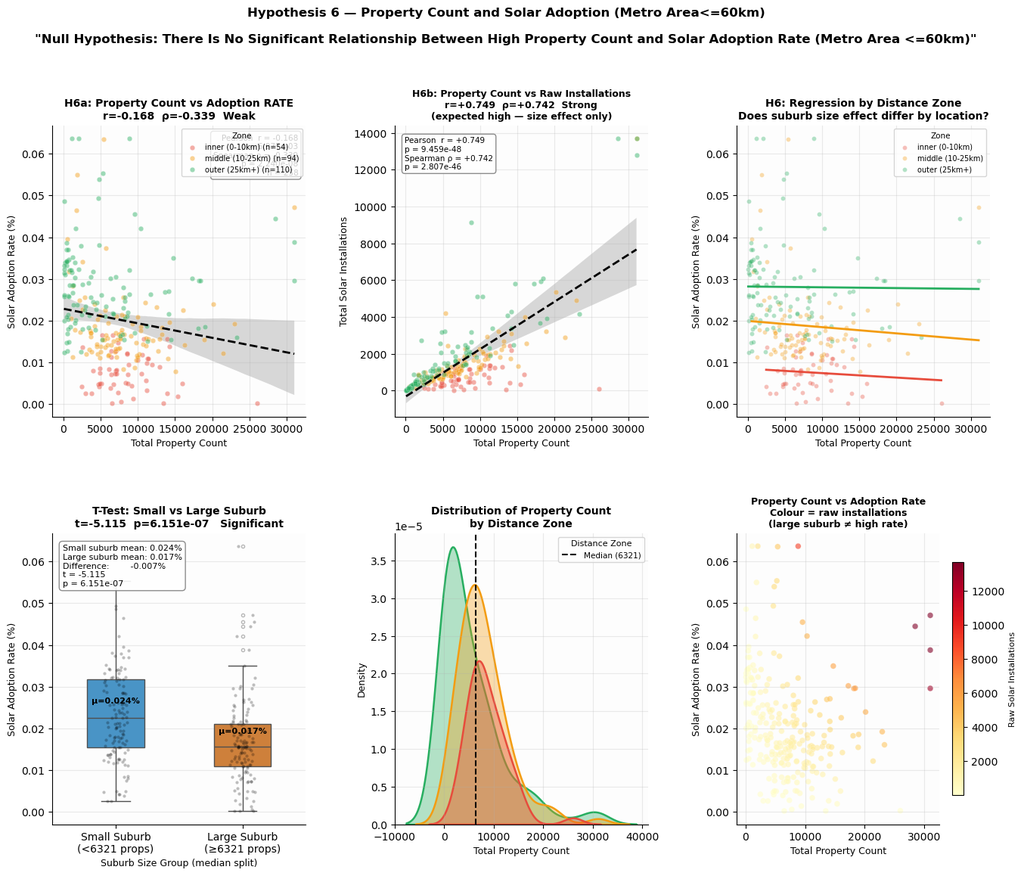

```
============================================================
H6 HYPOTHESIS TEST SUMMARY
============================================================

vs solar_adoption_rate:
  Pearson  r = -0.168  p = 6.977e-03   Significant
  Spearman ρ = -0.339  p = 2.240e-08   Significant
  T-test   t = -5.115  p = 6.151e-07   Significant
  Strength:  Weak

vs solar_unit (raw installs — size effect check):
  Pearson  r = +0.749  p = 9.459e-48   Significant
  Spearman ρ = +0.742  p = 2.807e-46   Significant
  Strength:  Strong

Postcodes: 258

Conclusion:
   H6 - Null Hypothesis is REJECTED to 'There Is No Significant Relationship Between Property Count and Solar Adoption Rate'
   Large suburbs have more raw installs (size effect)
   but not higher adoption rates per dwelling
   Policy: suburb size is NOT a targeting criterion —
   use dwelling type and socioeconomic profile instead
```

```python
ax3.set_title(
    'H6: Regression by Distance Zone\n'
    'Does suburb size effect differ by location?',
    fontsize=10, fontweight='bold'
)
ax3.set_xlabel('Total Property Count', fontsize=9)
ax3.set_ylabel('Solar Adoption Rate (%)', fontsize=9)
ax3.legend(title='Zone', fontsize=7, title_fontsize=7.5)
ax3.grid(True, alpha=0.25)
ax3.set_facecolor('#fdfdfd')
ax3.spines[['top', 'right']].set_visible(False)

#Plot 4: Boxplot small vs large suburb
ax4 = fig.add_subplot(gs[1, 0])

sns.boxplot(data=df_cross,
            x='prop_group',
            y='solar_adoption_rate',
            order=order,
            palette=['#3498db', '#e67e22'],
            width=0.45, ax=ax4,
            flierprops=dict(marker='o', markersize=3, alpha=0.4))

sns.stripplot(data=df_cross,
              x='prop_group',
              y='solar_adoption_rate',
              order=order,
              color='black', alpha=0.25,
              size=3, ax=ax4, jitter=True)

for i, grp in enumerate(order):
    mean_val = df_cross[
        df_cross['prop_group'] == grp
    ]['solar_adoption_rate'].mean()
    ax4.text(i, mean_val + 0.002,
             f'μ={mean_val:.3f}%',
             ha='center', fontsize=8,
             fontweight='bold', color='black')

ax4.set_title(
    f'T-Test: Small vs Large Suburb\n'
    f't={t_stat:.3f}  p={p_ttest:.3e}  '
    f'{" Significant" if p_ttest < 0.05 else " NOT significant"}',
    fontsize=10, fontweight='bold'
)
ax4.set_xlabel('Suburb Size Group (median split)', fontsize=9)
ax4.set_ylabel('Solar Adoption Rate (%)',          fontsize=9)
ax4.annotate(
    f'Small suburb mean: {low_prop.mean():.3f}%\n'
    f'Large suburb mean: {high_prop.mean():.3f}%\n'
    f'Difference:        {high_prop.mean()-low_prop.mean():+.3f}%\n'
    f't = {t_stat:.3f}\n'
    f'p = {p_ttest:.3e}',
    xy=(0.04, 0.96), xycoords='axes fraction',
    va='top', fontsize=8,
    bbox=dict(boxstyle='round,pad=0.4', facecolor='white',
              edgecolor='grey', alpha=0.9)
)
ax4.grid(True, alpha=0.25, axis='y')
ax4.set_facecolor('#fdfdfd')
ax4.spines[['top', 'right']].set_visible(False)

# Plot 5: KDE distribution by zone
ax5 = fig.add_subplot(gs[1, 1])

sns.kdeplot(data=df_cross,
            x='total_property_count',
            hue='distance_zone',
            palette=zone_palette,
            fill=True, alpha=0.35,
            linewidths=1.8, ax=ax5,
            warn_singular=False)

ax5.axvline(median_prop, color='black', linestyle='--',
            linewidth=1.5,
            label=f'Median ({median_prop:.0f})')
ax5.set_title(
    'Distribution of Property Count\nby Distance Zone',
    fontsize=10, fontweight='bold'
)
ax5.set_xlabel('Total Property Count', fontsize=9)
ax5.set_ylabel('Density',              fontsize=9)
ax5.legend(title='Distance Zone', fontsize=7.5, title_fontsize=8)
ax5.grid(True, alpha=0.25)
ax5.set_facecolor('#fdfdfd')
ax5.spines[['top', 'right']].set_visible(False)

# Plot 6: Key insight — why raw installs misleads
ax6 = fig.add_subplot(gs[1, 2])

ax6.scatter(df_cross['total_property_count'],
            df_cross['solar_adoption_rate'],
            c=df_cross['solar_unit'],
            cmap='YlOrRd', alpha=0.6, s=30,
            edgecolors='white', linewidth=0.2)

sm = plt.cm.ScalarMappable(cmap='YlOrRd',
     norm=plt.Normalize(df_cross['solar_unit'].min(),
                        df_cross['solar_unit'].max()))
sm.set_array([])
cbar = plt.colorbar(sm, ax=ax6, shrink=0.8)
cbar.set_label('Raw Solar Installations', fontsize=8)

ax6.set_title(
    'Property Count vs Adoption Rate\n'
    'Colour = raw installations\n'
    '(large suburb ≠ high rate)',
    fontsize=9, fontweight='bold'
)
ax6.set_xlabel('Total Property Count', fontsize=9)
ax6.set_ylabel('Solar Adoption Rate (%)', fontsize=9)
ax6.grid(True, alpha=0.25)
ax6.set_facecolor('#fdfdfd')
ax6.spines[['top', 'right']].set_visible(False)

# Overall title
fig.suptitle(
    'Hypothesis 6 — Property Count and Solar Adoption (Metro Area<=60km)\n'
    '\n'
    '"Null Hypothesis: There Is No Significant Relationship Between High Property Count and Solar Adoption Rate (Metro Area <=60km)"',
    fontsize=12, fontweight='bold', y=1.01
)

plt.tight_layout()
plt.show()

# Summary
print("\n" + "=" * 60)
print("H6 HYPOTHESIS TEST SUMMARY")
print("=" * 60)
print(f"\nvs solar_adoption_rate:")
print(f"  Pearson  r = {r_p_rate:+.3f}  p = {p_p_rate:.3e}  "
      f"{' Significant' if p_p_rate < 0.05 else ' NOT significant'}")
print(f"  Spearman ρ = {r_s_rate:+.3f}  p = {p_s_rate:.3e}  "
      f"{' Significant' if p_s_rate < 0.05 else ' NOT significant'}")
print(f"  T-test   t = {t_stat:.3f}  p = {p_ttest:.3e}  "
      f"{' Significant' if p_ttest < 0.05 else ' NOT significant'}")
print(f"  Strength:  {strength(r_p_rate)}")

print(f"\nvs solar_unit (raw installs — size effect check):")
print(f"  Pearson  r = {r_p_unit:+.3f}  p = {p_p_unit:.3e}  "
      f"{' Significant' if p_p_unit < 0.05 else ' NOT significant'}")
print(f"  Spearman ρ = {r_s_unit:+.3f}  p = {p_s_unit:.3e}  "
      f"{' Significant' if p_s_unit < 0.05 else ' NOT significant'}")
print(f"  Strength:  {strength(r_p_unit)}")

print(f"\nPostcodes: {len(df_cross)}")
print("\nConclusion:")
if p_p_rate >= 0.05 or abs(r_p_rate) < 0.3:
    print("   H6 - Null Hypothesis is REJECTED to 'There Is No Significant Relationship Between Property Count and Solar Adoption Rate'")
    print("   Large suburbs have more raw installs (size effect)")
    print("   but not higher adoption rates per dwelling")
    print("   Policy: suburb size is NOT a targeting criterion —")
    print("   use dwelling type and socioeconomic profile instead")
elif r_p_rate > 0 and p_p_rate < 0.05:
    print("   H6 - Null Hypothesis is REJECTED to 'There Is No Significant Relationship Between Property Count and Solar Adoption Rate'.")
    print("   larger suburbs show higher rates too")
    print("   Investigate whether this is driven by outer suburbs")
    print("   (large AND detached) confounding the result")
else:
    print("   H6 - Null Hypothesis is ACCEPTED TO 'There Is No Significant Relationship Between Property Count and Solar Adoption Rate'.")
    print("   May reflect dense inner-city postcodes with many")
    print("   apartments counted in total_property_count")
```

**Conclusion:**

> The null hypothesis is rejected. Property count has a weak but statistically significant negative relationship with solar adoption rate in the metro area. However, property count has a strong positive relationship with raw solar installations. This means large suburbs have more total installations because they have more properties, but they do not necessarily have higher adoption rates per dwelling.

**Policy implication:**

> Suburb size alone should not be used as a targeting criterion. Policy should focus more on dwelling type, adoption gap, rooftop suitability and socioeconomic barriers.

#### H7 - Null Hypothesis: There Is No Significant Relationship Between High Property Count and Solar Adoption Rate (All postcodes)

```python
# Aggregate to postcode level
df_cross = df_mel_filled.groupby('postcode').agg(
    solar_adoption_rate  = ('solar_adoption_rate',  'mean'),
    solar_unit           = ('solar_unit',            'sum'),
    total_property_count = ('total_property_count',  'mean'),
    distance_zone        = ('distance_zone',         'first'),
).reset_index().dropna()

df_cross['postcode'] = pd.to_numeric(df_cross['postcode'], errors='coerce')
df_cross = df_cross[df_cross['postcode'].between(3000, 3999)].copy()

# Clip top 1% outliers
df_cross['solar_adoption_rate'] = df_cross['solar_adoption_rate'].clip(
    upper=df_cross['solar_adoption_rate'].quantile(0.99))
df_cross['total_property_count'] = df_cross['total_property_count'].clip(
    upper=df_cross['total_property_count'].quantile(0.99))
df_cross['solar_unit'] = df_cross['solar_unit'].clip(
    upper=df_cross['solar_unit'].quantile(0.99))

print(f"Postcodes: {len(df_cross)}")
print(df_cross[['total_property_count',
                'solar_adoption_rate',
                'solar_unit']].describe().round(2))

#Statistical tests — adoption rate
r_p_rate,  p_p_rate  = pearsonr( df_cross['total_property_count'],
                                  df_cross['solar_adoption_rate'])
r_s_rate,  p_s_rate  = spearmanr(df_cross['total_property_count'],
                                  df_cross['solar_adoption_rate'])

# Statistical tests — raw solar units
r_p_unit,  p_p_unit  = pearsonr( df_cross['total_property_count'],
                                  df_cross['solar_unit'])
r_s_unit,  p_s_unit  = spearmanr(df_cross['total_property_count'],
                                  df_cross['solar_unit'])

# T-test — median split on property count
median_prop  = df_cross['total_property_count'].median()
high_prop    = df_cross[df_cross['total_property_count'] >= median_prop]['solar_adoption_rate']
low_prop     = df_cross[df_cross['total_property_count'] <  median_prop]['solar_adoption_rate']
t_stat, p_ttest = ttest_ind(high_prop, low_prop)

def strength(r):
    if abs(r) > 0.5: return 'Strong'
    if abs(r) > 0.3: return 'Moderate'
    return 'Weak'

# Group label — separate column, never overwrite numeric
df_cross['prop_group'] = np.where(
    df_cross['total_property_count'] >= median_prop,
    f'Large Suburb\n(≥{median_prop:.0f} props)',
    f'Small Suburb\n(<{median_prop:.0f} props)'
)
order = [
    f'Small Suburb\n(<{median_prop:.0f} props)',
    f'Large Suburb\n(≥{median_prop:.0f} props)',
]

#  Layout
fig = plt.figure(figsize=(16, 12))
gs  = gridspec.GridSpec(2, 3, hspace=0.40, wspace=0.35)

zone_palette = {
    'inner (0-10km)':   '#e74c3c',
    'middle (10-25km)': '#f39c12',
    'outer (25km+)':    '#27ae60',
}

# Plot 1: Property count vs adoption RATE
ax1 = fig.add_subplot(gs[0, 0])

for zone, color in zone_palette.items():
    sub = df_cross[df_cross['distance_zone'] == zone]
    ax1.scatter(sub['total_property_count'],
                sub['solar_adoption_rate'],
                color=color, alpha=0.45, s=22,
                label=f'{zone} (n={len(sub)})',
                zorder=2, edgecolors='white', linewidth=0.3)

sns.regplot(data=df_cross,
            x='total_property_count',
            y='solar_adoption_rate',
            scatter=False,
            line_kws={'color': 'black', 'linewidth': 2,
                      'linestyle': '--'},
            ci=95, ax=ax1)

ax1.set_title(
    f'H7a: Property Count vs Adoption RATE\n'
    f'r={r_p_rate:+.3f}  ρ={r_s_rate:+.3f}  '
    f'{strength(r_p_rate)}',
    fontsize=10, fontweight='bold'
)
ax1.set_xlabel('Total Property Count', fontsize=9)
ax1.set_ylabel('Solar Adoption Rate (%)', fontsize=9)
ax1.legend(title='Zone', fontsize=7, title_fontsize=7.5)
ax1.annotate(
    f'Pearson  r = {r_p_rate:+.3f}\n'
    f'p = {p_p_rate:.3e}\n'
    f'Spearman ρ = {r_s_rate:+.3f}\n'
    f'p = {p_s_rate:.3e}\n'
    f'n = {len(df_cross)}',
    xy=(0.97, 0.97), xycoords='axes fraction',
    ha='right', va='top', fontsize=7.5,
    bbox=dict(boxstyle='round,pad=0.35', facecolor='white',
              edgecolor='grey', alpha=0.9)
)
ax1.grid(True, alpha=0.25)
ax1.set_facecolor('#fdfdfd')
ax1.spines[['top', 'right']].set_visible(False)

# Plot 2: Property count vs raw solar UNITS
ax2 = fig.add_subplot(gs[0, 1])

for zone, color in zone_palette.items():
    sub = df_cross[df_cross['distance_zone'] == zone]
    ax2.scatter(sub['total_property_count'],
                sub['solar_unit'],
                color=color, alpha=0.45, s=22,
                label=zone, zorder=2,
                edgecolors='white', linewidth=0.3)

sns.regplot(data=df_cross,
            x='total_property_count',
            y='solar_unit',
            scatter=False,
            line_kws={'color': 'black', 'linewidth': 2,
                      'linestyle': '--'},
            ci=95, ax=ax2)

ax2.set_title(
    f'H7b: Property Count vs Raw Installations\n'
    f'r={r_p_unit:+.3f}  ρ={r_s_unit:+.3f}  '
    f'{strength(r_p_unit)}\n'
    f'(expected high — size effect only)',
    fontsize=9, fontweight='bold'
)
ax2.set_xlabel('Total Property Count', fontsize=9)
ax2.set_ylabel('Total Solar Installations', fontsize=9)
ax2.annotate(
    f'Pearson  r = {r_p_unit:+.3f}\n'
    f'p = {p_p_unit:.3e}\n'
    f'Spearman ρ = {r_s_unit:+.3f}\n'
    f'p = {p_s_unit:.3e}',
    xy=(0.04, 0.96), xycoords='axes fraction',
    va='top', fontsize=7.5,
    bbox=dict(boxstyle='round,pad=0.35', facecolor='white',
              edgecolor='grey', alpha=0.9)
)
ax2.grid(True, alpha=0.25)
ax2.set_facecolor('#fdfdfd')
ax2.spines[['top', 'right']].set_visible(False)

# Plot 3: Regression per zone
ax3 = fig.add_subplot(gs[0, 2])

print("\nCorrelation by distance zone:")
for zone, color in zone_palette.items():
    sub = df_cross[df_cross['distance_zone'] == zone].dropna()
    if len(sub) < 5:
        continue
    sns.regplot(data=sub,
                x='total_property_count',
                y='solar_adoption_rate',
                scatter_kws={'alpha': 0.35, 's': 18,
                             'color': color,
                             'edgecolors': 'white',
                             'linewidths': 0.3},
                line_kws={'color': color, 'linewidth': 2},
                ci=None, label=zone, ax=ax3)
    r_z, p_z = pearsonr(sub['total_property_count'],
                         sub['solar_adoption_rate'])
    print(f"  {zone:<22}  r={r_z:+.3f}  p={p_z:.3e}  n={len(sub)}")
```

```
Postcodes: 353
       total_property_count  solar_adoption_rate  solar_unit
count                353.00               353.00      353.00
mean                5766.85                 0.02     1231.43
std                 5511.92                 0.01     1600.62
min                    3.00                 0.00        2.00
25%                 1210.93                 0.01      284.00
50%                 4657.62                 0.02      783.00
75%                 8553.07                 0.03     1507.00
max                27211.11                 0.08    10881.72

Correlation by distance zone:
  inner (0-10km)          r=-0.097  p=4.838e-01  n=54
  middle (10-25km)        r=-0.240  p=1.861e-02  n=96
  outer (25km+)           r=-0.125  p=7.669e-02  n=203
```

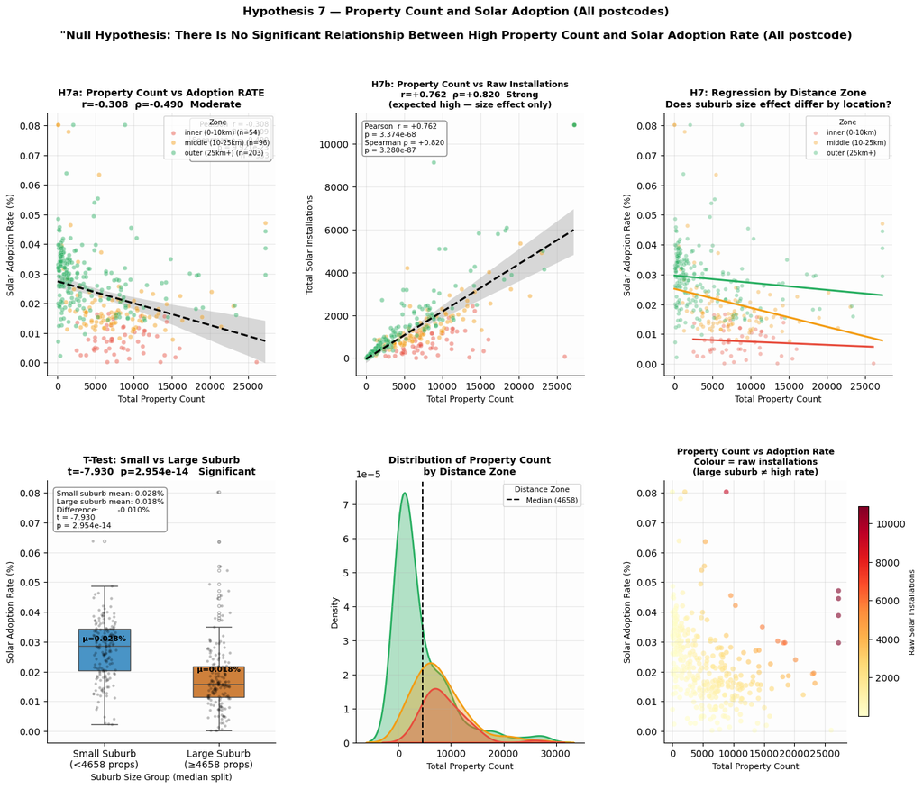

```
============================================================
H7 HYPOTHESIS TEST SUMMARY
============================================================

vs solar_adoption_rate:
  Pearson  r = -0.308  p = 3.234e-09   Significant
  Spearman ρ = -0.490  p = 9.921e-23   Significant
  T-test   t = -7.930  p = 2.954e-14   Significant
  Strength:  Moderate

vs solar_unit (raw installs — size effect check):
  Pearson  r = +0.762  p = 3.374e-68   Significant
  Spearman ρ = +0.820  p = 3.280e-87   Significant
  Strength:  Strong

Postcodes: 353

Conclusion:
   H7 - Null Hypothesis is REJECTED to 'There Is No Significant Relationship Between Property Count and Solar Adoption Rate'.
   May reflect dense inner-city postcodes with many
   apartments counted in total_property_count
```

```python
ax3.set_title(
    'H7: Regression by Distance Zone\n'
    'Does suburb size effect differ by location?',
    fontsize=10, fontweight='bold'
)
ax3.set_xlabel('Total Property Count', fontsize=9)
ax3.set_ylabel('Solar Adoption Rate (%)', fontsize=9)
ax3.legend(title='Zone', fontsize=7, title_fontsize=7.5)
ax3.grid(True, alpha=0.25)
ax3.set_facecolor('#fdfdfd')
ax3.spines[['top', 'right']].set_visible(False)

# Plot 4: Boxplot small vs large suburb
ax4 = fig.add_subplot(gs[1, 0])

sns.boxplot(data=df_cross,
            x='prop_group',
            y='solar_adoption_rate',
            order=order,
            palette=['#3498db', '#e67e22'],
            width=0.45, ax=ax4,
            flierprops=dict(marker='o', markersize=3, alpha=0.4))

sns.stripplot(data=df_cross,
              x='prop_group',
              y='solar_adoption_rate',
              order=order,
              color='black', alpha=0.25,
              size=3, ax=ax4, jitter=True)

for i, grp in enumerate(order):
    mean_val = df_cross[
        df_cross['prop_group'] == grp
    ]['solar_adoption_rate'].mean()
    ax4.text(i, mean_val + 0.002,
             f'μ={mean_val:.3f}%',
             ha='center', fontsize=8,
             fontweight='bold', color='black')

ax4.set_title(
    f'T-Test: Small vs Large Suburb\n'
    f't={t_stat:.3f}  p={p_ttest:.3e}  '
    f'{" Significant" if p_ttest < 0.05 else " NOT significant"}',
    fontsize=10, fontweight='bold'
)
ax4.set_xlabel('Suburb Size Group (median split)', fontsize=9)
ax4.set_ylabel('Solar Adoption Rate (%)',          fontsize=9)
ax4.annotate(
    f'Small suburb mean: {low_prop.mean():.3f}%\n'
    f'Large suburb mean: {high_prop.mean():.3f}%\n'
    f'Difference:        {high_prop.mean()-low_prop.mean():+.3f}%\n'
    f't = {t_stat:.3f}\n'
    f'p = {p_ttest:.3e}',
    xy=(0.04, 0.96), xycoords='axes fraction',
    va='top', fontsize=8,
    bbox=dict(boxstyle='round,pad=0.4', facecolor='white',
              edgecolor='grey', alpha=0.9)
)
ax4.grid(True, alpha=0.25, axis='y')
ax4.set_facecolor('#fdfdfd')
ax4.spines[['top', 'right']].set_visible(False)

# Plot 5: KDE distribution by zone
ax5 = fig.add_subplot(gs[1, 1])

sns.kdeplot(data=df_cross,
            x='total_property_count',
            hue='distance_zone',
            palette=zone_palette,
            fill=True, alpha=0.35,
            linewidths=1.8, ax=ax5,
            warn_singular=False)

ax5.axvline(median_prop, color='black', linestyle='--',
            linewidth=1.5,
            label=f'Median ({median_prop:.0f})')
ax5.set_title(
    'Distribution of Property Count\nby Distance Zone',
    fontsize=10, fontweight='bold'
)
ax5.set_xlabel('Total Property Count', fontsize=9)
ax5.set_ylabel('Density',              fontsize=9)
ax5.legend(title='Distance Zone', fontsize=7.5, title_fontsize=8)
ax5.grid(True, alpha=0.25)
ax5.set_facecolor('#fdfdfd')
ax5.spines[['top', 'right']].set_visible(False)

# Plot 6: Key insight — why raw installs misleads
ax6 = fig.add_subplot(gs[1, 2])

ax6.scatter(df_cross['total_property_count'],
            df_cross['solar_adoption_rate'],
            c=df_cross['solar_unit'],
            cmap='YlOrRd', alpha=0.6, s=30,
            edgecolors='white', linewidth=0.2)

sm = plt.cm.ScalarMappable(cmap='YlOrRd',
     norm=plt.Normalize(df_cross['solar_unit'].min(),
                        df_cross['solar_unit'].max()))
sm.set_array([])
cbar = plt.colorbar(sm, ax=ax6, shrink=0.8)
cbar.set_label('Raw Solar Installations', fontsize=8)

ax6.set_title(
    'Property Count vs Adoption Rate\n'
    'Colour = raw installations\n'
    '(large suburb ≠ high rate)',
    fontsize=9, fontweight='bold'
)
ax6.set_xlabel('Total Property Count', fontsize=9)
ax6.set_ylabel('Solar Adoption Rate (%)', fontsize=9)
ax6.grid(True, alpha=0.25)
ax6.set_facecolor('#fdfdfd')
ax6.spines[['top', 'right']].set_visible(False)

# Overall title
fig.suptitle(
    'Hypothesis 7 — Property Count and Solar Adoption (All postcodes)\n'
    '\n'
    '"Null Hypothesis: There Is No Significant Relationship Between High Property Count and Solar Adoption Rate (All postcode)',
    fontsize=12, fontweight='bold', y=1.01
)

plt.tight_layout()

plt.show()

# Summary
print("\n" + "=" * 60)
print("H7 HYPOTHESIS TEST SUMMARY")
print("=" * 60)
print(f"\nvs solar_adoption_rate:")
print(f"  Pearson  r = {r_p_rate:+.3f}  p = {p_p_rate:.3e}  "
      f"{' Significant' if p_p_rate < 0.05 else ' NOT significant'}")
print(f"  Spearman ρ = {r_s_rate:+.3f}  p = {p_s_rate:.3e}  "
      f"{' Significant' if p_s_rate < 0.05 else ' NOT significant'}")
print(f"  T-test   t = {t_stat:.3f}  p = {p_ttest:.3e}  "
      f"{' Significant' if p_ttest < 0.05 else ' NOT significant'}")
print(f"  Strength:  {strength(r_p_rate)}")

print(f"\nvs solar_unit (raw installs — size effect check):")
print(f"  Pearson  r = {r_p_unit:+.3f}  p = {p_p_unit:.3e}  "
      f"{' Significant' if p_p_unit < 0.05 else ' NOT significant'}")
print(f"  Spearman ρ = {r_s_unit:+.3f}  p = {p_s_unit:.3e}  "
      f"{' Significant' if p_s_unit < 0.05 else ' NOT significant'}")
print(f"  Strength:  {strength(r_p_unit)}")

print(f"\nPostcodes: {len(df_cross)}")
print("\nConclusion:")
if p_p_rate >= 0.05 or abs(r_p_rate) < 0.3:
    print("   H7 - Null Hypothesis is REJECTED to 'There Is No Significant Relationship Between Property Count and Solar Adoption Rate'")
    print("   Large suburbs have more raw installs (size effect)")
    print("   but not higher adoption rates per dwelling")
    print("   Policy: suburb size is NOT a targeting criterion —")
    print("   use dwelling type and socioeconomic profile instead")
elif r_p_rate > 0 and p_p_rate < 0.05:
    print("   H7 - Null Hypothesis is REJECTED to 'There Is No Significant Relationship Between Property Count and Solar Adoption Rate'.")
    print("   larger suburbs show higher rates too")
    print("   Investigate whether this is driven by outer suburbs")
    print("   (large AND detached) confounding the result")
elif r_p_rate < 0 and p_p_rate < 0.05:
    print("   H7 - Null Hypothesis is REJECTED to 'There Is No Significant Relationship Between Property Count and Solar Adoption Rate'.")
    print("   May reflect dense inner-city postcodes with many")
    print("   apartments counted in total_property_count")
else:
    print("   H7 - Null Hypothesis is ACCEPTED to 'There Is No Significant Relationship Between Property Count and Solar Adoption Rate'.")
```

**Conclusion:**

> The null hypothesis is rejected. Across all postcodes, high property count has a significant negative relationship with solar adoption rate, but a strong positive relationship with raw installation count. This suggests that large property-count areas may include dense inner-city or apartment-heavy postcodes, where many dwellings exist but rooftop solar adoption per dwelling is lower.

**Policy implication:**

> All-postcode targeting should not prioritise high property-count areas alone. High property count identifies market size, not adoption efficiency. Programs should combine property count with dwelling structure, current adoption rate and spatial context.

### Section 4 - K-Mean Clustering Analysis

KMeans clustering was used to group postcodes with similar solar adoption characteristics and identify meaningful market segments.

The second model used the df_mel_filled dataset, which includes all available postcodes. This broader analysis captures metro, regional and rural areas, helping identify wider market differences and unusual postcode segments.

Using both datasets allows metropolitan adoption patterns to be compared with broader postcode-level behaviours and supports more targeted policy interpretation.

#### KMeans Clustering - Metro Area with House Price (<=60km)

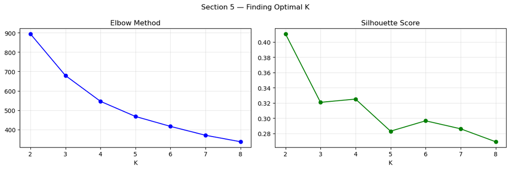

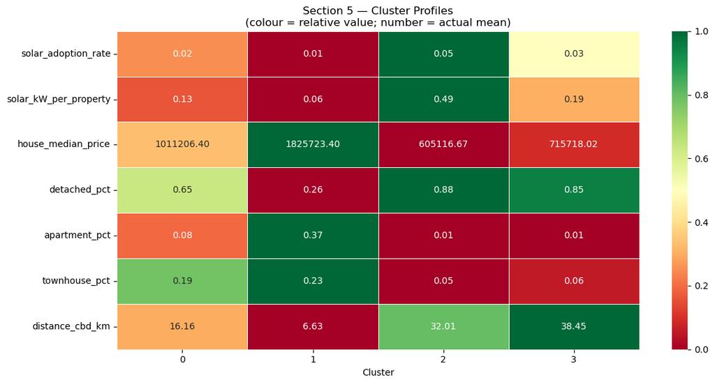

```
=== CLUSTER POLICY INTERPRETATION ===
         solar_adoption_rate  solar_kW_per_property  house_median_price  detached_pct  apartment_pct  townhouse_pct  distance_cbd_km
cluster
0                       0.02                   0.13          1011206.40          0.65           0.08           0.19            16.16
1                       0.01                   0.06          1825723.40          0.26           0.37           0.23             6.63
2                       0.05                   0.49           605116.67          0.88           0.01           0.05            32.01
3                       0.03                   0.19           715718.02          0.85           0.01           0.06            38.45
```

```python
from sklearn.preprocessing import StandardScaler
from sklearn.cluster import KMeans
from sklearn.metrics import silhouette_score

df_cross = df_metro_price.groupby('postcode').agg(
    solar_adoption_rate  = ('solar_adoption_rate',   'median'),
    solar_kW_per_property= ('solar_kW_per_property', 'median'),
    house_median_price   =('house_median_price',     'median'),
    detached_pct         = ('detached_pct',          'median'),
    apartment_pct        = ('apartment_pct',         'median'),
    townhouse_pct        = ('townhouse_pct',         'median'),
    distance_cbd_km      = ('distance_cbd_km',       'first'),

).reset_index().dropna()

metro_cluster_features = [
    'solar_adoption_rate', 'solar_kW_per_property','house_median_price',
    'detached_pct', 'apartment_pct','townhouse_pct', 'distance_cbd_km',

]

df_cluster = df_cross[metro_cluster_features].dropna()
valid_idx  = df_cluster.index

scaler   = StandardScaler()
X_scaled = scaler.fit_transform(df_cluster)

# Find optimal K with Elbow Method and Silhouette Score
inertias, silhouettes = [], []
for k in range(2, 9):
    km  = KMeans(n_clusters=k, random_state=42, n_init=10)
    lbl = km.fit_predict(X_scaled)
    inertias.append(km.inertia_)
    silhouettes.append(silhouette_score(X_scaled, lbl))

fig, (ax1, ax2) = plt.subplots(1, 2, figsize=(12, 4))
ax1.plot(range(2,9), inertias,    'bo-'); ax1.set_title('Elbow Method')
ax2.plot(range(2,9), silhouettes, 'go-'); ax2.set_title('Silhouette Score')
for ax in [ax1, ax2]:
    ax.set_xlabel('K'); ax.grid(True, alpha=0.3)
plt.suptitle('Section 5 — Finding Optimal K', fontsize=12)
plt.tight_layout()

plt.show()

# Fit final model (adjust K compare two plots)
K = 4
km_final = KMeans(n_clusters=K, random_state=42, n_init=10)
df_cross.loc[valid_idx, 'cluster'] = km_final.fit_predict(X_scaled)
df_cross['cluster'] = df_cross['cluster'].astype('Int64')

# Profile clusters
profile = df_cross.groupby('cluster')[metro_cluster_features].mean().round(2)

plt.figure(figsize=(12, 6))
profile_norm = (profile - profile.min()) / (profile.max() - profile.min())
sns.heatmap(profile_norm.T, annot=profile.T, fmt='.2f',
            cmap='RdYlGn', linewidths=0.5)
plt.title('Section 5 — Cluster Profiles\n'
          '(colour = relative value; number = actual mean)', fontsize=12)
plt.xlabel('Cluster'); plt.tight_layout()
plt.savefig('5_cluster_profiles.png', dpi=150)
plt.show()

print("\n=== CLUSTER POLICY INTERPRETATION ===")
print(profile.to_string())
```

## **Conclusion:**

- Selection of K=4:

K=4 was selected based on combined analysis of the elbow method and silhouette scores. While K=2 yields the highest silhouette score(0.41), it provides insufficient granularity for differentiated policy design. K=4 demonstrates a local silhouette recovery (0.32) after the K=3 dip, and the elbow curve shows meaningful inertia reduction up to K=4 before diminishing returns. Four clusters align with four interpretable and policy-relevant postcode archetypes.

- Cluster 0 — Middle Ring Moderate Adopter (16km, 65% detached, 2% rate)

Mixed dwelling composition and mid-range prices ($1M) produce moderate adoption. These postcodes have the structural eligibility (65% detached) but adoption lags behind outer suburbs, suggesting financial or awareness barriers. ARENA policy: targeted rebates and low-interest finance schemes to convert eligible but inactive households.

- Cluster 1 — Inner City Apartment Barrier (6.6km, 37% apartment, 1% rate)

- Cluster 2 — Outer Suburban High Adopter (32km, 88% detached, 5% rate)

These postcodes show the highest solar adoption in Melbourne, driven by dominant detached housing stock and sufficient roof area. Moderate house prices ($600k) suggest financially capable but not wealthy households. ARENA policy: capacity upgrade incentives and battery storage programs to deepen existing adoption momentum.

- Cluster 3 — Outer Fringe Emerging Adopter (38km, 85% detached, 3% rate)

- Key Finding for ARENA:

Melbourne's solar adoption is shaped more by housing structure and location than property wealth alone. A targeted, cluster-based approach can address different barriers across inner-city, middle-ring and outer suburban areas, helping identify where specific solar initiatives may have the greatest impact.

#### KMean Clustering - All postcodes

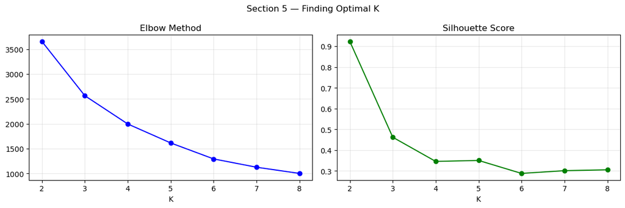

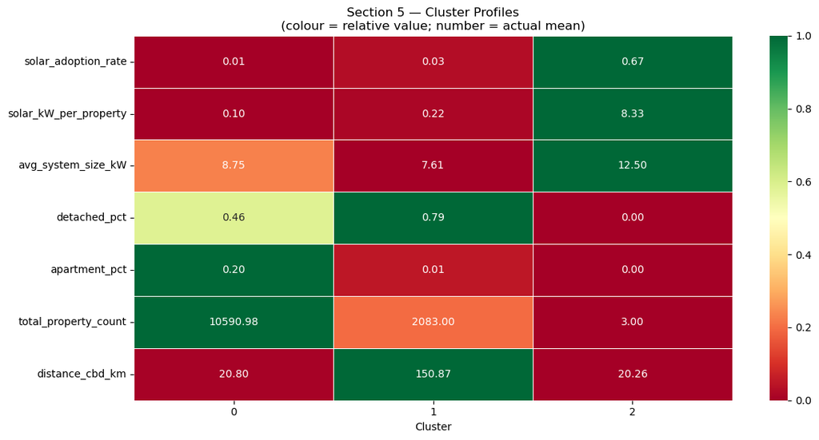

```
=== CLUSTER POLICY INTERPRETATION ===
         solar_adoption_rate  solar_kW_per_property  avg_system_size_kW  detached_pct  apartment_pct  total_property_count  distance_cbd_km
cluster
0                       0.01                   0.10                8.75          0.46           0.20              10590.98            20.80
1                       0.03                   0.22                7.61          0.79           0.01               2083.00           150.87
2                       0.67                   8.33               12.50          0.00           0.00                  3.00            20.26
```

```python
from sklearn.preprocessing import StandardScaler
from sklearn.cluster import KMeans
from sklearn.metrics import silhouette_score

df_cross = df_mel_filled.groupby('postcode').agg(
    solar_adoption_rate  = ('solar_adoption_rate',  'median'),
    solar_kW_per_property= ('solar_kW_per_property', 'median'),
    avg_system_size_kW   =('avg_system_size_kW',     'median'),
    distance_cbd_km      = ('distance_cbd_km',       'first'),
    detached_pct         = ('detached_pct',           'median'),
    apartment_pct        = ('apartment_pct',          'median'),
    total_property_count = ('total_property_count',   'median'),

).reset_index().dropna()

full_cluster_features = [
    'solar_adoption_rate', 'solar_kW_per_property', 'avg_system_size_kW',
    'detached_pct', 'apartment_pct','total_property_count','distance_cbd_km',

]

df_cluster = df_cross[full_cluster_features].dropna()
valid_idx  = df_cluster.index

scaler   = StandardScaler()
X_scaled = scaler.fit_transform(df_cluster)

# Find optimal K with Elbow Method and Silhouette Score
inertias, silhouettes = [], []
for k in range(2, 9):
    km  = KMeans(n_clusters=k, random_state=42, n_init=10)
    lbl = km.fit_predict(X_scaled)
    inertias.append(km.inertia_)
    silhouettes.append(silhouette_score(X_scaled, lbl))

fig, (ax1, ax2) = plt.subplots(1, 2, figsize=(12, 4))
ax1.plot(range(2,9), inertias,    'bo-'); ax1.set_title('Elbow Method')
ax2.plot(range(2,9), silhouettes, 'go-'); ax2.set_title('Silhouette Score')
for ax in [ax1, ax2]:
    ax.set_xlabel('K'); ax.grid(True, alpha=0.3)
plt.suptitle('Section 5 — Finding Optimal K', fontsize=12)
plt.tight_layout()

plt.show()

# Fit final model (adjust K compare two plots)
K = 3
km_final = KMeans(n_clusters=K, random_state=42, n_init=10)
df_cross.loc[valid_idx, 'cluster'] = km_final.fit_predict(X_scaled)
df_cross['cluster'] = df_cross['cluster'].astype('Int64')

# Profile clusters
profile = df_cross.groupby('cluster')[full_cluster_features].mean().round(2)

plt.figure(figsize=(12, 6))
profile_norm = (profile - profile.min()) / (profile.max() - profile.min())
sns.heatmap(profile_norm.T, annot=profile.T, fmt='.2f',
            cmap='RdYlGn', linewidths=0.5)
plt.title('Section 5 — Cluster Profiles\n'
          '(colour = relative value; number = actual mean)', fontsize=12)
plt.xlabel('Cluster'); plt.tight_layout()
plt.savefig('5_cluster_profiles.png', dpi=150)
plt.show()

print("\n=== CLUSTER POLICY INTERPRETATION ===")
print(profile.to_string())
```

**Conclusion**

- Selection of K=3

K=3 was selected to provide a simple and interpretable segmentation of the full postcode dataset. Unlike the metro-only clustering, this full dataset includes metropolitan, rural, regional and very small postcode areas. Therefore, three clusters provide a practical separation between broad postcode types: urban low-adoption areas, rural/regional detached-house areas, and very small high-intensity outlier areas.

- Cluster 0 — Urban / Metro Low Adopter: 20km from CBD, 46% detached, 20% apartment, 1% adoption rate

ARENA Policy implication: This cluster requires structural and targeted adoption support. Apartment-heavy and mixed-density areas may benefit from shared solar, embedded networks, community batteries and body-corporate incentive programs. Standard household rooftop rebates may be less effective unless they are designed for multi-dwelling properties.

- Cluster 1 — Rural / Regional Detached Housing Segment: 150km from CBD, 79% detached, 1% apartment, 3% adoption rate

Cluster 1 represents rural and regional postcodes located far from Melbourne CBD. These areas have a very high detached-house proportion and very low apartment concentration, indicating strong physical suitability for rooftop solar. However, adoption remains moderate rather than extremely high, suggesting that distance, rural grid conditions, income profile, installation access, installer availability or local market barriers may influence uptake.

The higher solar adoption rate compared with Cluster 0 suggests that detached housing and available roof space support adoption. However, the rural/regional context means these postcodes should not be interpreted in the same way as metropolitan suburbs.

ARENA Policy implication: This cluster may benefit from regional solar and battery programs, installer access support, grid capacity upgrades and rural energy resilience initiatives. Policy should separate this group from metro residential areas because rural adoption barriers are different from urban apartment barriers.

- Cluster 2 — Small-Base High Adoption Outlier: 20km from CBD, 3 properties, 67% adoption rate

Cluster 2 shows a very high solar adoption rate and high solar kW per property, but the average total property count is only 3. This indicates that the high adoption rate is likely caused by a very small denominator rather than a normal residential market pattern. Because there are so few properties, one or two solar installations can produce an extremely high adoption rate.

This cluster should be interpreted as a statistical outlier or special-use segment rather than a meaningful policy target for mainstream residential solar adoption.

ARENA Policy implication: This cluster should be excluded or treated separately in policy modelling. It is useful for identifying data outliers or special-use postcodes, but it should not drive residential solar policy decisions.

- Key Finding for ARENA

The KMeans clustering shows that the full postcode dataset contains different market types rather than one uniform solar adoption market. Cluster 0 reflects urban and mixed-density adoption barriers, Cluster 1 reflects rural/regional detached-house markets,and Cluster 2 reflects small-base statistical outliers.

The most important finding is that solar policy should not use a single approach across all postcodes. Urban areas may require structural solutions for apartments and shared buildings, while rural and regional areas may require grid, battery and installer-access support. Very small-property-count postcodes should be treated carefully or excluded from mainstream adoption modelling because their adoption rates can be unstable.

Overall, the K=3 clustering confirms that postcode context matters. ARENA should segment policy design by urban form, dwelling structure, property count and regional context rather than relying only on solar adoption rate or raw installation volume.

### Section 5 - GeoPandas Maps (2014-2024)

#### GeoMaps for all postcodes

```python
%pip install geopandas folium
```

```python
import geopandas as gpd
import matplotlib.ticker as ticker
import folium
from IPython.display import display
from folium.plugins import TimestampedGeoJson
import json
import matplotlib.pyplot as plt
import matplotlib.colors as mcolors
import warnings
warnings.filterwarnings('ignore')
```

```python
#Read GDF_POA to merge the full postcode dataset
gdf_poa = gpd.read_file(r'/Users/polly/Downloads/Assignment 4/data/POA_2021_AUST_GDA2020.shp')

# ── Step 1: Simplify geometry ─────────────────────────────────────────────
gdf_simple = gdf_poa.copy()
gdf_simple['geometry'] = gdf_simple['geometry'].simplify(
    tolerance=0.001, preserve_topology=True
)
gdf_simple['POA_CODE21'] = gdf_simple['POA_CODE21'].astype(str).str.zfill(4)
gdf_simple = gdf_simple.to_crs(epsg=4326)

# ── Step 2: Prepare panel data ────────────────────────────────────────────
keep_cols = [
    'postcode', 'year', 'solar_adoption_rate',
    'solar_unit', 'solar_kW', 'detached_pct',
    'apartment_pct', 'house_median_price'
]
df_panel = df_mel_filled[
    [c for c in keep_cols if c in df_mel_filled.columns]
].copy()

df_panel['postcode'] = df_panel['postcode'].astype(str).str.zfill(4)
df_panel = df_panel[df_panel['postcode'].str.startswith('3')]

cap = df_panel['solar_adoption_rate'].quantile(0.99)
df_panel['solar_adoption_rate'] = df_panel['solar_adoption_rate'].clip(upper=cap)
df_panel['solar_adoption_pct']  = (df_panel['solar_adoption_rate'] * 100).round(3)

years = sorted(df_panel['year'].unique())
VMIN  = df_panel['solar_adoption_pct'].min()
VMAX  = df_panel['solar_adoption_pct'].max()

print(f"Years: {years}")
print(f"Range: {VMIN:.2f}% — {VMAX:.2f}%")

# ── Step 3: Build postcode geometry lookup ────────────────────────────────
# One GeoJSON with all postcodes — geometry only
all_postcodes = df_panel['postcode'].unique()

gdf_base = gdf_simple[
    gdf_simple['POA_CODE21'].isin(all_postcodes)
][['POA_CODE21', 'geometry']].copy()

gdf_base = gdf_base.rename(columns={'POA_CODE21': 'postcode'})

# ── Step 4: Build data lookup — all years all postcodes ──────────────────
# Structure: { postcode: { year: { adoption, installs, ... } } }
data_lookup = {}

for postcode in all_postcodes:
    data_lookup[postcode] = {}
    for year in years:
        row = df_panel[
            (df_panel['postcode'] == postcode) &
            (df_panel['year'] == year)
        ]
        if len(row) == 0:
            data_lookup[postcode][str(year)] = None
        else:
            r = row.iloc[0]
            data_lookup[postcode][str(year)] = {
                'adoption': round(float(r['solar_adoption_pct']), 2)
                            if pd.notna(r['solar_adoption_pct']) else None,
                'installs': int(r['solar_unit'])
                            if 'solar_unit' in r and pd.notna(r['solar_unit'])
                            else None,
                'detached': round(float(r['detached_pct']) * 100, 1)
                            if 'detached_pct' in r and pd.notna(r['detached_pct'])
                            else None,
                'apartment': round(float(r['apartment_pct']) * 100, 1)
                             if 'apartment_pct' in r and pd.notna(r['apartment_pct'])
                             else None,
                'price':    round(float(r['house_median_price']))
                            if 'house_median_price' in r
                            and pd.notna(r['house_median_price'])
                            else None,
            }

# ── Step 5: Build base GeoJSON ────────────────────────────────────────────
features = []
for _, row in gdf_base.iterrows():
    pc = row['postcode']
    features.append({
        'type': 'Feature',
        'geometry': json.loads(
            gpd.GeoSeries([row.geometry]).to_json()
        )['features'][0]['geometry'],
        'properties': {'postcode': pc}
    })

base_geojson = json.dumps({
    'type': 'FeatureCollection',
    'features': features
})

# ── Step 6: Build colourmap lookup table for JS ───────────────────────────
# Pre-compute hex colours for 1000 evenly spaced values
n_steps   = 1000
cmap      = plt.cm.YlOrRd
colormap_hex = [
    mcolors.to_hex(cmap(i / n_steps))
    for i in range(n_steps + 1)
]

# ── Step 7: Create map ────────────────────────────────────────────────────
m = folium.Map(
    location=[-37.8136, 144.9631],
    zoom_start=10,
    tiles='cartodbpositron',
    prefer_canvas=True
)

# ── Step 8: Inject data + JS into map ────────────────────────────────────
years_js       = json.dumps([str(y) for y in years])
data_lookup_js = json.dumps(data_lookup)
colormap_js    = json.dumps(colormap_hex)

js_code = f"""
<script>
// ── Data ──────────────────────────────────────────────────────────────────
var YEARS        = {years_js};
var DATA_LOOKUP  = {data_lookup_js};
var COLORMAP     = {colormap_js};
var VMIN         = {VMIN};
var VMAX         = {VMAX};
var selectedYears = ["{years[-1]}"];  // default: latest year
var geojsonLayer  = null;
var infoBox       = null;

// ── Colour helper ─────────────────────────────────────────────────────────
function valToColor(val) {{
    if (val === null || val === undefined) return '#d3d3d3';
    var norm  = (val - VMIN) / (VMAX - VMIN);
    norm      = Math.max(0, Math.min(1, norm));
    var idx   = Math.round(norm * (COLORMAP.length - 1));
    return COLORMAP[idx];
}}

// ── Get mean value for selected years ────────────────────────────────────
function getMeanValue(postcode) {{
    var vals = [];
    selectedYears.forEach(function(yr) {{
        var d = DATA_LOOKUP[postcode];
        if (d && d[yr] && d[yr].adoption !== null) {{
            vals.push(d[yr].adoption);
        }}
    }});
    if (vals.length === 0) return null;
    return vals.reduce(function(a,b){{return a+b;}}, 0) / vals.length;
}}

// ── Get display stats for tooltip ────────────────────────────────────────
function getStats(postcode) {{
    var adoptions = [], installs = [], prices = [];
    selectedYears.forEach(function(yr) {{
        var d = DATA_LOOKUP[postcode];
        if (d && d[yr]) {{
            if (d[yr].adoption  !== null) adoptions.push(d[yr].adoption);
            if (d[yr].installs  !== null) installs.push(d[yr].installs);
            if (d[yr].price     !== null) prices.push(d[yr].price);
        }}
    }});
    function mean(arr) {{
        return arr.length ? (arr.reduce(function(a,b){{return a+b;}},0)/arr.length) : null;
    }}
    return {{
        adoption:  mean(adoptions),
        installs:  mean(installs),
        price:     mean(prices),
        nYears:    adoptions.length,
    }};
}}
```

```python
// ── Style function ────────────────────────────────────────────────────────
function styleFeature(feature) {{
    var pc  = feature.properties.postcode;
    var val = getMeanValue(pc);
    return {{
        fillColor:   valToColor(val),
        color:       '#555',
        weight:      0.4,
        fillOpacity: val !== null ? 0.78 : 0.2,
    }};
}}

// ── Highlight on hover ────────────────────────────────────────────────────
function highlightFeature(e) {{
    var layer = e.target;
    layer.setStyle({{weight: 2.5, color: '#333', fillOpacity: 0.9}});
    layer.bringToFront();

    var pc    = layer.feature.properties.postcode;
    var stats = getStats(pc);
    var yrs   = selectedYears.join(', ');
    var html  = '<b>Postcode ' + pc + '</b><br>';

    if (selectedYears.length > 1) {{
        html += '<i style="color:#888">Mean of: ' + yrs + '</i><br><hr style="margin:4px 0">';
    }} else {{
        html += '<i style="color:#888">Year: ' + yrs + '</i><br><hr style="margin:4px 0">';
    }}

    html += stats.adoption !== null
        ? '🌞 Adoption Rate: <b>' + stats.adoption.toFixed(1) + '%</b><br>'
        : '🌞 Adoption Rate: N/A<br>';

    html += stats.installs !== null
        ? '🏠 Avg Solar Installs: <b>' + Math.round(stats.installs) + '</b><br>'
        : '';

    html += stats.price !== null
        ? '💰 Median House Price: <b>$' + Math.round(stats.price).toLocaleString() + '</b><br>'
        : '';

    html += '📅 Data points: <b>' + stats.nYears + ' year(s)</b>';

    infoBox.innerHTML = html;
}}

function resetHighlight(e) {{
    geojsonLayer.resetStyle(e.target);
    infoBox.innerHTML = '<i style="color:#888">Hover over a postcode</i>';
}}

// ── Build GeoJSON layer ───────────────────────────────────────────────────
function buildLayer() {{
    if (geojsonLayer) {{
        map_obj.removeLayer(geojsonLayer);
    }}
    geojsonLayer = L.geoJSON({base_geojson}, {{
        style:        styleFeature,
        onEachFeature: function(feature, layer) {{
            layer.on({{
                mouseover: highlightFeature,
                mouseout:  resetHighlight,
            }});
        }}
    }}).addTo(map_obj);
}}

// ── Year toggle buttons ───────────────────────────────────────────────────
function toggleYear(yr) {{
    var btn = document.getElementById('btn-' + yr);
    var idx = selectedYears.indexOf(yr);

    if (idx === -1) {{
        selectedYears.push(yr);
        btn.style.backgroundColor = '#e74c3c';
        btn.style.color           = 'white';
        btn.style.borderColor     = '#c0392b';
    }} else {{
        if (selectedYears.length === 1) return;  // keep at least 1
        selectedYears.splice(idx, 1);
        btn.style.backgroundColor = 'white';
        btn.style.color           = '#333';
        btn.style.borderColor     = '#ccc';
    }}

    // Update header
    var header = document.getElementById('year-header');
    if (selectedYears.length === 1) {{
        header.innerHTML = '📅 Year: ' + selectedYears[0];
    }} else {{
        header.innerHTML = '📅 Mean of ' + selectedYears.length + ' years';
    }}

    buildLayer();
}}

function selectAll() {{
    selectedYears = YEARS.slice();
    YEARS.forEach(function(yr) {{
        var btn = document.getElementById('btn-' + yr);
        btn.style.backgroundColor = '#e74c3c';
        btn.style.color           = 'white';
        btn.style.borderColor     = '#c0392b';
    }});
    document.getElementById('year-header').innerHTML =
        '📅 Mean of all years (2014–2024)';
    buildLayer();
}}

function clearAll() {{
    var last = YEARS[YEARS.length - 1];
    selectedYears = [last];
    YEARS.forEach(function(yr) {{
        var btn = document.getElementById('btn-' + yr);
        if (yr === last) {{
            btn.style.backgroundColor = '#e74c3c';
            btn.style.color           = 'white';
            btn.style.borderColor     = '#c0392b';
        }} else {{
            btn.style.backgroundColor = 'white';
            btn.style.color           = '#333';
            btn.style.borderColor     = '#ccc';
        }}
    }});
    document.getElementById('year-header').innerHTML = '📅 Year: ' + last;
    buildLayer();
}}

// ── Init after map loads ──────────────────────────────────────────────────
document.addEventListener('DOMContentLoaded', function() {{
    // Find the Leaflet map object
    var maps = Object.keys(window).filter(function(k) {{
        return k.startsWith('map_');
    }});
    if (maps.length > 0) {{
        map_obj = window[maps[0]];
    }}

    // Info box
    infoBox = document.getElementById('info-box');

    // Build initial layer
    buildLayer();

    // Set latest year button active
    var lastBtn = document.getElementById('btn-{years[-1]}');
    if (lastBtn) {{
        lastBtn.style.backgroundColor = '#e74c3c';
        lastBtn.style.color           = 'white';
        lastBtn.style.borderColor     = '#c0392b';
    }}
}});
</script>
"""

m.get_root().html.add_child(folium.Element(js_code))

# ── Step 9: Year selector panel (bottom left) ─────────────────────────────
btn_html_parts = []
for year in years:
    is_latest = year == years[-1]
    bg    = '#e74c3c' if is_latest else 'white'
    color = 'white'   if is_latest else '#333'
    border= '#c0392b' if is_latest else '#ccc'
    btn_html_parts.append(
        f'<button id="btn-{year}" onclick="toggleYear(\'{year}\')" '
        f'style="'
        f'background-color:{bg}; color:{color}; '
        f'border:1px solid {border}; '
        f'border-radius:4px; padding:4px 8px; '
        f'margin:2px; cursor:pointer; font-size:11px; '
        f'font-weight:bold; transition:all 0.2s;">'
        f'{year}</button>'
    )

year_panel = f"""
<div style="
    position:         fixed;
    bottom:           20px;
    left:             15px;
    z-index:          1000;
    background-color: white;
    padding:          10px 12px;
    border-radius:    8px;
    border:           1px solid grey;
    box-shadow:       2px 2px 6px rgba(0,0,0,0.25);
    max-width:        280px;
">
    <div id="year-header" style="
        font-size:   12px;
        font-weight: bold;
        color:       #333;
        margin-bottom: 6px;
    ">📅 Year: {years[-1]}</div>
```

```python
    <div style="margin-bottom:6px;">
        {''.join(btn_html_parts)}
    </div>

    <div style="display:flex; gap:6px; margin-top:4px;">
        <button onclick="selectAll()" style="
            flex:1; background:#3498db; color:white;
            border:none; border-radius:4px;
            padding:4px; cursor:pointer; font-size:10px;">
            Select All
        </button>
        <button onclick="clearAll()" style="
            flex:1; background:#95a5a6; color:white;
            border:none; border-radius:4px;
            padding:4px; cursor:pointer; font-size:10px;">
            Reset
        </button>
    </div>

    <div style="
        font-size:  9px;
        color:      #888;
        margin-top: 5px;
        text-align: center;
    ">Click years to select multiple<br>Map shows mean when multiple selected</div>
</div>
"""
m.get_root().html.add_child(folium.Element(year_panel))

# ── Step 10: Hover info box ───────────────────────────────────────────────
info_box = """
<div id="info-box" style="
    position:         fixed;
    bottom:           20px;
    left:             310px;
    z-index:          1000;
    background-color: white;
    padding:          10px 14px;
    border-radius:    8px;
    border:           1px solid grey;
    box-shadow:       2px 2px 6px rgba(0,0,0,0.25);
    font-size:        12px;
    min-width:        200px;
    max-width:        260px;
    line-height:      1.6;
">
    <i style="color:#888">Hover over a postcode</i>
</div>
"""
m.get_root().html.add_child(folium.Element(info_box))

# ── Step 11: Vertical legend (right side) ────────────────────────────────
stops  = np.linspace(0, 1, 10)
colors = [mcolors.to_hex(cmap(s)) for s in stops]
gradient_stops = ', '.join(
    [f'{c} {int(s*100)}%' for c, s in zip(colors, stops)]
)

legend_html = f"""
<div style="
    position:         fixed;
    top:              50%;
    right:            15px;
    transform:        translateY(-50%);
    z-index:          1000;
    background-color: white;
    padding:          12px 8px;
    border-radius:    6px;
    border:           1px solid grey;
    box-shadow:       2px 2px 6px rgba(0,0,0,0.25);
    display:          flex;
    flex-direction:   column;
    align-items:      center;
    gap:              6px;
">
    <div style="
        writing-mode:     vertical-rl;
        text-orientation: mixed;
        transform:        rotate(180deg);
        font-size:        11px;
        font-weight:      bold;
        color:            #333;
        white-space:      nowrap;
    ">Solar Adoption Rate (%)</div>

    <div style="font-size:10px; color:#333;">{VMAX:.1f}%</div>

    <div style="
        width:         22px;
        height:        220px;
        background:    linear-gradient(to top, {gradient_stops});
        border:        1px solid #ccc;
        border-radius: 3px;
    "></div>

    <div style="font-size:10px; color:#333;">{VMIN:.1f}%</div>

    <div style="
        font-size:  9px; color:#888;
        text-align: center; max-width:55px;
        margin-top: 4px;
    ">Fixed scale<br>2014–2024</div>
</div>
"""
m.get_root().html.add_child(folium.Element(legend_html))

# ── Step 12: Title ────────────────────────────────────────────────────────
title_html = """
<div style="
    position:         fixed;
    top:              10px;
    left:             50%;
    transform:        translateX(-50%);
    z-index:          1000;
    background-color: white;
    padding:          8px 18px;
    border-radius:    6px;
    border:           1px solid grey;
    font-size:        13px;
    font-weight:      bold;
    box-shadow:       2px 2px 4px rgba(0,0,0,0.2);
    white-space:      nowrap;
">
    Melbourne Solar Adoption 2014–2024
    <span style="font-size:11px; font-weight:normal; color:#666;">
        &nbsp;|&nbsp; Select years below left · Hover postcodes for details
    </span>
</div>
"""
m.get_root().html.add_child(folium.Element(title_html))

# ── Step 13: CBD marker ───────────────────────────────────────────────────
folium.Marker(
    location=[-37.8136, 144.9631],
    tooltip='Melbourne CBD',
    icon=folium.Icon(color='blue', icon='building', prefix='fa')
).add_to(m)

# ── Save and display ──────────────────────────────────────────────────────
m.save('solar_adoption_map_interactive.html')
print('Saved: solar_adoption_map_interactive.html')

from IPython.display import IFrame
IFrame('solar_adoption_map_interactive.html', width=980, height=680)

from IPython.display import HTML, display
display(HTML(m._repr_html_()))
```

```
Years: [np.int32(2014), np.int32(2015), np.int32(2016), np.int32(2017), np.int32(2018), np.int32(2019), np.int32(2020), np.int32(2021), np.int32(2022), np.int32(2023), np.int32(2024)]
Range: 0.00% — 8.84%
Saved: solar_adoption_map_interactive.html
```

Make this Notebook Trusted to load map: File -> Trust Notebook

[interactive chart not shown]

#### GeoMap for KMeans Cluster

**Clustering Map 1: Solar Adoption in Victoria**

```python
# ── Step 1: Build filtered base dataset ─────────────────────────────────────
df_kmeans_base = df_mel_filled.copy()

df_kmeans_base["postcode"] = (
    df_kmeans_base["postcode"]
    .astype(str)
    .str.zfill(4)
)

# Apply the same basic cleaning rules used for full-postcode analysis
df_kmeans_base = df_kmeans_base[
    (df_kmeans_base["year"].between(2014, 2024)) &
    (df_kmeans_base["solar_adoption_rate"].between(0, 1)) &
    (df_kmeans_base["total_property_count"] >= 50) &
    (df_kmeans_base["distance_cbd_km"].notna())
].copy()

#print("Unique postcodes after filtering:", df_kmeans_base["postcode"].nunique())  # should be 353


# ── Step 2: Aggregate to one row per postcode (FROM THE FILTERED BASE) ─────
df_cross = (
    df_kmeans_base
    .groupby("postcode")
    .agg(
        solar_adoption_rate=("solar_adoption_rate", "median"),
        solar_kW_per_property=("solar_kW_per_property", "median"),
        avg_system_size_kW=("avg_system_size_kW", "median"),
        distance_cbd_km=("distance_cbd_km", "median"),
        detached_pct=("detached_pct", "median"),
        apartment_pct=("apartment_pct", "median"),
        total_property_count=("total_property_count", "median")
    )
    .reset_index()
    .dropna()
    .copy()
)

#print("df_cross rows:", len(df_cross))
#print("df_cross unique postcodes:", df_cross["postcode"].nunique())  # should be 353


# ── Step 3: Select clustering features ──────────────────────────────────────
full_cluster_features = [
    "solar_adoption_rate",
    "solar_kW_per_property",
    "avg_system_size_kW",
    "detached_pct",
    "apartment_pct",
    "total_property_count",
    "distance_cbd_km"
]

df_cluster = df_cross[full_cluster_features].dropna().copy()
valid_idx = df_cluster.index


# ── Step 4: Scale features ──────────────────────────────────────────────────
scaler = StandardScaler()
X_scaled = scaler.fit_transform(df_cluster)


# ── Step 5: Elbow and Silhouette Scores ─────────────────────────────────────
inertias = []
silhouettes = []

for k in range(2, 9):
    km = KMeans(n_clusters=k, random_state=42, n_init=10)
    labels = km.fit_predict(X_scaled)

    inertias.append(km.inertia_)
    silhouettes.append(silhouette_score(X_scaled, labels))

k_summary = pd.DataFrame({
    "k": range(2, 9),
    "inertia": inertias,
    "silhouette_score": silhouettes
})

# display(k_summary)


# ── Step 6: Fit final KMeans model with K=3 ─────────────────────────────────
final_k = 3

km_final = KMeans(
    n_clusters=final_k,
    random_state=42,
    n_init=10
)

df_cross.loc[valid_idx, "cluster"] = km_final.fit_predict(X_scaled)
df_cross["cluster"] = df_cross["cluster"].astype("Int64")

# Check cluster profile
cluster_profile = (
    df_cross
    .groupby("cluster")
    .agg(
        solar_adoption_rate=("solar_adoption_rate", "median"),
        solar_kW_per_property=("solar_kW_per_property", "median"),
        avg_system_size_kW=("avg_system_size_kW", "median"),
        detached_pct=("detached_pct", "median"),
        apartment_pct=("apartment_pct", "median"),
        total_property_count=("total_property_count", "median"),
        distance_cbd_km=("distance_cbd_km", "median"),
        postcode_count=("postcode", "count")
    )
)

# display(cluster_profile)


# ── Step 7: Cluster names and policy labels ─────────────────────────────────
cluster_colors = {
    0: "#27ae60",
    1: "#f39c12",
    2: "#e74c3c",
}

cluster_names = {
    0: "Urban / Metro Low Adopter",
    1: "Small-Base High Adoption Outlier",
    2: "Rural / Regional Detached Segment"
}

cluster_policy = {
    0: "Shared solar, apartment programs, community batteries",
    1: "Treat as outlier; exclude from mainstream policy modelling",
    2: "Regional solar, battery and grid resilience support"
}

df_cross["cluster_name"] = df_cross["cluster"].map(cluster_names)
df_cross["cluster_policy"] = df_cross["cluster"].map(cluster_policy)
df_cross["cluster_color"] = df_cross["cluster"].map(cluster_colors)


# ── Step 8: Prepare GeoDataFrame (dedup postcodes + polygons) ──────────────
df_cross["postcode"] = df_cross["postcode"].astype(str).str.zfill(4)

gdf_simple = gdf_poa.copy()
gdf_simple["POA_CODE21"] = (
    gdf_simple["POA_CODE21"]
    .astype(str)
    .str.zfill(4)
)

# Convert CRS first
gdf_simple = gdf_simple.to_crs(epsg=4326)

# Dissolve duplicated geometries so each postcode appears only once
gdf_simple = (
    gdf_simple
    .dissolve(by="POA_CODE21", as_index=False)
)

# Simplify after dissolve
gdf_simple["geometry"] = gdf_simple["geometry"].simplify(
    tolerance=0.001,
    preserve_topology=True
)

#print("gdf rows after dissolve:", len(gdf_simple))
#print("gdf unique POA_CODE21 after dissolve:", gdf_simple["POA_CODE21"].nunique())

# Make sure df_cross also has one row per postcode
df_cross_unique = (
    df_cross
    .sort_values("postcode")
    .drop_duplicates(subset=["postcode"], keep="first")
    .copy()
)

#print("df_cross_unique rows:", len(df_cross_unique))
#print("df_cross_unique unique postcodes:", df_cross_unique["postcode"].nunique())

# Merge with validation
gdf_cluster = gdf_simple.merge(
    df_cross_unique,
    left_on="POA_CODE21",
    right_on="postcode",
    how="inner",
    validate="one_to_one"
)

#print(f"Postcodes in df_cross_unique: {len(df_cross_unique)}")
#print(f"Postcodes on map after fix: {len(gdf_cluster)}")
print(f"Unique postcodes on map: {gdf_cluster['postcode'].nunique()}")


# ── Step 9: Prepare display fields ──────────────────────────────────────────
gdf_cluster["adoption_pct"] = (
    gdf_cluster["solar_adoption_rate"] * 100
).round(2)

gdf_cluster["detached_pct_display"] = (
    gdf_cluster["detached_pct"] * 100
).round(1)

gdf_cluster["apartment_pct_display"] = (
    gdf_cluster["apartment_pct"] * 100
).round(1)

gdf_cluster["distance_cbd_km_display"] = (
    gdf_cluster["distance_cbd_km"]
).round(1)

gdf_cluster["total_properties_display"] = (
    gdf_cluster["total_property_count"]
).round(0).astype(int)


# ── Step 10: Create Folium map ──────────────────────────────────────────────
m = folium.Map(
    location=[-37.8136, 144.9631],
    zoom_start=8,
    tiles="cartodbpositron",
    prefer_canvas=True
)

folium.GeoJson(
    gdf_cluster,
    name="K-Means Clusters (K=3)",
    style_function=lambda feature: {
        "fillColor": feature["properties"].get("cluster_color", "#95a5a6"),
        "color": "#555",
        "weight": 0.5,
        "fillOpacity": 0.75,
    },
    highlight_function=lambda feature: {
        "weight": 2.5,
        "color": "#333",
        "fillOpacity": 0.92,
    },
    tooltip=folium.GeoJsonTooltip(
        fields=[
            "postcode",
            "cluster",
            "cluster_name",
            "adoption_pct",
            "detached_pct_display",
            "apartment_pct_display",
            "distance_cbd_km_display",
            "total_properties_display",
            "cluster_policy"
        ],
        aliases=[
            "Postcode:",
            "Cluster:",
            "Profile:",
            "Adoption Rate (%):",
            "Detached %:",
            "Apartment %:",
            "Distance CBD (km):",
            "Total Properties:",
            "Policy:"
        ],
        localize=True,
        sticky=False,
        style=(
            "background-color: white;"
            "border: 1px solid grey;"
            "border-radius: 6px;"
            "font-size: 12px;"
            "padding: 10px;"
            "max-width: 300px;"
        )
    )
).add_to(m)


# ── Step 11: Add legend ──────────────────────────────────────────────────────
legend_items = ""

for c in sorted(cluster_colors.keys()):
    sub = df_cross[df_cross["cluster"] == c]

    if len(sub) == 0:
        continue

    n_postcodes = len(sub)
    median_adoption = sub["solar_adoption_rate"].median() * 100
    color = cluster_colors[c]
    name = cluster_names[c]
    policy = cluster_policy[c]

    legend_items += f"""
    <div style="
        display:flex;
        align-items:flex-start;
        gap:8px;
        margin:5px 0;
        padding:6px;
        border-radius:4px;
        background:#fafafa;
        border-left:4px solid {color};
    ">
        <div style="
            min-width:14px;
            height:14px;
            background:{color};
            border-radius:3px;
            margin-top:2px;
        "></div>
        <div>
            <div style="font-weight:bold; font-size:11px; color:#333;">
                C{c}: {name}
            </div>
            <div style="font-size:10px; color:#666;">
                {n_postcodes} postcodes · median {median_adoption:.1f}% adoption
            </div>
            <div style="font-size:9px; color:#888; margin-top:2px;">
                {policy}
            </div>
        </div>
    </div>
    """

legend_html = f"""
<div style="
    position:fixed;
    top:50%;
    right:15px;
    transform:translateY(-50%);
    z-index:1000;
    background-color:white;
    padding:12px;
    border-radius:8px;
    border:1px solid grey;
    box-shadow:2px 2px 6px rgba(0,0,0,0.25);
    min-width:250px;
    max-width:290px;
">
    <div style="
        font-size:12px;
        font-weight:bold;
        color:#333;
        margin-bottom:8px;
        border-bottom:1px solid #eee;
        padding-bottom:6px;
    ">K-Means Clusters (K=3)</div>

    {legend_items}

    <div style="
        font-size:9px;
        color:#888;
        margin-top:8px;
        text-align:center;
        border-top:1px solid #eee;
        padding-top:6px;
    ">Hover over postcodes for details</div>
</div>
"""

m.get_root().html.add_child(folium.Element(legend_html))


# ── Step 12: Add title and CBD marker ───────────────────────────────────────
title_html = """
<div style="
    position:fixed;
    top:10px;
    left:50%;
    transform:translateX(-50%);
    z-index:1000;
    background-color:white;
    padding:8px 18px;
    border-radius:6px;
    border:1px solid grey;
    font-size:13px;
    font-weight:bold;
    box-shadow:2px 2px 4px rgba(0,0,0,0.2);
    white-space:nowrap;
">
    Melbourne Solar Adoption — K-Means Cluster Map for Victoria | 678 Postcodes (K=3)
</div>
"""

m.get_root().html.add_child(folium.Element(title_html))

folium.Marker(
    location=[-37.8136, 144.9631],
    tooltip="Melbourne CBD",
    icon=folium.Icon(color="blue", icon="building", prefix="fa")
).add_to(m)


# ── Step 13: Save and display ───────────────────────────────────────────────
m.save("solar_cluster_map_k3.html")

display(HTML(m._repr_html_()))
```

```
Unique postcodes on map: 678
```

Make this Notebook Trusted to load map: File -> Trust Notebook

[interactive chart not shown]

**Clustering Map 2: Greater Melbourne (353 postcodes)**

```python
# ── Step 1: Build filtered base dataset
df_kmeans_base = df_mel_filled.copy()

df_kmeans_base["postcode"] = (
    df_kmeans_base["postcode"]
    .astype(str)
    .str.zfill(4)
)

# Filter to match the original 353-postcode analysis
df_kmeans_base = df_kmeans_base[
    (df_kmeans_base["solar_adoption_rate"].notna()) &
    (df_kmeans_base["distance_zone"].notna())
].copy()

#print("Unique postcodes after filtering:", df_kmeans_base["postcode"].nunique())


# ── Step 2: Aggregate to one row per postcode ───────────────────────────────
df_cross = (
    df_kmeans_base
    .groupby("postcode")
    .agg(
        solar_adoption_rate=("solar_adoption_rate", "median"),
        solar_kW_per_property=("solar_kW_per_property", "median"),
        avg_system_size_kW=("avg_system_size_kW", "median"),
        distance_cbd_km=("distance_cbd_km", "median"),
        detached_pct=("detached_pct", "median"),
        apartment_pct=("apartment_pct", "median"),
        total_property_count=("total_property_count", "median")
    )
    .reset_index()
    .dropna()
    .copy()
)

#print("df_cross rows:", len(df_cross))
#print("df_cross unique postcodes:", df_cross["postcode"].nunique())


# ── Step 3: Select clustering features ──────────────────────────────────────
full_cluster_features = [
    "solar_adoption_rate",
    "solar_kW_per_property",
    "avg_system_size_kW",
    "detached_pct",
    "apartment_pct",
    "total_property_count",
    "distance_cbd_km"
]

df_cluster = df_cross[full_cluster_features].dropna().copy()
valid_idx = df_cluster.index

#print("df_cluster rows (after dropping any remaining NaNs):", len(df_cluster))


# ── Step 4: Scale features ──────────────────────────────────────────────────
scaler = StandardScaler()
X_scaled = scaler.fit_transform(df_cluster)


# ── Step 5: Elbow and Silhouette Scores ─────────────────────────────────────
inertias = []
silhouettes = []

for k in range(2, 9):
    km = KMeans(n_clusters=k, random_state=42, n_init=10)
    labels = km.fit_predict(X_scaled)

    inertias.append(km.inertia_)
    silhouettes.append(silhouette_score(X_scaled, labels))

k_summary = pd.DataFrame({
    "k": range(2, 9),
    "inertia": inertias,
    "silhouette_score": silhouettes
})

# display(k_summary)


# ── Step 6: Fit final KMeans model with K=3 ─────────────────────────────────
final_k = 3

km_final = KMeans(
    n_clusters=final_k,
    random_state=42,
    n_init=10
)

df_cross.loc[valid_idx, "cluster"] = km_final.fit_predict(X_scaled)
df_cross["cluster"] = df_cross["cluster"].astype("Int64")

# Check cluster profile
cluster_profile = (
    df_cross
    .groupby("cluster")
    .agg(
        solar_adoption_rate=("solar_adoption_rate", "median"),
        solar_kW_per_property=("solar_kW_per_property", "median"),
        avg_system_size_kW=("avg_system_size_kW", "median"),
        detached_pct=("detached_pct", "median"),
        apartment_pct=("apartment_pct", "median"),
        total_property_count=("total_property_count", "median"),
        distance_cbd_km=("distance_cbd_km", "median"),
        postcode_count=("postcode", "count")
    )
)

# display(cluster_profile)


# ── Step 7: Cluster names and policy labels ─────────────────────────────────
cluster_colors = {
    0: "#f39c12",
    1: "#27ae60",
    2: "#e74c3c",
}

cluster_names = {
    0: "Urban / Metro Low Adopter",
    1: "Small-Base High Adoption Outlier",
    2: "Rural / Regional Detached Segment"
}

cluster_policy = {
    0: "Shared solar, apartment programs, community batteries",
    1: "Treat as outlier; exclude from mainstream policy modelling",
    2: "Regional solar, battery and grid resilience support"
}

df_cross["cluster_name"] = df_cross["cluster"].map(cluster_names)
df_cross["cluster_policy"] = df_cross["cluster"].map(cluster_policy)
df_cross["cluster_color"] = df_cross["cluster"].map(cluster_colors)


# ── Step 8: Prepare GeoDataFrame (dedup postcodes + polygons) ──────────────
df_cross["postcode"] = df_cross["postcode"].astype(str).str.zfill(4)

gdf_simple = gdf_poa.copy()
gdf_simple["POA_CODE21"] = (
    gdf_simple["POA_CODE21"]
    .astype(str)
    .str.zfill(4)
)

# Convert CRS first
gdf_simple = gdf_simple.to_crs(epsg=4326)

# Dissolve duplicated geometries so each postcode appears only once
gdf_simple = (
    gdf_simple
    .dissolve(by="POA_CODE21", as_index=False)
)

# Simplify after dissolve
gdf_simple["geometry"] = gdf_simple["geometry"].simplify(
    tolerance=0.001,
    preserve_topology=True
)

#print("gdf rows after dissolve:", len(gdf_simple))
#print("gdf unique POA_CODE21 after dissolve:", gdf_simple["POA_CODE21"].nunique())

# Make sure df_cross also has one row per postcode
df_cross_unique = (
    df_cross
    .sort_values("postcode")
    .drop_duplicates(subset=["postcode"], keep="first")
    .copy()
)

#print("df_cross_unique rows:", len(df_cross_unique))
#print("df_cross_unique unique postcodes:", df_cross_unique["postcode"].nunique())

# Merge with validation
gdf_cluster = gdf_simple.merge(
    df_cross_unique,
    left_on="POA_CODE21",
    right_on="postcode",
    how="inner",
    validate="one_to_one"
)

#print(f"Postcodes in df_cross_unique: {len(df_cross_unique)}")
#print(f"Postcodes on map after fix: {len(gdf_cluster)}")
print(f"Unique postcodes on map: {gdf_cluster['postcode'].nunique()}")


# ── Step 9: Prepare display fields ──────────────────────────────────────────
gdf_cluster["adoption_pct"] = (
    gdf_cluster["solar_adoption_rate"] * 100
).round(2)

gdf_cluster["detached_pct_display"] = (
    gdf_cluster["detached_pct"] * 100
).round(1)

gdf_cluster["apartment_pct_display"] = (
    gdf_cluster["apartment_pct"] * 100
).round(1)

gdf_cluster["distance_cbd_km_display"] = (
    gdf_cluster["distance_cbd_km"]
).round(1)

gdf_cluster["total_properties_display"] = (
    gdf_cluster["total_property_count"]
).round(0).astype(int)


# ── Step 10: Create Folium map ──────────────────────────────────────────────
m = folium.Map(
    location=[-37.8136, 144.9631],
    zoom_start=8,
    tiles="cartodbpositron",
    prefer_canvas=True
)

folium.GeoJson(
    gdf_cluster,
    name="K-Means Clusters (K=3)",
    style_function=lambda feature: {
        "fillColor": feature["properties"].get("cluster_color", "#95a5a6"),
        "color": "#555",
        "weight": 0.5,
        "fillOpacity": 0.75,
    },
    highlight_function=lambda feature: {
        "weight": 2.5,
        "color": "#333",
        "fillOpacity": 0.92,
    },
    tooltip=folium.GeoJsonTooltip(
        fields=[
            "postcode",
            "cluster",
            "cluster_name",
            "adoption_pct",
            "detached_pct_display",
            "apartment_pct_display",
            "distance_cbd_km_display",
            "total_properties_display",
            "cluster_policy"
        ],
        aliases=[
            "Postcode:",
            "Cluster:",
            "Profile:",
            "Adoption Rate (%):",
            "Detached %:",
            "Apartment %:",
            "Distance CBD (km):",
            "Total Properties:",
            "Policy:"
        ],
        localize=True,
        sticky=False,
        style=(
            "background-color: white;"
            "border: 1px solid grey;"
            "border-radius: 6px;"
            "font-size: 12px;"
            "padding: 10px;"
            "max-width: 300px;"
        )
    )
).add_to(m)


# ── Step 11: Add legend ──────────────────────────────────────────────────────
legend_items = ""

for c in sorted(cluster_colors.keys()):
    sub = df_cross[df_cross["cluster"] == c]

    if len(sub) == 0:
        continue

    n_postcodes = len(sub)
    median_adoption = sub["solar_adoption_rate"].median() * 100
    color = cluster_colors[c]
    name = cluster_names[c]
    policy = cluster_policy[c]

    legend_items += f"""
    <div style="
        display:flex;
        align-items:flex-start;
        gap:8px;
        margin:5px 0;
        padding:6px;
        border-radius:4px;
        background:#fafafa;
        border-left:4px solid {color};
    ">
        <div style="
            min-width:14px;
            height:14px;
            background:{color};
            border-radius:3px;
            margin-top:2px;
        "></div>
        <div>
            <div style="font-weight:bold; font-size:11px; color:#333;">
                C{c}: {name}
            </div>
            <div style="font-size:10px; color:#666;">
                {n_postcodes} postcodes · median {median_adoption:.1f}% adoption
            </div>
            <div style="font-size:9px; color:#888; margin-top:2px;">
                {policy}
            </div>
        </div>
    </div>
    """

legend_html = f"""
<div style="
    position:fixed;
    top:50%;
    right:15px;
    transform:translateY(-50%);
    z-index:1000;
    background-color:white;
    padding:12px;
    border-radius:8px;
    border:1px solid grey;
    box-shadow:2px 2px 6px rgba(0,0,0,0.25);
    min-width:250px;
    max-width:290px;
">
    <div style="
        font-size:12px;
        font-weight:bold;
        color:#333;
        margin-bottom:8px;
        border-bottom:1px solid #eee;
        padding-bottom:6px;
    ">K-Means Clusters (K=3)</div>

    {legend_items}

    <div style="
        font-size:9px;
        color:#888;
        margin-top:8px;
        text-align:center;
        border-top:1px solid #eee;
        padding-top:6px;
    ">Hover over postcodes for details</div>
</div>
"""

m.get_root().html.add_child(folium.Element(legend_html))


# ── Step 12: Add title and CBD marker ───────────────────────────────────────
title_html = """
<div style="
    position:fixed;
    top:10px;
    left:50%;
    transform:translateX(-50%);
    z-index:1000;
    background-color:white;
    padding:8px 18px;
    border-radius:6px;
    border:1px solid grey;
    font-size:13px;
    font-weight:bold;
    box-shadow:2px 2px 4px rgba(0,0,0,0.2);
    white-space:nowrap;
">
    Melbourne Solar Adoption — K-Means Cluster Map for Great Melbourne | 353 Postcodes (K=3)
</div>
"""

m.get_root().html.add_child(folium.Element(title_html))

folium.Marker(
    location=[-37.8136, 144.9631],
    tooltip="Melbourne CBD",
    icon=folium.Icon(color="blue", icon="building", prefix="fa")
).add_to(m)


# ── Step 13: Save and display ───────────────────────────────────────────────
m.save("solar_cluster_map_k3.html")

display(HTML(m._repr_html_()))
```

```
Unique postcodes on map: 353
```

Make this Notebook Trusted to load map: File -> Trust Notebook

[interactive chart not shown]

**Clustering Map 3: Melbourne Metro Area <=60km (258 postcodes)**

```python
# ── Step 1: Build filtered base dataset
df_kmeans_base = df_metro.copy()

df_kmeans_base["postcode"] = (
    df_kmeans_base["postcode"]
    .astype(str)
    .str.zfill(4)
)

# Filter to match 258 postcode analysis
df_kmeans_base = df_kmeans_base[
    (df_kmeans_base["solar_adoption_rate"].notna()) &
    (df_kmeans_base["distance_zone"].notna())
].copy()

#print("Unique postcodes after filtering:", df_kmeans_base["postcode"].nunique())


# ── Step 2: Aggregate to one row per postcode ───────────────────────────────
df_cross = (
    df_kmeans_base
    .groupby("postcode")
    .agg(
        solar_adoption_rate=("solar_adoption_rate", "median"),
        solar_kW_per_property=("solar_kW_per_property", "median"),
        avg_system_size_kW=("avg_system_size_kW", "median"),
        distance_cbd_km=("distance_cbd_km", "median"),
        detached_pct=("detached_pct", "median"),
        apartment_pct=("apartment_pct", "median"),
        total_property_count=("total_property_count", "median")
    )
    .reset_index()
    .dropna()
    .copy()
)

#print("df_cross rows:", len(df_cross))
#print("df_cross unique postcodes:", df_cross["postcode"].nunique())


# ── Step 3: Select clustering features ──────────────────────────────────────
full_cluster_features = [
    "solar_adoption_rate",
    "solar_kW_per_property",
    "avg_system_size_kW",
    "detached_pct",
    "apartment_pct",
    "total_property_count",
    "distance_cbd_km"
]

df_cluster = df_cross[full_cluster_features].dropna().copy()
valid_idx = df_cluster.index

#print("df_cluster rows (after dropping any remaining NaNs):", len(df_cluster))


# ── Step 4: Scale features ──────────────────────────────────────────────────
scaler = StandardScaler()
X_scaled = scaler.fit_transform(df_cluster)


# ── Step 5: Elbow and Silhouette Scores ─────────────────────────────────────
inertias = []
silhouettes = []

for k in range(2, 9):
    km = KMeans(n_clusters=k, random_state=42, n_init=10)
    labels = km.fit_predict(X_scaled)

    inertias.append(km.inertia_)
    silhouettes.append(silhouette_score(X_scaled, labels))

k_summary = pd.DataFrame({
    "k": range(2, 9),
    "inertia": inertias,
    "silhouette_score": silhouettes
})

# display(k_summary)


# ── Step 6: Fit final KMeans model with K=4 ─────────────────────────────────
final_k = 4

km_final = KMeans(
    n_clusters=final_k,
    random_state=42,
    n_init=10
)

df_cross.loc[valid_idx, "cluster"] = km_final.fit_predict(X_scaled)
df_cross["cluster"] = df_cross["cluster"].astype("Int64")

# Check cluster profile — review this to rename clusters meaningfully below
cluster_profile = (
    df_cross
    .groupby("cluster")
    .agg(
        solar_adoption_rate=("solar_adoption_rate", "median"),
        solar_kW_per_property=("solar_kW_per_property", "median"),
        avg_system_size_kW=("avg_system_size_kW", "median"),
        detached_pct=("detached_pct", "median"),
        apartment_pct=("apartment_pct", "median"),
        total_property_count=("total_property_count", "median"),
        distance_cbd_km=("distance_cbd_km", "median"),
        postcode_count=("postcode", "count")
    )
)

#display(cluster_profile)  # review this before finalizing names/colors below


# ── Step 7: Cluster names and policy labels (4 clusters) ───────────────────

cluster_colors = {
    0: "#27ae60",
    1: "#f39c12",
    2: "#e74c3c",
    3: "#3498db",
}

cluster_names = {
    0: "Urban / Metro Low Adopter",
    1: "Small-Base High Adoption Outlier",
    2: "Rural / Regional Detached Segment",
    3: "Emerging Suburban Segment",
}

cluster_policy = {
    0: "Shared solar, apartment programs, community batteries",
    1: "Treat as outlier; exclude from mainstream policy modelling",
    2: "Regional solar, battery and grid resilience support",
    3: "Targeted incentives to accelerate uptake",
}

df_cross["cluster_name"] = df_cross["cluster"].map(cluster_names)
df_cross["cluster_policy"] = df_cross["cluster"].map(cluster_policy)
df_cross["cluster_color"] = df_cross["cluster"].map(cluster_colors)


# ── Step 8: Prepare GeoDataFrame (dedup postcodes + polygons) ──────────────
df_cross["postcode"] = df_cross["postcode"].astype(str).str.zfill(4)

gdf_simple = gdf_poa.copy()
gdf_simple["POA_CODE21"] = (
    gdf_simple["POA_CODE21"]
    .astype(str)
    .str.zfill(4)
)

# Convert CRS first
gdf_simple = gdf_simple.to_crs(epsg=4326)

# Dissolve duplicated geometries so each postcode appears only once
gdf_simple = (
    gdf_simple
    .dissolve(by="POA_CODE21", as_index=False)
)

# Simplify after dissolve
gdf_simple["geometry"] = gdf_simple["geometry"].simplify(
    tolerance=0.001,
    preserve_topology=True
)

#print("gdf rows after dissolve:", len(gdf_simple))
#print("gdf unique POA_CODE21 after dissolve:", gdf_simple["POA_CODE21"].nunique())

# Make sure df_cross also has one row per postcode
df_cross_unique = (
    df_cross
    .sort_values("postcode")
    .drop_duplicates(subset=["postcode"], keep="first")
    .copy()
)

#print("df_cross_unique rows:", len(df_cross_unique))
#print("df_cross_unique unique postcodes:", df_cross_unique["postcode"].nunique())

# Merge with validation
gdf_cluster = gdf_simple.merge(
    df_cross_unique,
    left_on="POA_CODE21",
    right_on="postcode",
    how="inner",
    validate="one_to_one"
)

#print(f"Postcodes in df_cross_unique: {len(df_cross_unique)}")
#print(f"Postcodes on map after fix: {len(gdf_cluster)}")
print(f"Unique postcodes on map: {gdf_cluster['postcode'].nunique()}")


# ── Step 9: Prepare display fields ──────────────────────────────────────────
gdf_cluster["adoption_pct"] = (
    gdf_cluster["solar_adoption_rate"] * 100
).round(2)

gdf_cluster["detached_pct_display"] = (
    gdf_cluster["detached_pct"] * 100
).round(1)

gdf_cluster["apartment_pct_display"] = (
    gdf_cluster["apartment_pct"] * 100
).round(1)

gdf_cluster["distance_cbd_km_display"] = (
    gdf_cluster["distance_cbd_km"]
).round(1)

gdf_cluster["total_properties_display"] = (
    gdf_cluster["total_property_count"]
).round(0).astype(int)


# ── Step 10: Create Folium map ──────────────────────────────────────────────
m = folium.Map(
    location=[-37.8136, 144.9631],
    zoom_start=8,
    tiles="cartodbpositron",
    prefer_canvas=True
)

folium.GeoJson(
    gdf_cluster,
    name="K-Means Clusters (K=4)",
    style_function=lambda feature: {
        "fillColor": feature["properties"].get("cluster_color", "#95a5a6"),
        "color": "#555",
        "weight": 0.5,
        "fillOpacity": 0.75,
    },
    highlight_function=lambda feature: {
        "weight": 2.5,
        "color": "#333",
        "fillOpacity": 0.92,
    },
    tooltip=folium.GeoJsonTooltip(
        fields=[
            "postcode",
            "cluster",
            "cluster_name",
            "adoption_pct",
            "detached_pct_display",
            "apartment_pct_display",
            "distance_cbd_km_display",
            "total_properties_display",
            "cluster_policy"
        ],
        aliases=[
            "Postcode:",
            "Cluster:",
            "Profile:",
            "Adoption Rate (%):",
            "Detached %:",
            "Apartment %:",
            "Distance CBD (km):",
            "Total Properties:",
            "Policy:"
        ],
        localize=True,
        sticky=False,
        style=(
            "background-color: white;"
            "border: 1px solid grey;"
            "border-radius: 6px;"
            "font-size: 12px;"
            "padding: 10px;"
            "max-width: 300px;"
        )
    )
).add_to(m)


# ── Step 11: Add legend ──────────────────────────────────────────────────────
legend_items = ""

for c in sorted(cluster_colors.keys()):
    sub = df_cross[df_cross["cluster"] == c]

    if len(sub) == 0:
        continue

    n_postcodes = len(sub)
    median_adoption = sub["solar_adoption_rate"].median() * 100
    color = cluster_colors[c]
    name = cluster_names[c]
    policy = cluster_policy[c]

    legend_items += f"""
    <div style="
        display:flex;
        align-items:flex-start;
        gap:8px;
        margin:5px 0;
        padding:6px;
        border-radius:4px;
        background:#fafafa;
        border-left:4px solid {color};
    ">
        <div style="
            min-width:14px;
            height:14px;
            background:{color};
            border-radius:3px;
            margin-top:2px;
        "></div>
        <div>
            <div style="font-weight:bold; font-size:11px; color:#333;">
                C{c}: {name}
            </div>
            <div style="font-size:10px; color:#666;">
                {n_postcodes} postcodes · median {median_adoption:.1f}% adoption
            </div>
            <div style="font-size:9px; color:#888; margin-top:2px;">
                {policy}
            </div>
        </div>
    </div>
    """

legend_html = f"""
<div style="
    position:fixed;
    top:50%;
    right:15px;
    transform:translateY(-50%);
    z-index:1000;
    background-color:white;
    padding:12px;
    border-radius:8px;
    border:1px solid grey;
    box-shadow:2px 2px 6px rgba(0,0,0,0.25);
    min-width:250px;
    max-width:290px;
">
    <div style="
        font-size:12px;
        font-weight:bold;
        color:#333;
        margin-bottom:8px;
        border-bottom:1px solid #eee;
        padding-bottom:6px;
    ">K-Means Clusters (K=4)</div>

    {legend_items}

    <div style="
        font-size:9px;
        color:#888;
        margin-top:8px;
        text-align:center;
        border-top:1px solid #eee;
        padding-top:6px;
    ">Hover over postcodes for details</div>
</div>
"""

m.get_root().html.add_child(folium.Element(legend_html))


# ── Step 12: Add title and CBD marker ───────────────────────────────────────
title_html = """
<div style="
    position:fixed;
    top:10px;
    left:50%;
    transform:translateX(-50%);
    z-index:1000;
    background-color:white;
    padding:8px 18px;
    border-radius:6px;
    border:1px solid grey;
    font-size:13px;
    font-weight:bold;
    box-shadow:2px 2px 4px rgba(0,0,0,0.2);
    white-space:nowrap;
">
    Melbourne Solar Adoption — K-Means Cluster Map for Metro Area<=60km | 258 Postcodes (K=4)
</div>
"""

m.get_root().html.add_child(folium.Element(title_html))

folium.Marker(
    location=[-37.8136, 144.9631],
    tooltip="Melbourne CBD",
    icon=folium.Icon(color="blue", icon="building", prefix="fa")
).add_to(m)


# ── Step 13: Save and display ───────────────────────────────────────────────
m.save("solar_cluster_map_k4.html")

display(HTML(m._repr_html_()))
```

```
Unique postcodes on map: 258
```

Make this Notebook Trusted to load map: File -> Trust Notebook

[interactive chart not shown]

**Clustering Map 4: Solar Adoption in Metro Area<=60km with House Price (234 postcodes)**

```python
# ── Step 1: Build filtered base dataset
df_kmeans_base = df_metro.copy()

df_kmeans_base["postcode"] = (
    df_kmeans_base["postcode"]
    .astype(str)
    .str.zfill(4)
)

# Filter to match 258 postcode analysis
df_kmeans_base = df_kmeans_base[
    (df_kmeans_base["solar_adoption_rate"].notna()) &
    (df_kmeans_base["distance_zone"].notna())
].copy()

#print("Unique postcodes after filtering:", df_kmeans_base["postcode"].nunique())


# ── Step 2: Aggregate to one row per postcode ───────────────────────────────
df_cross = (
    df_kmeans_base
    .groupby("postcode")
    .agg(
        solar_adoption_rate=("solar_adoption_rate", "median"),
        solar_kW_per_property=("solar_kW_per_property", "median"),
        avg_system_size_kW=("avg_system_size_kW", "median"),
        distance_cbd_km=("distance_cbd_km", "median"),
        detached_pct=("detached_pct", "median"),
        apartment_pct=("apartment_pct", "median"),
        townhouse_pct=("townhouse_pct", "median"),
        house_median_price=("house_median_price", "median"),
        total_property_count=("total_property_count", "median")
    )
    .reset_index()
    .dropna()
    .copy()
)

#print("df_cross rows:", len(df_cross))
#print("df_cross unique postcodes:", df_cross["postcode"].nunique())


# ── Step 3: Select clustering features ──────────────────────────────────────
full_cluster_features = [
    "solar_adoption_rate",
    "solar_kW_per_property",
    "avg_system_size_kW",
    "detached_pct",
    "apartment_pct",
    "townhouse_pct",
    "house_median_price",
    "total_property_count",
    "distance_cbd_km"
]

df_cluster = df_cross[full_cluster_features].dropna().copy()
valid_idx = df_cluster.index

#print("df_cluster rows (after dropping any remaining NaNs):", len(df_cluster))


# ── Step 4: Scale features ──────────────────────────────────────────────────
scaler = StandardScaler()
X_scaled = scaler.fit_transform(df_cluster)


# ── Step 5: Elbow and Silhouette Scores ─────────────────────────────────────
inertias = []
silhouettes = []

for k in range(2, 9):
    km = KMeans(n_clusters=k, random_state=42, n_init=10)
    labels = km.fit_predict(X_scaled)

    inertias.append(km.inertia_)
    silhouettes.append(silhouette_score(X_scaled, labels))

k_summary = pd.DataFrame({
    "k": range(2, 9),
    "inertia": inertias,
    "silhouette_score": silhouettes
})

# display(k_summary)


# ── Step 6: Fit final KMeans model with K=4 ─────────────────────────────────
final_k = 4

km_final = KMeans(
    n_clusters=final_k,
    random_state=42,
    n_init=10
)

df_cross.loc[valid_idx, "cluster"] = km_final.fit_predict(X_scaled)
df_cross["cluster"] = df_cross["cluster"].astype("Int64")

# Check cluster profile — review this to rename clusters meaningfully below
cluster_profile = (
    df_cross
    .groupby("cluster")
    .agg(
        solar_adoption_rate=("solar_adoption_rate", "median"),
        solar_kW_per_property=("solar_kW_per_property", "median"),
        avg_system_size_kW=("avg_system_size_kW", "median"),
        detached_pct=("detached_pct", "median"),
        apartment_pct=("apartment_pct", "median"),
        townhouse_pct=("townhouse_pct", "median"),
        house_median_price=("house_median_price", "median"),
        total_property_count=("total_property_count", "median"),
        distance_cbd_km=("distance_cbd_km", "median"),
        postcode_count=("postcode", "count")
    )
)

#display(cluster_profile)  # review this before finalizing names/colors below


# ── Step 7: Cluster names and policy labels (4 clusters) ───────────────────

cluster_colors = {
    0: "#27ae60",
    1: "#f39c12",
    2: "#e74c3c",
    3: "#3498db",
}

cluster_names = {
    0: "Urban / Metro Low Adopter",
    1: "Small-Base High Adoption Outlier",
    2: "Rural / Regional Detached Segment",
    3: "Emerging Suburban Segment",
}

cluster_policy = {
    0: "Shared solar, apartment programs, community batteries",
    1: "Treat as outlier; exclude from mainstream policy modelling",
    2: "Regional solar, battery and grid resilience support",
    3: "Targeted incentives to accelerate uptake",
}

df_cross["cluster_name"] = df_cross["cluster"].map(cluster_names)
df_cross["cluster_policy"] = df_cross["cluster"].map(cluster_policy)
df_cross["cluster_color"] = df_cross["cluster"].map(cluster_colors)


# ── Step 8: Prepare GeoDataFrame (dedup postcodes + polygons) ──────────────
df_cross["postcode"] = df_cross["postcode"].astype(str).str.zfill(4)

gdf_simple = gdf_poa.copy()
gdf_simple["POA_CODE21"] = (
    gdf_simple["POA_CODE21"]
    .astype(str)
    .str.zfill(4)
)

# Convert CRS first
gdf_simple = gdf_simple.to_crs(epsg=4326)

# Dissolve duplicated geometries so each postcode appears only once
gdf_simple = (
    gdf_simple
    .dissolve(by="POA_CODE21", as_index=False)
)

# Simplify after dissolve
gdf_simple["geometry"] = gdf_simple["geometry"].simplify(
    tolerance=0.001,
    preserve_topology=True
)

#print("gdf rows after dissolve:", len(gdf_simple))
#print("gdf unique POA_CODE21 after dissolve:", gdf_simple["POA_CODE21"].nunique())

# Make sure df_cross also has one row per postcode
df_cross_unique = (
    df_cross
    .sort_values("postcode")
    .drop_duplicates(subset=["postcode"], keep="first")
    .copy()
)

#print("df_cross_unique rows:", len(df_cross_unique))
#print("df_cross_unique unique postcodes:", df_cross_unique["postcode"].nunique())

# Merge with validation
gdf_cluster = gdf_simple.merge(
    df_cross_unique,
    left_on="POA_CODE21",
    right_on="postcode",
    how="inner",
    validate="one_to_one"
)

#print(f"Postcodes in df_cross_unique: {len(df_cross_unique)}")
#print(f"Postcodes on map after fix: {len(gdf_cluster)}")
print(f"Unique postcodes on map: {gdf_cluster['postcode'].nunique()}")


# ── Step 9: Prepare display fields ──────────────────────────────────────────
gdf_cluster["adoption_pct"] = (
    gdf_cluster["solar_adoption_rate"] * 100
).round(2)

gdf_cluster["detached_pct_display"] = (
    gdf_cluster["detached_pct"] * 100
).round(1)

gdf_cluster["apartment_pct_display"] = (
    gdf_cluster["apartment_pct"] * 100
).round(1)

gdf_cluster["townhouse_pct_display"] = (
    gdf_cluster["townhouse_pct"] * 100
).round(1)

gdf_cluster["house_median_price_display"] = (
    gdf_cluster["house_median_price"]
).round(2).astype(float)

gdf_cluster["distance_cbd_km_display"] = (
    gdf_cluster["distance_cbd_km"]
).round(1)

gdf_cluster["total_properties_display"] = (
    gdf_cluster["total_property_count"]
).round(0).astype(int)


# ── Step 10: Create Folium map ──────────────────────────────────────────────
m = folium.Map(
    location=[-37.8136, 144.9631],
    zoom_start=8,
    tiles="cartodbpositron",
    prefer_canvas=True
)

folium.GeoJson(
    gdf_cluster,
    name="K-Means Clusters (K=4)",
    style_function=lambda feature: {
        "fillColor": feature["properties"].get("cluster_color", "#95a5a6"),
        "color": "#555",
        "weight": 0.5,
        "fillOpacity": 0.75,
    },
    highlight_function=lambda feature: {
        "weight": 2.5,
        "color": "#333",
        "fillOpacity": 0.92,
    },
    tooltip=folium.GeoJsonTooltip(
        fields=[
            "postcode",
            "cluster",
            "cluster_name",
            "adoption_pct",
            "detached_pct_display",
            "apartment_pct_display",
            "townhouse_pct_display",
            "house_median_price",
            "distance_cbd_km_display",
            "total_properties_display",
            "cluster_policy"
        ],
        aliases=[
            "Postcode:",
            "Cluster:",
            "Profile:",
            "Adoption Rate (%):",
            "Detached %:",
            "Apartment %:",
            "Town House %:",
            "House Medium Price ($):",
            "Distance CBD (km):",
            "Total Properties:",
            "Policy:"
        ],
        localize=True,
        sticky=False,
        style=(
            "background-color: white;"
            "border: 1px solid grey;"
            "border-radius: 6px;"
            "font-size: 12px;"
            "padding: 10px;"
            "max-width: 300px;"
        )
    )
).add_to(m)


# ── Step 11: Add legend ──────────────────────────────────────────────────────
legend_items = ""

for c in sorted(cluster_colors.keys()):
    sub = df_cross[df_cross["cluster"] == c]

    if len(sub) == 0:
        continue

    n_postcodes = len(sub)
    median_adoption = sub["solar_adoption_rate"].median() * 100
    color = cluster_colors[c]
    name = cluster_names[c]
    policy = cluster_policy[c]

    legend_items += f"""
    <div style="
        display:flex;
        align-items:flex-start;
        gap:8px;
        margin:5px 0;
        padding:6px;
        border-radius:4px;
        background:#fafafa;
        border-left:4px solid {color};
    ">
        <div style="
            min-width:14px;
            height:14px;
            background:{color};
            border-radius:3px;
            margin-top:2px;
        "></div>
        <div>
            <div style="font-weight:bold; font-size:11px; color:#333;">
                C{c}: {name}
            </div>
            <div style="font-size:10px; color:#666;">
                {n_postcodes} postcodes · median {median_adoption:.1f}% adoption
            </div>
            <div style="font-size:9px; color:#888; margin-top:2px;">
                {policy}
            </div>
        </div>
    </div>
    """

legend_html = f"""
<div style="
    position:fixed;
    top:50%;
    right:15px;
    transform:translateY(-50%);
    z-index:1000;
    background-color:white;
    padding:12px;
    border-radius:8px;
    border:1px solid grey;
    box-shadow:2px 2px 6px rgba(0,0,0,0.25);
    min-width:250px;
    max-width:290px;
">
    <div style="
        font-size:12px;
        font-weight:bold;
        color:#333;
        margin-bottom:8px;
        border-bottom:1px solid #eee;
        padding-bottom:6px;
    ">K-Means Clusters (K=4)</div>

    {legend_items}

    <div style="
        font-size:9px;
        color:#888;
        margin-top:8px;
        text-align:center;
        border-top:1px solid #eee;
        padding-top:6px;
    ">Hover over postcodes for details</div>
</div>
"""

m.get_root().html.add_child(folium.Element(legend_html))


# ── Step 12: Add title and CBD marker ───────────────────────────────────────
title_html = """
<div style="
    position:fixed;
    top:10px;
    left:50%;
    transform:translateX(-50%);
    z-index:1000;
    background-color:white;
    padding:8px 18px;
    border-radius:6px;
    border:1px solid grey;
    font-size:13px;
    font-weight:bold;
    box-shadow:2px 2px 4px rgba(0,0,0,0.2);
    white-space:nowrap;
">
    Melbourne Solar Adoption — K-Means Cluster Map for Melbourne Metro<=60km with House Price | 234 Postcodes (K=4)
</div>
"""

m.get_root().html.add_child(folium.Element(title_html))

folium.Marker(
    location=[-37.8136, 144.9631],
    tooltip="Melbourne CBD",
    icon=folium.Icon(color="blue", icon="building", prefix="fa")
).add_to(m)


# ── Step 13: Save and display ───────────────────────────────────────────────
m.save("solar_cluster_map_k4.html")

display(HTML(m._repr_html_()))
```

```
Unique postcodes on map: 234
```

Make this Notebook Trusted to load map: File -> Trust Notebook

[interactive chart not shown]

#### Export 234 postcodes KMean Clustering for Power BI

```python
# ── Step 1: Build filtered base dataset
df_kmeans_base = df_metro_price.copy()

df_kmeans_base["postcode"] = (
    df_kmeans_base["postcode"]
    .astype(str)
    .str.zfill(4)
)

# Filter to match 234 postcode analysis
df_kmeans_base = df_kmeans_base[
    (df_kmeans_base["solar_adoption_rate"].notna()) &
    (df_kmeans_base["distance_zone"].notna())
].copy()

#print("Unique postcodes after filtering:", df_kmeans_base["postcode"].nunique())


# ── Step 2: Aggregate to one row per postcode ───────────────────────────────
df_cross = (
    df_kmeans_base
    .groupby("postcode")
    .agg(
        solar_adoption_rate=("solar_adoption_rate", "median"),
        solar_kW_per_property=("solar_kW_per_property", "median"),
        avg_system_size_kW=("avg_system_size_kW", "median"),
        distance_cbd_km=("distance_cbd_km", "median"),
        detached_pct=("detached_pct", "median"),
        apartment_pct=("apartment_pct", "median"),
        townhouse_pct=("townhouse_pct", "median"),
        house_median_price=("house_median_price", "median"),
        total_property_count=("total_property_count", "median")
    )
    .reset_index()
    .dropna()
    .copy()
)

#print("df_cross rows:", len(df_cross))
#print("df_cross unique postcodes:", df_cross["postcode"].nunique())


# ── Step 3: Select clustering features ──────────────────────────────────────
full_cluster_features = [
    "solar_adoption_rate",
    "solar_kW_per_property",
    "avg_system_size_kW",
    "detached_pct",
    "apartment_pct",
    "townhouse_pct",
    "total_property_count",
    "distance_cbd_km",
    "house_median_price"
]

df_cluster = df_cross[full_cluster_features].dropna().copy()
valid_idx = df_cluster.index

#print("df_cluster rows (after dropping any remaining NaNs):", len(df_cluster))


# ── Step 4: Scale features ──────────────────────────────────────────────────
scaler = StandardScaler()
X_scaled = scaler.fit_transform(df_cluster)


# ── Step 5: Elbow and Silhouette Scores ─────────────────────────────────────
inertias = []
silhouettes = []

for k in range(2, 9):
    km = KMeans(n_clusters=k, random_state=42, n_init=10)
    labels = km.fit_predict(X_scaled)

    inertias.append(km.inertia_)
    silhouettes.append(silhouette_score(X_scaled, labels))

k_summary = pd.DataFrame({
    "k": range(2, 9),
    "inertia": inertias,
    "silhouette_score": silhouettes
})

# display(k_summary)


# ── Step 6: Fit final KMeans model with K=4 ─────────────────────────────────
final_k = 4

km_final = KMeans(
    n_clusters=final_k,
    random_state=42,
    n_init=10
)

df_cross.loc[valid_idx, "cluster"] = km_final.fit_predict(X_scaled)
df_cross["cluster"] = df_cross["cluster"].astype("Int64")

# Check cluster profile — review this to rename clusters meaningfully below
cluster_profile = (
    df_cross
    .groupby("cluster")
    .agg(
        solar_adoption_rate=("solar_adoption_rate", "median"),
        solar_kW_per_property=("solar_kW_per_property", "median"),
        avg_system_size_kW=("avg_system_size_kW", "median"),
        detached_pct=("detached_pct", "median"),
        apartment_pct=("apartment_pct", "median"),
        townhouse_pct=("townhouse_pct", "median"),
        house_median_price=("house_median_price", "median"),
        total_property_count=("total_property_count", "median"),
        distance_cbd_km=("distance_cbd_km", "median"),
        postcode_count=("postcode", "count")
    )
)

#display(cluster_profile)  # review this before finalizing names/colors below


# ── Step 7: Cluster names and policy labels (4 clusters) ───────────────────

cluster_colors = {
    0: "#27ae60",
    1: "#f39c12",
    2: "#e74c3c",
    3: "#3498db",
}

cluster_names = {
    0: "Urban / Metro Low Adopter",
    1: "Small-Base High Adoption Outlier",
    2: "Rural / Regional Detached Segment",
    3: "Emerging Suburban Segment",
}

cluster_policy = {
    0: "Shared solar, apartment programs, community batteries",
    1: "Treat as outlier; exclude from mainstream policy modelling",
    2: "Regional solar, battery and grid resilience support",
    3: "Targeted incentives to accelerate uptake",
}

df_cross["cluster_name"] = df_cross["cluster"].map(cluster_names)
df_cross["cluster_policy"] = df_cross["cluster"].map(cluster_policy)
df_cross["cluster_color"] = df_cross["cluster"].map(cluster_colors)

# ── Export K-Means results for Power BI ──────────────────────

kmeans_powerbi = df_cross[
    [
        "postcode",
        "cluster",
        "cluster_name",
        "cluster_policy",
        "solar_adoption_rate",
        "solar_kW_per_property",
        "avg_system_size_kW",
        "detached_pct",
        "apartment_pct",
        "townhouse_pct",
        "house_median_price",
        "total_property_count",
        "distance_cbd_km"
    ]
].copy()

# Helpful display fields
kmeans_powerbi["adoption_pct"] = (
    kmeans_powerbi["solar_adoption_rate"] * 100
)

kmeans_powerbi["detached_pct_display"] = (
    kmeans_powerbi["detached_pct"] * 100
)

kmeans_powerbi["apartment_pct_display"] = (
    kmeans_powerbi["apartment_pct"] * 100
)

# Export
kmeans_powerbi.to_csv(
    "kmeans_234_powerbi.csv",
    index=False
)

print("Exported rows:", len(kmeans_powerbi))
print(
    "Unique postcodes:",
    kmeans_powerbi["postcode"].nunique()
)
```

```
Exported rows: 234
Unique postcodes: 234
```

```python
cluster_profile_export = (
    df_cross
    .groupby(["cluster", "cluster_name"])
    .agg(
        postcode_count=("postcode", "count"),
        median_adoption_rate=("solar_adoption_rate", "median"),
        median_detached_pct=("detached_pct", "median"),
        median_apartment_pct=("apartment_pct", "median"),
        median_townhouse_pct=("townhouse_pct", "median"),
        median_house_median_price=("house_median_price", "median"),
        median_distance_cbd_km=("distance_cbd_km", "median"),
        median_property_count=("total_property_count", "median"),
        median_system_size_kw=("avg_system_size_kW", "median")
    )
    .reset_index()
)

cluster_profile_export.to_csv(
    "kmeans_234_cluster_profile.csv",
    index=False
)

#display(cluster_profile_export)
```